# Analysing SpaceStation Gaming's Roster Moves Throughout the RLCS 21-22 Season

### Srikar Cheeti

# Introduction

#### Rocket League is an online multiplayer game, which can be described with 2 words, "Car Soccer". There are multiple modes, with varying differences such as different balls, or team sizes, however for the purpose of this project we will focus on the standard 3v3 mode, which is also the mode professional Rocket League is played.

#### The game is played like soccer, where the ball starts in the middle, however each team will get the ability to move at the same time and will be placed equally far from the ball. The two major mechanics to Rocket League is boosting and jumping, a mechanic is something the player can do in the game to gain an advantage.

#### If the player's car has all 4 wheels touching the ground, the player is able to jump, then for a short time while in the air, they are able to flip in any direction they want. This mechanic provides a speed increase, by repeated flipping in the desired direction, over just driving.

#### The second mechanic is boosting, which can be understood very easily with the words,"Rocket Booster". This is essentially what boosting is, the player has a capacity of 100 boost, and by clicking a button they activate a booster on the back of their car that pushes them forwards. As they use boost, they continuously loose it from their capacity, they can regain boost by driving over boost pads placed around the field.

#### Just like soccer, the team that scores the most wins, this can be done through good defense or dominant offense. If the game is tied at the end of the game, the game goes to overtime, where the next team to score wins. There are some more complicated mechanics, and play styles, however this is the base of the game. RLCS stands for Rocket League Championship Series, throughout this project RLCS refers to professional rocket league.

#### Rocket League Description: https://www.nfhs.org/media/1020429/what-is-rocket-league_.pdf

# Data Collection

#### When looking into Rocket League, the most popular, well known way to get data is to use https://octane.gg/. This is a website which collects data from pro players games in different levels of events. It is a very convenient website to go to, and apply different filters and sorts to visually get the data you want. It has many filters, some examples are region, event tier, and dates. It also has many sorting features such as sorting by most goals, or most saves.

#### Octane.gg link: https://octane.gg/

#### My first thought was starting with this website, and scraping the data I want off it with HTML. The HTML looks something like this on the page(without the table is here text)

#### `<script></script>`

#### THE TABLE IS IN HERE: `<div id="__next"></div>`

#### `<script id="__NEXT_DATA__" type="application/json"></script>`

#### However when I fully scraped it using Beautifulsoup, the page ended out coming like this

#### `<script></script>`

#### `<script id="__NEXT_DATA__" type="application/json"></script>`

#### The data I needed would not appear when I tried scraping it this way. Below this HTML text I saw files ending in .js, When looking for a fix online I found that this website may be using "The page use JS to load the data dynamically". I believe this is why I couldn't scrape the data I want. I tried using the fix included and another fix, which was using the .JSON function in python. Neither worked, so I gave up.

#### Stackoverflow link: https://stackoverflow.com/questions/52687372/beautifulsoup-not-returning-complete-html-of-the-page

#### When scrolling online to see how to get scrape from this website I found this website https://zsr.octane.gg/. The first text on this website is, "This API powers Octane.gg and is available for public use. If you’re actively using the API, be sure to join our Discord and let us know what you’re working on!". Some of the extensions for this website work as described on their main page, however there are also some that do not work and some that are not updated with the latest data.

#### zsr.octane.gg link: https://zsr.octane.gg/

#### When looking online, I found a tweet made by octane.gg's twitter that announced a while ago that they were merging with ShiftRLE, who are a very well known Rocket League News System.

#### I then went to octane.gg's discord to find out more information and ask someone for advice on how to use the API. The discord was very abandoned, and had a news chat which said that this discord will no longer be updated and people should join the ShiftRLE discord instead. I then went there to see they had an API chat, this chat however was restricted to a few people, so I could not type and the only chats in this server were varied memes and emojis.

#### ShiftRLE link: https://www.shiftrle.gg/

#### octane.gg discord: https://discord.com/invite/gxHfxWq

#### ShiftRLE discord: https://discord.com/invite/shiftrle

#### After looking online more I found a kaggle link, it was a competition for Rocket League. When I typed in on kaggle I found a dataset for Rocket League Championship Series 2021-2022. When examining, this dataset. I found it was a dataset with very up-to-date info on players and how they did in specific games. This was the CSV I ended up using in the next step. Overall this process took me a days worth of work between trying out code, running it, trying to fix errors, looking for a fix online, reading pages and going through discords

#### Kaggle link: https://www.kaggle.com/datasets/dylanmonfret/rlcs-202122

#### !!!!!!RUNNING INFO!!!!!!

#### If you are going to run this code, make sure to choose runall from the Run drop down tab, there is a block that takes 10 minutes. That block is labeled with the same format as the line above.

```python
import requests
import pandas as pd

#Save the csv to full_table
full_table = pd.read_csv("games_by_players.csv", low_memory=False)

display(full_table)
```

|  | game_id | color | team_id | team_region | player_id | player_tag | core_shots | core_goals | core_saves | core_assists | ... | car_id | car_name | steering_sensitivity | camera_fov | camera_height | camera_pitch | camera_distance | camera_stiffness | camera_swivel_speed | camera_transition_speed |
| --- | --- | --- | --- | --- | --- | --- | --- | --- | --- | --- | --- | --- | --- | --- | --- | --- | --- | --- | --- | --- | --- |
| 0 | 616004f3143c37878b238690 | blue | 6020bc8ef1e4807cc700391a | Oceania | 5f3d8fdd95f40596eae2412e | Amphis | 4 | 1 | 1 | 0 | ... | 4284.0 | Fennec | 3.05 | 110.0 | 100.0 | -3.0 | 260.0 | 0.40 | 2.4 | 1.2 |
| 1 | 616004f3143c37878b238690 | blue | 6020bc8ef1e4807cc700391a | Oceania | 5f3d8fdd95f40596eae23e01 | Torsos | 5 | 0 | 2 | 1 | ... | 403.0 | Dominus | 1.00 | 110.0 | 100.0 | -2.0 | 250.0 | 0.55 | 10.0 | 1.4 |
| 2 | 616004f3143c37878b238690 | blue | 6020bc8ef1e4807cc700391a | Oceania | 5f3d8fdd95f40596eae23e53 | Express | 4 | 1 | 0 | 0 | ... | 4284.0 | Fennec | 1.30 | 110.0 | 100.0 | -3.0 | 260.0 | 0.50 | 2.5 | 1.2 |
| 3 | 616004f3143c37878b238690 | orange | 614c8930f8090ec745286474 | Oceania | 604e562901d675f81a96b270 | mel kin | 2 | 0 | 6 | 0 | ... | 403.0 | Dominus | 1.51 | 110.0 | 90.0 | -4.0 | 280.0 | 0.30 | 6.0 | 1.0 |
| 4 | 616004f3143c37878b238690 | orange | 614c8930f8090ec745286474 | Oceania | 5f7ca648ea8a0f0714fb9a20 | Laxin | 1 | 0 | 3 | 0 | ... | 23.0 | Octane | 1.75 | 110.0 | 90.0 | -5.0 | 270.0 | 0.25 | 10.0 | 1.0 |
| ... | ... | ... | ... | ... | ... | ... | ... | ... | ... | ... | ... | ... | ... | ... | ... | ... | ... | ... | ... | ... | ... |
| 106790 | 62f99ac9c437fde7e02daf25 | blue | 6020bd98f1e4807cc700dc74 | Europe | 5f3d8fdd95f40596eae240d2 | M0nkey M00n | 4 | 1 | 0 | 2 | ... | 23.0 | Octane | 3.83 | 109.0 | 110.0 | -3.0 | 260.0 | 0.60 | 4.0 | 1.1 |
| 106791 | 62f99ac9c437fde7e02daf25 | blue | 6020bd98f1e4807cc700dc74 | Europe | 5fd40fc10e831f1d52bd96a5 | Seikoo | 3 | 0 | 2 | 1 | ... | 4284.0 | Fennec | 1.80 | 110.0 | 100.0 | -3.0 | 240.0 | 0.70 | 4.2 | 1.4 |
| 106792 | 62f99ac9c437fde7e02daf25 | orange | 6020bc70f1e4807cc70023a5 | North America | 5f3d8fdd95f40596eae23d8f | JKnaps | 2 | 0 | 3 | 0 | ... | 4284.0 | Fennec | 2.00 | 109.0 | 100.0 | -4.0 | 270.0 | 0.40 | 3.1 | 1.3 |
| 106793 | 62f99ac9c437fde7e02daf25 | orange | 6020bc70f1e4807cc70023a5 | North America | 5f3d8fdd95f40596eae23dba | Chicago | 2 | 0 | 2 | 0 | ... | 23.0 | Octane | 3.50 | 110.0 | 100.0 | -3.0 | 270.0 | 0.40 | 10.0 | 1.2 |
| 106794 | 62f99ac9c437fde7e02daf25 | orange | 6020bc70f1e4807cc70023a5 | North America | 5f3d8fdd95f40596eae23fe6 | Atomic | 1 | 0 | 0 | 0 | ... | 23.0 | Octane | 3.50 | 110.0 | 100.0 | -3.0 | 270.0 | 0.40 | 10.0 | 1.2 |

106795 rows × 103 columns

# Data Management

```python
#First is to drop useless data
#This code snippet shows the amount of Nulls in a column
columns = list(full_table)
for column in columns:
    print(column)
```

```
game_id
color
team_id
team_region
player_id
player_tag
core_shots
core_goals
core_saves
core_assists
core_score
core_shooting_percentage
boost_bpm
boost_bcpm
boost_avg_amount
boost_amount_collected
boost_amount_stolen
boost_amount_collected_big
boost_amount_stolen_big
boost_amount_collected_small
boost_amount_stolen_small
boost_count_collected_big
boost_count_stolen_big
boost_count_collected_small
boost_count_stolen_small
boost_amount_overfill
boost_amount_overfill_stolen
boost_amount_used_while_supersonic
boost_time_zero_boost
boost_percent_zero_boost
boost_time_full_boost
boost_percent_full_boost
boost_time_boost_0_25
boost_time_boost_25_50
boost_time_boost_50_75
boost_time_boost_75_100
boost_percent_boost_0_25
boost_percent_boost_25_50
boost_percent_boost_50_75
boost_percent_boost_75_100
```

[output cut: 48 more lines]

```
advanced_rating
advanced_mvp
winner
platform
platform_id
car_id
car_name
steering_sensitivity
camera_fov
camera_height
camera_pitch
camera_distance
camera_stiffness
camera_swivel_speed
camera_transition_speed
```

#### From the data the last few columns dealing with camera, steering, car, and platform are all subjective. These are setting that the player chooses and are very arbitrary, the only 2 that aren't completely arbitrary are platform and car. Different cars have different hitboxes, which technically can affect performance. However players can choose their car, and will choose cars which gives them the best performance, based on how their feeling, also the small change in hitbox won't be significant. Lastly is that the vast majority of players all use the same 3 or 4 cars out of dozens. Platform is significant because it can change system performance, a ps4 is significantly less powerful than a PC with the latest specs. Due to this the vast majority of pro players will use steam or epic, which are both on PC. Anyone who uses another platform puts themselves at a disadvantage, which pro players will avoid

#### Post talking about why pros use same cars: https://www.reddit.com/r/RocketLeague/comments/la6lev/why_do_all_the_pros_use_the_same_car_in_rlcs/

```python
full_table = full_table.drop(columns=["platform","platform_id","car_id","car_name","steering_sensitivity","camera_fov","camera_height","camera_pitch","camera_distance","camera_stiffness","camera_swivel_speed","camera_transition_speed"])
```

```python
#Next is to remove Nulls from the table
#This is every column's number of nulls

#all col names
columns = list(full_table)
#print each col's number of nulls
for column in columns:
    print(column +": " + str(full_table[column].isnull().sum()))
```

```
game_id: 0
color: 0
team_id: 0
team_region: 117
player_id: 0
player_tag: 0
core_shots: 0
core_goals: 0
core_saves: 0
core_assists: 0
core_score: 0
core_shooting_percentage: 0
boost_bpm: 1110
boost_bcpm: 1110
boost_avg_amount: 1110
boost_amount_collected: 1110
boost_amount_stolen: 1110
boost_amount_collected_big: 1110
boost_amount_stolen_big: 1110
boost_amount_collected_small: 1110
boost_amount_stolen_small: 1110
boost_count_collected_big: 1110
boost_count_stolen_big: 1110
boost_count_collected_small: 1110
boost_count_stolen_small: 1110
boost_amount_overfill: 1110
boost_amount_overfill_stolen: 1110
boost_amount_used_while_supersonic: 1110
boost_time_zero_boost: 1110
boost_percent_zero_boost: 1110
boost_time_full_boost: 1110
boost_percent_full_boost: 1110
boost_time_boost_0_25: 1110
boost_time_boost_25_50: 1110
boost_time_boost_50_75: 1110
boost_time_boost_75_100: 1110
boost_percent_boost_0_25: 1110
boost_percent_boost_25_50: 1110
boost_percent_boost_50_75: 1110
boost_percent_boost_75_100: 1110
```

[output cut: 36 more lines]

```
positioning_percent_neutral_third: 1110
positioning_percent_defensive_half: 1110
positioning_percent_offensive_half: 1110
positioning_percent_behind_ball: 1110
positioning_percent_in_front_ball: 1110
positioning_percent_most_back: 1110
positioning_percent_most_forward: 1110
positioning_percent_closest_to_ball: 1110
positioning_percent_farthest_from_ball: 1110
demo_inflicted: 1110
demo_taken: 1110
advanced_goal_participation: 0
advanced_rating: 2
advanced_mvp: 0
winner: 0
```

```python
#drop all na value rows
full_table = full_table.dropna()
#all col names
columns = list(full_table)
#print each col's number of nulls
for column in columns:
    print(column +": " + str(full_table[column].isnull().sum()))
```

```
game_id: 0
color: 0
team_id: 0
team_region: 0
player_id: 0
player_tag: 0
core_shots: 0
core_goals: 0
core_saves: 0
core_assists: 0
core_score: 0
core_shooting_percentage: 0
boost_bpm: 0
boost_bcpm: 0
boost_avg_amount: 0
boost_amount_collected: 0
boost_amount_stolen: 0
boost_amount_collected_big: 0
boost_amount_stolen_big: 0
boost_amount_collected_small: 0
boost_amount_stolen_small: 0
boost_count_collected_big: 0
boost_count_stolen_big: 0
boost_count_collected_small: 0
boost_count_stolen_small: 0
boost_amount_overfill: 0
boost_amount_overfill_stolen: 0
boost_amount_used_while_supersonic: 0
boost_time_zero_boost: 0
boost_percent_zero_boost: 0
boost_time_full_boost: 0
boost_percent_full_boost: 0
boost_time_boost_0_25: 0
boost_time_boost_25_50: 0
boost_time_boost_50_75: 0
boost_time_boost_75_100: 0
boost_percent_boost_0_25: 0
boost_percent_boost_25_50: 0
boost_percent_boost_50_75: 0
boost_percent_boost_75_100: 0
```

[output cut: 36 more lines]

```
positioning_percent_neutral_third: 0
positioning_percent_defensive_half: 0
positioning_percent_offensive_half: 0
positioning_percent_behind_ball: 0
positioning_percent_in_front_ball: 0
positioning_percent_most_back: 0
positioning_percent_most_forward: 0
positioning_percent_closest_to_ball: 0
positioning_percent_farthest_from_ball: 0
demo_inflicted: 0
demo_taken: 0
advanced_goal_participation: 0
advanced_rating: 0
advanced_mvp: 0
winner: 0
```

#### This Dataset is ~100,000 rows with each row having ~90 columns. This is way too much data, it takes long too process and is way too much to deal with. For this project I will focus on columns where the team is from North America or Europe, these 2 regions are considered "major" regions whereas all other regions are considered minor regions. Each one of these regions also send more teams to each international tournament than each one of the minor regions. This will help reduced the scale of the dataframe, while still keeping the topic interesting and containing enough data.

#### Article talking about major vs minor regions: https://fullsync.co.uk/rise-of-the-minor-regions/

```python
#Drop any row that isn't Europe or North America for team_region
major_table = full_table.drop(full_table[(full_table['team_region'] != "Europe") & (full_table['team_region'] != "North America")].index)
#Remake new indexes for new table and drop old indexes
major_table = major_table.reset_index()
major_table = major_table.drop(columns = ["index"])
display(major_table)
```

|  | game_id | color | team_id | team_region | player_id | player_tag | core_shots | core_goals | core_saves | core_assists | ... | positioning_percent_most_back | positioning_percent_most_forward | positioning_percent_closest_to_ball | positioning_percent_farthest_from_ball | demo_inflicted | demo_taken | advanced_goal_participation | advanced_rating | advanced_mvp | winner |
| --- | --- | --- | --- | --- | --- | --- | --- | --- | --- | --- | --- | --- | --- | --- | --- | --- | --- | --- | --- | --- | --- |
| 0 | 61619d1a143c37878b2388cb | blue | 6020bc70f1e4807cc7002389 | North America | 5f663e7728947d10dd334263 | retals | 6 | 2 | 3 | 1 | ... | 31.264930 | 30.727425 | 37.028187 | 27.442665 | 1.0 | 0.0 | 75.000000 | 1.946788 | True | True |
| 1 | 61619d1a143c37878b2388cb | blue | 6020bc70f1e4807cc7002389 | North America | 5f3d8fdd95f40596eae23eda | Arsenal | 4 | 2 | 1 | 1 | ... | 26.516960 | 36.610130 | 35.923317 | 29.712135 | 1.0 | 0.0 | 75.000000 | 1.674683 | False | True |
| 2 | 61619d1a143c37878b2388cb | blue | 6020bc70f1e4807cc7002389 | North America | 5f3d8fdd95f40596eae23ede | Sypical | 0 | 0 | 2 | 1 | ... | 43.090060 | 31.862160 | 26.218346 | 41.925460 | 0.0 | 2.0 | 25.000000 | 0.614402 | False | True |
| 3 | 61619d1a143c37878b2388cb | orange | 6020c306f1e4807cc702ce5f | North America | 5fdd040aaf4622aaaa8dfbf0 | oath | 3 | 0 | 3 | 0 | ... | 30.339226 | 37.744860 | 36.968464 | 32.937172 | 2.0 | 0.0 | 0.000000 | 0.594384 | False | False |
| 4 | 61619d1a143c37878b2388cb | orange | 6020c306f1e4807cc702ce5f | North America | 5f3d8fdd95f40596eae244b0 | Fefe | 4 | 0 | 0 | 0 | ... | 37.834446 | 28.637123 | 33.743430 | 28.816292 | 0.0 | 2.0 | 0.000000 | 0.284509 | False | False |
| ... | ... | ... | ... | ... | ... | ... | ... | ... | ... | ... | ... | ... | ... | ... | ... | ... | ... | ... | ... | ... | ... |
| 34065 | 62f99ac9c437fde7e02daf25 | blue | 6020bd98f1e4807cc700dc74 | Europe | 5f3d8fdd95f40596eae240d2 | M0nkey M00n | 4 | 1 | 0 | 2 | ... | 32.124030 | 35.100777 | 31.441860 | 37.488373 | 0.0 | 2.0 | 100.000000 | 1.510781 | False | True |
| 34066 | 62f99ac9c437fde7e02daf25 | blue | 6020bd98f1e4807cc700dc74 | Europe | 5fd40fc10e831f1d52bd96a5 | Seikoo | 3 | 0 | 2 | 1 | ... | 35.596900 | 31.906977 | 32.186047 | 35.038760 | 1.0 | 1.0 | 33.333333 | 0.814481 | False | True |
| 34067 | 62f99ac9c437fde7e02daf25 | orange | 6020bc70f1e4807cc70023a5 | North America | 5f3d8fdd95f40596eae23d8f | JKnaps | 2 | 0 | 3 | 0 | ... | 39.751938 | 27.131783 | 32.992250 | 34.635660 | 1.0 | 1.0 | 0.000000 | 0.533299 | False | False |
| 34068 | 62f99ac9c437fde7e02daf25 | orange | 6020bc70f1e4807cc70023a5 | North America | 5f3d8fdd95f40596eae23dba | Chicago | 2 | 0 | 2 | 0 | ... | 36.527130 | 34.542637 | 32.093020 | 34.666668 | 1.0 | 0.0 | 0.000000 | 0.398058 | False | False |
| 34069 | 62f99ac9c437fde7e02daf25 | orange | 6020bc70f1e4807cc70023a5 | North America | 5f3d8fdd95f40596eae23fe6 | Atomic | 1 | 0 | 0 | 0 | ... | 23.813955 | 37.395348 | 34.046513 | 30.759690 | 1.0 | 1.0 | 0.000000 | 0.086578 | False | False |

34070 rows × 91 columns

#### Table includes ids from https://zsr.octane.gg/, player_id and player_tag are included, however team_id is provided but no team_name.

#### The code below was my first attempt at trying to make a column of the team that player is on. I first made the statements seperate and split them up. I got the website link, them turned it to a string and found the substring where my team's name is. I used a function to call them in the lambda call. However this was way too slow. I then condensed it into the below statement in an attempt to not need to call a bunch of statements over and over. However this did not change the time significantly.Both ways still took over 10 mins, so I gave up.

#### major_table["team_id"] = major_table["team_id"].apply(lambda cell:(str(BeautifulSoup((requests.get("".join(["https://zsr.octane.gg/teams/", cell]))).content, 'html.parser')))[((str(BeautifulSoup((requests.get("".join(["https://zsr.octane.gg/teams/", cell]))).content, 'html.parser'))).find("name")+7):(str(BeautifulSoup((requests.get("".join(["https://zsr.octane.gg/teams/", cell]))).content, 'html.parser'))).find("\"",(str(BeautifulSoup((requests.get("".join(["https://zsr.octane.gg/teams/", cell]))).content, 'html.parser'))).find("name")+7)])

#### My next thought was to find the unique values and make a dictonary of team_id to team_name.This way I do not need to access the website link everytime a team is repeated. df.apply() works significantly faster than loops, If i can get a function or dict that is able to do what I want, it is much faster than using a loop.

```python
from bs4 import BeautifulSoup
import numpy as np

#Dict of team_id to team name
team_id_dict = {}
team_ids = major_table["team_id"].unique()
#Get each team name
for i in range(len(team_ids)):
    #Get page we want
    curr_id = np.take(team_ids,i)
    str_id = str(curr_id)
    page_name = "".join(["https://zsr.octane.gg/teams/", str_id])
    page = requests.get(page_name)
    #Get html of it
    soup = BeautifulSoup(page.content, 'html.parser')
    soup = soup.prettify()
    #Find substring we want
    index_start = soup.find("name") + 7
    index_end = soup.find("\"",index_start)
    #Add to dict
    team_id_dict[str_id] = soup[index_start:index_end]

#Replace old team_id as new team names
major_table["team_id"] = major_table["team_id"].apply(lambda cell: team_id_dict[cell])

display(major_table)
```

|  | game_id | color | team_id | team_region | player_id | player_tag | core_shots | core_goals | core_saves | core_assists | ... | positioning_percent_most_back | positioning_percent_most_forward | positioning_percent_closest_to_ball | positioning_percent_farthest_from_ball | demo_inflicted | demo_taken | advanced_goal_participation | advanced_rating | advanced_mvp | winner |
| --- | --- | --- | --- | --- | --- | --- | --- | --- | --- | --- | --- | --- | --- | --- | --- | --- | --- | --- | --- | --- | --- |
| 0 | 61619d1a143c37878b2388cb | blue | Spacestation Gaming | North America | 5f663e7728947d10dd334263 | retals | 6 | 2 | 3 | 1 | ... | 31.264930 | 30.727425 | 37.028187 | 27.442665 | 1.0 | 0.0 | 75.000000 | 1.946788 | True | True |
| 1 | 61619d1a143c37878b2388cb | blue | Spacestation Gaming | North America | 5f3d8fdd95f40596eae23eda | Arsenal | 4 | 2 | 1 | 1 | ... | 26.516960 | 36.610130 | 35.923317 | 29.712135 | 1.0 | 0.0 | 75.000000 | 1.674683 | False | True |
| 2 | 61619d1a143c37878b2388cb | blue | Spacestation Gaming | North America | 5f3d8fdd95f40596eae23ede | Sypical | 0 | 0 | 2 | 1 | ... | 43.090060 | 31.862160 | 26.218346 | 41.925460 | 0.0 | 2.0 | 25.000000 | 0.614402 | False | True |
| 3 | 61619d1a143c37878b2388cb | orange | Vibrance | North America | 5fdd040aaf4622aaaa8dfbf0 | oath | 3 | 0 | 3 | 0 | ... | 30.339226 | 37.744860 | 36.968464 | 32.937172 | 2.0 | 0.0 | 0.000000 | 0.594384 | False | False |
| 4 | 61619d1a143c37878b2388cb | orange | Vibrance | North America | 5f3d8fdd95f40596eae244b0 | Fefe | 4 | 0 | 0 | 0 | ... | 37.834446 | 28.637123 | 33.743430 | 28.816292 | 0.0 | 2.0 | 0.000000 | 0.284509 | False | False |
| ... | ... | ... | ... | ... | ... | ... | ... | ... | ... | ... | ... | ... | ... | ... | ... | ... | ... | ... | ... | ... | ... |
| 34065 | 62f99ac9c437fde7e02daf25 | blue | Team BDS | Europe | 5f3d8fdd95f40596eae240d2 | M0nkey M00n | 4 | 1 | 0 | 2 | ... | 32.124030 | 35.100777 | 31.441860 | 37.488373 | 0.0 | 2.0 | 100.000000 | 1.510781 | False | True |
| 34066 | 62f99ac9c437fde7e02daf25 | blue | Team BDS | Europe | 5fd40fc10e831f1d52bd96a5 | Seikoo | 3 | 0 | 2 | 1 | ... | 35.596900 | 31.906977 | 32.186047 | 35.038760 | 1.0 | 1.0 | 33.333333 | 0.814481 | False | True |
| 34067 | 62f99ac9c437fde7e02daf25 | orange | G2 Esports | North America | 5f3d8fdd95f40596eae23d8f | JKnaps | 2 | 0 | 3 | 0 | ... | 39.751938 | 27.131783 | 32.992250 | 34.635660 | 1.0 | 1.0 | 0.000000 | 0.533299 | False | False |
| 34068 | 62f99ac9c437fde7e02daf25 | orange | G2 Esports | North America | 5f3d8fdd95f40596eae23dba | Chicago | 2 | 0 | 2 | 0 | ... | 36.527130 | 34.542637 | 32.093020 | 34.666668 | 1.0 | 0.0 | 0.000000 | 0.398058 | False | False |
| 34069 | 62f99ac9c437fde7e02daf25 | orange | G2 Esports | North America | 5f3d8fdd95f40596eae23fe6 | Atomic | 1 | 0 | 0 | 0 | ... | 23.813955 | 37.395348 | 34.046513 | 30.759690 | 1.0 | 1.0 | 0.000000 | 0.086578 | False | False |

34070 rows × 91 columns

#### Some data that will be of interest later on are dates. Over this entire dataset, the timeframe is from 2021-2022 because the dataset is RLCS 21-22. Adding the date to each row could help later on with graphing player performance based on chosen metrics, and predicting future performance.

#### !!!!CAUTION THIS BLOCK TAKES AROUND 10 MINS TO RUN!!!!

#### With ~5000 unique game_ids, this loop must go over all 5000 games to find the dates

#### I tried to reduce the amount of loops the for loop goes through, however if there are 5000 game_ids, I can't know the date unless I check which takes time. This method is an improvement from iterating over the entire dataframe, however it is still slower. This is slower than the previous method with teams because there are only a few 100 teams, however 5000 game ids.

```python
i = 0
game_id_dict = {}
game_ids = major_table["game_id"].unique()
#Get each date for each unique game
for curr_id in game_ids:
    #Get page address
    str_id = str(curr_id)
    page_name = "".join(["https://zsr.octane.gg/games/", str_id])
    page = requests.get(page_name)
    #Get the html from the page
    soup = BeautifulSoup(page.content, 'html.parser')
    soup = soup.prettify()
    #Find the substring we want
    index_start = soup.find("date") + 7
    index_end = soup.find("\"",index_start)
    #Add substring to dict
    game_id_dict[str_id] = soup[index_start:index_end]

#.apply() works significantly faster than loops
major_table["date"] = major_table["game_id"].apply(lambda cell: game_id_dict[cell])
```

```python
#Now that we have a date column, lets convert it to a datetime type instead so we can use it as such later on
from datetime import datetime
#Turn into a string to manipulate the date values
major_table = major_table.astype({"date":'string'})
#Remove columns with date as "stamp"
major_table = major_table.drop(major_table[(major_table['date'] == "stamp")].index)
#Reshape %Y-%m-%dT%H:%M:%SZ to delete unnecessary T and Z
#.apply() works significantly faster than loops and is significantly easier to use/write
major_table["date"] = major_table["date"].apply(lambda cell: cell.replace('T', ' ', 1))
major_table["date"] = major_table["date"].apply(lambda cell: cell.replace('Z', '', 1))
#Convert to datetime object
major_table["date"] = major_table["date"].apply(lambda cell: datetime.strptime(cell, '%Y-%m-%d %H:%M:%S'))
```

```python
display(major_table)
```

|  | game_id | color | team_id | team_region | player_id | player_tag | core_shots | core_goals | core_saves | core_assists | ... | positioning_percent_most_forward | positioning_percent_closest_to_ball | positioning_percent_farthest_from_ball | demo_inflicted | demo_taken | advanced_goal_participation | advanced_rating | advanced_mvp | winner | date |
| --- | --- | --- | --- | --- | --- | --- | --- | --- | --- | --- | --- | --- | --- | --- | --- | --- | --- | --- | --- | --- | --- |
| 0 | 61619d1a143c37878b2388cb | blue | Spacestation Gaming | North America | 5f663e7728947d10dd334263 | retals | 6 | 2 | 3 | 1 | ... | 30.727425 | 37.028187 | 27.442665 | 1.0 | 0.0 | 75.000000 | 1.946788 | True | True | 2021-10-08 23:00:00 |
| 1 | 61619d1a143c37878b2388cb | blue | Spacestation Gaming | North America | 5f3d8fdd95f40596eae23eda | Arsenal | 4 | 2 | 1 | 1 | ... | 36.610130 | 35.923317 | 29.712135 | 1.0 | 0.0 | 75.000000 | 1.674683 | False | True | 2021-10-08 23:00:00 |
| 2 | 61619d1a143c37878b2388cb | blue | Spacestation Gaming | North America | 5f3d8fdd95f40596eae23ede | Sypical | 0 | 0 | 2 | 1 | ... | 31.862160 | 26.218346 | 41.925460 | 0.0 | 2.0 | 25.000000 | 0.614402 | False | True | 2021-10-08 23:00:00 |
| 3 | 61619d1a143c37878b2388cb | orange | Vibrance | North America | 5fdd040aaf4622aaaa8dfbf0 | oath | 3 | 0 | 3 | 0 | ... | 37.744860 | 36.968464 | 32.937172 | 2.0 | 0.0 | 0.000000 | 0.594384 | False | False | 2021-10-08 23:00:00 |
| 4 | 61619d1a143c37878b2388cb | orange | Vibrance | North America | 5f3d8fdd95f40596eae244b0 | Fefe | 4 | 0 | 0 | 0 | ... | 28.637123 | 33.743430 | 28.816292 | 0.0 | 2.0 | 0.000000 | 0.284509 | False | False | 2021-10-08 23:00:00 |
| ... | ... | ... | ... | ... | ... | ... | ... | ... | ... | ... | ... | ... | ... | ... | ... | ... | ... | ... | ... | ... | ... |
| 34065 | 62f99ac9c437fde7e02daf25 | blue | Team BDS | Europe | 5f3d8fdd95f40596eae240d2 | M0nkey M00n | 4 | 1 | 0 | 2 | ... | 35.100777 | 31.441860 | 37.488373 | 0.0 | 2.0 | 100.000000 | 1.510781 | False | True | 2022-08-15 00:15:00 |
| 34066 | 62f99ac9c437fde7e02daf25 | blue | Team BDS | Europe | 5fd40fc10e831f1d52bd96a5 | Seikoo | 3 | 0 | 2 | 1 | ... | 31.906977 | 32.186047 | 35.038760 | 1.0 | 1.0 | 33.333333 | 0.814481 | False | True | 2022-08-15 00:15:00 |
| 34067 | 62f99ac9c437fde7e02daf25 | orange | G2 Esports | North America | 5f3d8fdd95f40596eae23d8f | JKnaps | 2 | 0 | 3 | 0 | ... | 27.131783 | 32.992250 | 34.635660 | 1.0 | 1.0 | 0.000000 | 0.533299 | False | False | 2022-08-15 00:15:00 |
| 34068 | 62f99ac9c437fde7e02daf25 | orange | G2 Esports | North America | 5f3d8fdd95f40596eae23dba | Chicago | 2 | 0 | 2 | 0 | ... | 34.542637 | 32.093020 | 34.666668 | 1.0 | 0.0 | 0.000000 | 0.398058 | False | False | 2022-08-15 00:15:00 |
| 34069 | 62f99ac9c437fde7e02daf25 | orange | G2 Esports | North America | 5f3d8fdd95f40596eae23fe6 | Atomic | 1 | 0 | 0 | 0 | ... | 37.395348 | 34.046513 | 30.759690 | 1.0 | 1.0 | 0.000000 | 0.086578 | False | False | 2022-08-15 00:15:00 |

34067 rows × 92 columns

#### If you look at the table above, something to notice is that the game_id for the first 5 and last 5, each set has their own same game_id. This makes sense in that pro league game of Rocket League is always 3v3, so there are 6 people in a row playing in the same match. First 3 are one team, next 3 are the other team. This game_id goes to a link on https://zsr.octane.gg/ , however there is too much information to process, some of it is are the same columns in major_table for the team but a lot of it is just repeated for the players data too. In the future, if I need information from these game_ids, I can go back but for now I can make a new column giving each game_id a number.

#### Tweet from RLCS staff, stating RLCS will be only 3v3: https://twitter.com/rlesports/status/713759256533532673

```python
#Once again finding unique values and using a dict has proven to be the fastest way
#Get a dict of game_id to a unique game index
game_id_dict = {}
game_ids = major_table["game_id"].unique()
j = 0
#For each unique game_id give it a game index as just an int
for curr_id in game_ids:
    game_id_dict[curr_id] = j
    j = j +1

#Make a new column of game index based on game_id
major_table["game"] = major_table["game_id"].apply(lambda cell: game_id_dict[cell])
#Reorder the columns so game is first
cols = major_table.columns.tolist()
#game comes first because it acts like an index
cols = cols[-1:] + cols[:-1]
major_table = major_table[cols]
display(major_table)
```

|  | game | game_id | color | team_id | team_region | player_id | player_tag | core_shots | core_goals | core_saves | ... | positioning_percent_most_forward | positioning_percent_closest_to_ball | positioning_percent_farthest_from_ball | demo_inflicted | demo_taken | advanced_goal_participation | advanced_rating | advanced_mvp | winner | date |
| --- | --- | --- | --- | --- | --- | --- | --- | --- | --- | --- | --- | --- | --- | --- | --- | --- | --- | --- | --- | --- | --- |
| 0 | 0 | 61619d1a143c37878b2388cb | blue | Spacestation Gaming | North America | 5f663e7728947d10dd334263 | retals | 6 | 2 | 3 | ... | 30.727425 | 37.028187 | 27.442665 | 1.0 | 0.0 | 75.000000 | 1.946788 | True | True | 2021-10-08 23:00:00 |
| 1 | 0 | 61619d1a143c37878b2388cb | blue | Spacestation Gaming | North America | 5f3d8fdd95f40596eae23eda | Arsenal | 4 | 2 | 1 | ... | 36.610130 | 35.923317 | 29.712135 | 1.0 | 0.0 | 75.000000 | 1.674683 | False | True | 2021-10-08 23:00:00 |
| 2 | 0 | 61619d1a143c37878b2388cb | blue | Spacestation Gaming | North America | 5f3d8fdd95f40596eae23ede | Sypical | 0 | 0 | 2 | ... | 31.862160 | 26.218346 | 41.925460 | 0.0 | 2.0 | 25.000000 | 0.614402 | False | True | 2021-10-08 23:00:00 |
| 3 | 0 | 61619d1a143c37878b2388cb | orange | Vibrance | North America | 5fdd040aaf4622aaaa8dfbf0 | oath | 3 | 0 | 3 | ... | 37.744860 | 36.968464 | 32.937172 | 2.0 | 0.0 | 0.000000 | 0.594384 | False | False | 2021-10-08 23:00:00 |
| 4 | 0 | 61619d1a143c37878b2388cb | orange | Vibrance | North America | 5f3d8fdd95f40596eae244b0 | Fefe | 4 | 0 | 0 | ... | 28.637123 | 33.743430 | 28.816292 | 0.0 | 2.0 | 0.000000 | 0.284509 | False | False | 2021-10-08 23:00:00 |
| ... | ... | ... | ... | ... | ... | ... | ... | ... | ... | ... | ... | ... | ... | ... | ... | ... | ... | ... | ... | ... | ... |
| 34065 | 5846 | 62f99ac9c437fde7e02daf25 | blue | Team BDS | Europe | 5f3d8fdd95f40596eae240d2 | M0nkey M00n | 4 | 1 | 0 | ... | 35.100777 | 31.441860 | 37.488373 | 0.0 | 2.0 | 100.000000 | 1.510781 | False | True | 2022-08-15 00:15:00 |
| 34066 | 5846 | 62f99ac9c437fde7e02daf25 | blue | Team BDS | Europe | 5fd40fc10e831f1d52bd96a5 | Seikoo | 3 | 0 | 2 | ... | 31.906977 | 32.186047 | 35.038760 | 1.0 | 1.0 | 33.333333 | 0.814481 | False | True | 2022-08-15 00:15:00 |
| 34067 | 5846 | 62f99ac9c437fde7e02daf25 | orange | G2 Esports | North America | 5f3d8fdd95f40596eae23d8f | JKnaps | 2 | 0 | 3 | ... | 27.131783 | 32.992250 | 34.635660 | 1.0 | 1.0 | 0.000000 | 0.533299 | False | False | 2022-08-15 00:15:00 |
| 34068 | 5846 | 62f99ac9c437fde7e02daf25 | orange | G2 Esports | North America | 5f3d8fdd95f40596eae23dba | Chicago | 2 | 0 | 2 | ... | 34.542637 | 32.093020 | 34.666668 | 1.0 | 0.0 | 0.000000 | 0.398058 | False | False | 2022-08-15 00:15:00 |
| 34069 | 5846 | 62f99ac9c437fde7e02daf25 | orange | G2 Esports | North America | 5f3d8fdd95f40596eae23fe6 | Atomic | 1 | 0 | 0 | ... | 37.395348 | 34.046513 | 30.759690 | 1.0 | 1.0 | 0.000000 | 0.086578 | False | False | 2022-08-15 00:15:00 |

34067 rows × 93 columns

# Exploratory Data Analysis

```python
len(major_table) / 6
```

```
5677.833333333333
```

#### This is weird because each game should have 6 players, so you would expect the total number of rows should be divisible by 6. I suspect when dropping NULLs and dropping other regions, some people in a match had missing data while others were fine or a match was played between NA/EU and another region. This means one team was erased, while the other remained. So some people were dropped in the same match.

```python
#i = 0
#while i < (len(major_table) / 6):
#    m1 = major_table["game"][i] == i
#    m2 = major_table["game"][i + 1] == i
#    m3 = major_table["game"][i + 2] == i
#    m4 = major_table["game"][i + 3] == i
#    m5 = major_table["game"][i + 4] == i
#    m6 = major_table["game"][i + 5] == i
#    if m1 == m2 == m3 == m4 == m5 == m6:
#        j = 0
#    else:
#        print(i)
```

#### This was my first thought of how to see which match was out of place. Something I learned over this project was that loops are nearly unusable when working with data on this scale. No matter how simple the loop is, going over the entire dataframe is way to slow.

```python
#This is my next attempt to compare expected list to actual list
lst = []
#Every 6 entries are the same game, so make a list where the i repeats 6 times before incrementing i
for i in range(int(len(major_table) / 6)):
    lst.extend([i] * 6)


temp_lst = major_table["game"]
#make lists the same size as each other
temp_lst = temp_lst[: len(temp_lst) - 5]
#Take difference between same indexes
diff = np.subtract(lst,temp_lst)
newlst = [i for i, e in enumerate(diff) if e != 0]
display(newlst[0])
#This is the index of the first time the game index and what the index should have been do not line up
```

```
10455
```

```python
#Sort in order then show all rows between the indexes specified
major_table.sort_values(by=["game"])
i = 10446
while i < 10505:
    display(major_table.loc[[i]])
    i = i+1
```

|  | game | game_id | color | team_id | team_region | player_id | player_tag | core_shots | core_goals | core_saves | ... | positioning_percent_most_forward | positioning_percent_closest_to_ball | positioning_percent_farthest_from_ball | demo_inflicted | demo_taken | advanced_goal_participation | advanced_rating | advanced_mvp | winner | date |
| --- | --- | --- | --- | --- | --- | --- | --- | --- | --- | --- | --- | --- | --- | --- | --- | --- | --- | --- | --- | --- | --- |
| 10446 | 1741 | 619df1adf8090ec74528da46 | blue | Spacestation Gaming | North America | 5f3d8fdd95f40596eae23ede | Sypical | 4 | 1 | 1 | ... | 33.456676 | 29.571386 | 33.795868 | 0.0 | 0.0 | 100.0 | 1.04678 | False | False | 2021-11-17 |

1 rows × 93 columns

|  | game | game_id | color | team_id | team_region | player_id | player_tag | core_shots | core_goals | core_saves | ... | positioning_percent_most_forward | positioning_percent_closest_to_ball | positioning_percent_farthest_from_ball | demo_inflicted | demo_taken | advanced_goal_participation | advanced_rating | advanced_mvp | winner | date |
| --- | --- | --- | --- | --- | --- | --- | --- | --- | --- | --- | --- | --- | --- | --- | --- | --- | --- | --- | --- | --- | --- |
| 10447 | 1741 | 619df1adf8090ec74528da46 | blue | Spacestation Gaming | North America | 5f663e7728947d10dd334263 | retals | 0 | 0 | 1 | ... | 26.333643 | 36.663586 | 31.329018 | 4.0 | 0.0 | 100.0 | 0.709783 | False | False | 2021-11-17 |

1 rows × 93 columns

|  | game | game_id | color | team_id | team_region | player_id | player_tag | core_shots | core_goals | core_saves | ... | positioning_percent_most_forward | positioning_percent_closest_to_ball | positioning_percent_farthest_from_ball | demo_inflicted | demo_taken | advanced_goal_participation | advanced_rating | advanced_mvp | winner | date |
| --- | --- | --- | --- | --- | --- | --- | --- | --- | --- | --- | --- | --- | --- | --- | --- | --- | --- | --- | --- | --- | --- |
| 10448 | 1741 | 619df1adf8090ec74528da46 | blue | Spacestation Gaming | North America | 5f3d8fdd95f40596eae23eda | Arsenal | 1 | 0 | 2 | ... | 38.69874 | 32.408264 | 35.522667 | 3.0 | 2.0 | 0.0 | 0.31148 | False | False | 2021-11-17 |

1 rows × 93 columns

|  | game | game_id | color | team_id | team_region | player_id | player_tag | core_shots | core_goals | core_saves | ... | positioning_percent_most_forward | positioning_percent_closest_to_ball | positioning_percent_farthest_from_ball | demo_inflicted | demo_taken | advanced_goal_participation | advanced_rating | advanced_mvp | winner | date |
| --- | --- | --- | --- | --- | --- | --- | --- | --- | --- | --- | --- | --- | --- | --- | --- | --- | --- | --- | --- | --- | --- |
| 10449 | 1741 | 619df1adf8090ec74528da46 | orange | Complexity Gaming | North America | 5f3d8fdd95f40596eae240e8 | Reysbull | 5 | 2 | 1 | ... | 34.50509 | 34.535923 | 29.139687 | 1.0 | 2.0 | 66.666667 | 1.360667 | True | True | 2021-11-17 |

1 rows × 93 columns

|  | game | game_id | color | team_id | team_region | player_id | player_tag | core_shots | core_goals | core_saves | ... | positioning_percent_most_forward | positioning_percent_closest_to_ball | positioning_percent_farthest_from_ball | demo_inflicted | demo_taken | advanced_goal_participation | advanced_rating | advanced_mvp | winner | date |
| --- | --- | --- | --- | --- | --- | --- | --- | --- | --- | --- | --- | --- | --- | --- | --- | --- | --- | --- | --- | --- | --- |
| 10450 | 1741 | 619df1adf8090ec74528da46 | orange | Complexity Gaming | North America | 5f3d8fdd95f40596eae240e5 | ajg | 1 | 0 | 2 | ... | 34.659267 | 36.4169 | 30.712305 | 0.0 | 1.0 | 66.666667 | 1.10366 | False | True | 2021-11-17 |

1 rows × 93 columns

|  | game | game_id | color | team_id | team_region | player_id | player_tag | core_shots | core_goals | core_saves | ... | positioning_percent_most_forward | positioning_percent_closest_to_ball | positioning_percent_farthest_from_ball | demo_inflicted | demo_taken | advanced_goal_participation | advanced_rating | advanced_mvp | winner | date |
| --- | --- | --- | --- | --- | --- | --- | --- | --- | --- | --- | --- | --- | --- | --- | --- | --- | --- | --- | --- | --- | --- |
| 10451 | 1741 | 619df1adf8090ec74528da46 | orange | Complexity Gaming | North America | 5f3d8fdd95f40596eae240ea | Shad | 1 | 1 | 0 | ... | 29.355536 | 27.474562 | 44.249153 | 1.0 | 4.0 | 33.333333 | 1.018896 | False | True | 2021-11-17 |

1 rows × 93 columns

|  | game | game_id | color | team_id | team_region | player_id | player_tag | core_shots | core_goals | core_saves | ... | positioning_percent_most_forward | positioning_percent_closest_to_ball | positioning_percent_farthest_from_ball | demo_inflicted | demo_taken | advanced_goal_participation | advanced_rating | advanced_mvp | winner | date |
| --- | --- | --- | --- | --- | --- | --- | --- | --- | --- | --- | --- | --- | --- | --- | --- | --- | --- | --- | --- | --- | --- |
| 10452 | 1742 | 61b0e7c7da9d7ca1c7ba35c4 | blue | NRG Esports | North America | 5f3d8fdd95f40596eae23d6f | GarrettG | 6 | 0 | 3 | ... | 38.281597 | 38.34482 | 32.528294 | 1.0 | 1.0 | 0.0 | 0.741327 | False | False | 2021-12-08 17:00:00 |

1 rows × 93 columns

|  | game | game_id | color | team_id | team_region | player_id | player_tag | core_shots | core_goals | core_saves | ... | positioning_percent_most_forward | positioning_percent_closest_to_ball | positioning_percent_farthest_from_ball | demo_inflicted | demo_taken | advanced_goal_participation | advanced_rating | advanced_mvp | winner | date |
| --- | --- | --- | --- | --- | --- | --- | --- | --- | --- | --- | --- | --- | --- | --- | --- | --- | --- | --- | --- | --- | --- |
| 10453 | 1742 | 61b0e7c7da9d7ca1c7ba35c4 | blue | NRG Esports | North America | 5f3d8fdd95f40596eae23dcf | jstn. | 3 | 0 | 0 | ... | 32.68635 | 28.956186 | 33.06569 | 1.0 | 0.0 | 0.0 | 0.23733 | False | False | 2021-12-08 17:00:00 |

1 rows × 93 columns

|  | game | game_id | color | team_id | team_region | player_id | player_tag | core_shots | core_goals | core_saves | ... | positioning_percent_most_forward | positioning_percent_closest_to_ball | positioning_percent_farthest_from_ball | demo_inflicted | demo_taken | advanced_goal_participation | advanced_rating | advanced_mvp | winner | date |
| --- | --- | --- | --- | --- | --- | --- | --- | --- | --- | --- | --- | --- | --- | --- | --- | --- | --- | --- | --- | --- | --- |
| 10454 | 1742 | 61b0e7c7da9d7ca1c7ba35c4 | blue | NRG Esports | North America | 5f3d8fdd95f40596eae23d95 | Squishy | 1 | 0 | 1 | ... | 29.651642 | 33.950813 | 36.827465 | 1.0 | 1.0 | 0.0 | 0.187827 | False | False | 2021-12-08 17:00:00 |

1 rows × 93 columns

|  | game | game_id | color | team_id | team_region | player_id | player_tag | core_shots | core_goals | core_saves | ... | positioning_percent_most_forward | positioning_percent_closest_to_ball | positioning_percent_farthest_from_ball | demo_inflicted | demo_taken | advanced_goal_participation | advanced_rating | advanced_mvp | winner | date |
| --- | --- | --- | --- | --- | --- | --- | --- | --- | --- | --- | --- | --- | --- | --- | --- | --- | --- | --- | --- | --- | --- |
| 10455 | 1743 | 61b0ea50c437fde7e02cb0de | blue | NRG Esports | North America | 5f3d8fdd95f40596eae23dcf | jstn. | 4 | 1 | 5 | ... | 25.753862 | 26.403744 | 33.849525 | 1.0 | 1.0 | 100.0 | 1.866507 | True | True | 2021-12-08 17:00:00 |

1 rows × 93 columns

|  | game | game_id | color | team_id | team_region | player_id | player_tag | core_shots | core_goals | core_saves | ... | positioning_percent_most_forward | positioning_percent_closest_to_ball | positioning_percent_farthest_from_ball | demo_inflicted | demo_taken | advanced_goal_participation | advanced_rating | advanced_mvp | winner | date |
| --- | --- | --- | --- | --- | --- | --- | --- | --- | --- | --- | --- | --- | --- | --- | --- | --- | --- | --- | --- | --- | --- |
| 10456 | 1743 | 61b0ea50c437fde7e02cb0de | blue | NRG Esports | North America | 5f3d8fdd95f40596eae23d95 | Squishy | 8 | 1 | 2 | ... | 35.96628 | 37.191772 | 34.090908 | 2.0 | 0.0 | 100.0 | 1.624851 | False | True | 2021-12-08 17:00:00 |

1 rows × 93 columns

|  | game | game_id | color | team_id | team_region | player_id | player_tag | core_shots | core_goals | core_saves | ... | positioning_percent_most_forward | positioning_percent_closest_to_ball | positioning_percent_farthest_from_ball | demo_inflicted | demo_taken | advanced_goal_participation | advanced_rating | advanced_mvp | winner | date |
| --- | --- | --- | --- | --- | --- | --- | --- | --- | --- | --- | --- | --- | --- | --- | --- | --- | --- | --- | --- | --- | --- |
| 10457 | 1743 | 61b0ea50c437fde7e02cb0de | blue | NRG Esports | North America | 5f3d8fdd95f40596eae23d6f | GarrettG | 4 | 0 | 4 | ... | 37.433155 | 35.854874 | 32.93969 | 3.0 | 2.0 | 0.0 | 0.776031 | False | True | 2021-12-08 17:00:00 |

1 rows × 93 columns

|  | game | game_id | color | team_id | team_region | player_id | player_tag | core_shots | core_goals | core_saves | ... | positioning_percent_most_forward | positioning_percent_closest_to_ball | positioning_percent_farthest_from_ball | demo_inflicted | demo_taken | advanced_goal_participation | advanced_rating | advanced_mvp | winner | date |
| --- | --- | --- | --- | --- | --- | --- | --- | --- | --- | --- | --- | --- | --- | --- | --- | --- | --- | --- | --- | --- | --- |
| 10458 | 1744 | 61b0ebedda9d7ca1c7ba35cb | blue | NRG Esports | North America | 5f3d8fdd95f40596eae23d6f | GarrettG | 1 | 1 | 1 | ... | 28.129395 | 39.006092 | 28.03563 | 0.0 | 2.0 | 100.0 | 1.329306 | True | True | 2021-12-08 17:00:00 |

1 rows × 93 columns

|  | game | game_id | color | team_id | team_region | player_id | player_tag | core_shots | core_goals | core_saves | ... | positioning_percent_most_forward | positioning_percent_closest_to_ball | positioning_percent_farthest_from_ball | demo_inflicted | demo_taken | advanced_goal_participation | advanced_rating | advanced_mvp | winner | date |
| --- | --- | --- | --- | --- | --- | --- | --- | --- | --- | --- | --- | --- | --- | --- | --- | --- | --- | --- | --- | --- | --- |
| 10459 | 1744 | 61b0ebedda9d7ca1c7ba35cb | blue | NRG Esports | North America | 5f3d8fdd95f40596eae23d95 | Squishy | 3 | 0 | 0 | ... | 37.599625 | 30.91108 | 38.380997 | 2.0 | 2.0 | 100.0 | 0.777881 | False | True | 2021-12-08 17:00:00 |

1 rows × 93 columns

|  | game | game_id | color | team_id | team_region | player_id | player_tag | core_shots | core_goals | core_saves | ... | positioning_percent_most_forward | positioning_percent_closest_to_ball | positioning_percent_farthest_from_ball | demo_inflicted | demo_taken | advanced_goal_participation | advanced_rating | advanced_mvp | winner | date |
| --- | --- | --- | --- | --- | --- | --- | --- | --- | --- | --- | --- | --- | --- | --- | --- | --- | --- | --- | --- | --- | --- |
| 10460 | 1744 | 61b0ebedda9d7ca1c7ba35cb | blue | NRG Esports | North America | 5f3d8fdd95f40596eae23dcf | jstn. | 6 | 0 | 0 | ... | 33.942802 | 29.848413 | 38.631035 | 2.0 | 2.0 | 0.0 | 0.392772 | False | True | 2021-12-08 17:00:00 |

1 rows × 93 columns

|  | game | game_id | color | team_id | team_region | player_id | player_tag | core_shots | core_goals | core_saves | ... | positioning_percent_most_forward | positioning_percent_closest_to_ball | positioning_percent_farthest_from_ball | demo_inflicted | demo_taken | advanced_goal_participation | advanced_rating | advanced_mvp | winner | date |
| --- | --- | --- | --- | --- | --- | --- | --- | --- | --- | --- | --- | --- | --- | --- | --- | --- | --- | --- | --- | --- | --- |
| 10461 | 1745 | 61b0edc5da9d7ca1c7ba35d2 | blue | NRG Esports | North America | 5f3d8fdd95f40596eae23d6f | GarrettG | 5 | 1 | 3 | ... | 33.77013 | 34.658012 | 34.566162 | 1.0 | 0.0 | 100.0 | 1.90809 | True | True | 2021-12-08 17:00:00 |

1 rows × 93 columns

|  | game | game_id | color | team_id | team_region | player_id | player_tag | core_shots | core_goals | core_saves | ... | positioning_percent_most_forward | positioning_percent_closest_to_ball | positioning_percent_farthest_from_ball | demo_inflicted | demo_taken | advanced_goal_participation | advanced_rating | advanced_mvp | winner | date |
| --- | --- | --- | --- | --- | --- | --- | --- | --- | --- | --- | --- | --- | --- | --- | --- | --- | --- | --- | --- | --- | --- |
| 10462 | 1745 | 61b0edc5da9d7ca1c7ba35d2 | blue | NRG Esports | North America | 5f3d8fdd95f40596eae23dcf | jstn. | 5 | 2 | 2 | ... | 32.024982 | 34.749863 | 28.136673 | 1.0 | 3.0 | 100.0 | 1.861289 | False | True | 2021-12-08 17:00:00 |

1 rows × 93 columns

|  | game | game_id | color | team_id | team_region | player_id | player_tag | core_shots | core_goals | core_saves | ... | positioning_percent_most_forward | positioning_percent_closest_to_ball | positioning_percent_farthest_from_ball | demo_inflicted | demo_taken | advanced_goal_participation | advanced_rating | advanced_mvp | winner | date |
| --- | --- | --- | --- | --- | --- | --- | --- | --- | --- | --- | --- | --- | --- | --- | --- | --- | --- | --- | --- | --- | --- |
| 10463 | 1745 | 61b0edc5da9d7ca1c7ba35d2 | blue | NRG Esports | North America | 5f3d8fdd95f40596eae23d95 | Squishy | 1 | 0 | 0 | ... | 34.994797 | 31.382034 | 38.02584 | 2.0 | 0.0 | 0.0 | 0.102029 | False | True | 2021-12-08 17:00:00 |

1 rows × 93 columns

|  | game | game_id | color | team_id | team_region | player_id | player_tag | core_shots | core_goals | core_saves | ... | positioning_percent_most_forward | positioning_percent_closest_to_ball | positioning_percent_farthest_from_ball | demo_inflicted | demo_taken | advanced_goal_participation | advanced_rating | advanced_mvp | winner | date |
| --- | --- | --- | --- | --- | --- | --- | --- | --- | --- | --- | --- | --- | --- | --- | --- | --- | --- | --- | --- | --- | --- |
| 10464 | 1746 | 61b0f7adda9d7ca1c7ba35f5 | blue | Endpoint | Europe | 5f3d8fdd95f40596eae23dc6 | Metsanauris | 4 | 0 | 2 | ... | 22.177607 | 32.15283 | 33.689888 | 1.0 | 2.0 | 0.0 | 0.499368 | False | False | 2021-12-08 18:00:00 |

1 rows × 93 columns

|  | game | game_id | color | team_id | team_region | player_id | player_tag | core_shots | core_goals | core_saves | ... | positioning_percent_most_forward | positioning_percent_closest_to_ball | positioning_percent_farthest_from_ball | demo_inflicted | demo_taken | advanced_goal_participation | advanced_rating | advanced_mvp | winner | date |
| --- | --- | --- | --- | --- | --- | --- | --- | --- | --- | --- | --- | --- | --- | --- | --- | --- | --- | --- | --- | --- | --- |
| 10465 | 1746 | 61b0f7adda9d7ca1c7ba35f5 | blue | Endpoint | Europe | 5fd40fc10e831f1d52bd96a5 | Seikoo | 5 | 0 | 1 | ... | 41.249725 | 41.500675 | 27.698484 | 4.0 | 1.0 | 0.0 | 0.447615 | False | False | 2021-12-08 18:00:00 |

1 rows × 93 columns

|  | game | game_id | color | team_id | team_region | player_id | player_tag | core_shots | core_goals | core_saves | ... | positioning_percent_most_forward | positioning_percent_closest_to_ball | positioning_percent_farthest_from_ball | demo_inflicted | demo_taken | advanced_goal_participation | advanced_rating | advanced_mvp | winner | date |
| --- | --- | --- | --- | --- | --- | --- | --- | --- | --- | --- | --- | --- | --- | --- | --- | --- | --- | --- | --- | --- | --- |
| 10466 | 1746 | 61b0f7adda9d7ca1c7ba35f5 | blue | Endpoint | Europe | 5f3d8fdd95f40596eae23f97 | RelatingWave | 1 | 0 | 1 | ... | 37.04633 | 26.851532 | 41.845726 | 0.0 | 1.0 | 0.0 | 0.224909 | False | False | 2021-12-08 18:00:00 |

1 rows × 93 columns

|  | game | game_id | color | team_id | team_region | player_id | player_tag | core_shots | core_goals | core_saves | ... | positioning_percent_most_forward | positioning_percent_closest_to_ball | positioning_percent_farthest_from_ball | demo_inflicted | demo_taken | advanced_goal_participation | advanced_rating | advanced_mvp | winner | date |
| --- | --- | --- | --- | --- | --- | --- | --- | --- | --- | --- | --- | --- | --- | --- | --- | --- | --- | --- | --- | --- | --- |
| 10467 | 1747 | 61b0f93cda9d7ca1c7ba35fc | blue | Endpoint | Europe | 5fd40fc10e831f1d52bd96a5 | Seikoo | 7 | 1 | 4 | ... | 32.371906 | 37.890213 | 36.991882 | 1.0 | 1.0 | 100.0 | 1.479436 | True | True | 2021-12-08 18:00:00 |

1 rows × 93 columns

|  | game | game_id | color | team_id | team_region | player_id | player_tag | core_shots | core_goals | core_saves | ... | positioning_percent_most_forward | positioning_percent_closest_to_ball | positioning_percent_farthest_from_ball | demo_inflicted | demo_taken | advanced_goal_participation | advanced_rating | advanced_mvp | winner | date |
| --- | --- | --- | --- | --- | --- | --- | --- | --- | --- | --- | --- | --- | --- | --- | --- | --- | --- | --- | --- | --- | --- |
| 10468 | 1747 | 61b0f93cda9d7ca1c7ba35fc | blue | Endpoint | Europe | 5f3d8fdd95f40596eae23f97 | RelatingWave | 4 | 0 | 0 | ... | 40.456863 | 40.61728 | 26.853605 | 2.0 | 0.0 | 100.0 | 0.815017 | False | True | 2021-12-08 18:00:00 |

1 rows × 93 columns

|  | game | game_id | color | team_id | team_region | player_id | player_tag | core_shots | core_goals | core_saves | ... | positioning_percent_most_forward | positioning_percent_closest_to_ball | positioning_percent_farthest_from_ball | demo_inflicted | demo_taken | advanced_goal_participation | advanced_rating | advanced_mvp | winner | date |
| --- | --- | --- | --- | --- | --- | --- | --- | --- | --- | --- | --- | --- | --- | --- | --- | --- | --- | --- | --- | --- | --- |
| 10469 | 1747 | 61b0f93cda9d7ca1c7ba35fc | blue | Endpoint | Europe | 5f3d8fdd95f40596eae23dc6 | Metsanauris | 0 | 0 | 0 | ... | 28.201097 | 22.682793 | 39.943535 | 2.0 | 2.0 | 0.0 | 0.023949 | False | True | 2021-12-08 18:00:00 |

1 rows × 93 columns

|  | game | game_id | color | team_id | team_region | player_id | player_tag | core_shots | core_goals | core_saves | ... | positioning_percent_most_forward | positioning_percent_closest_to_ball | positioning_percent_farthest_from_ball | demo_inflicted | demo_taken | advanced_goal_participation | advanced_rating | advanced_mvp | winner | date |
| --- | --- | --- | --- | --- | --- | --- | --- | --- | --- | --- | --- | --- | --- | --- | --- | --- | --- | --- | --- | --- | --- |
| 10470 | 1748 | 61b0fd78da9d7ca1c7ba360a | blue | Endpoint | Europe | 5f3d8fdd95f40596eae23f97 | RelatingWave | 4 | 0 | 3 | ... | 24.945051 | 32.862854 | 35.219658 | 1.0 | 2.0 | 0.0 | 0.653537 | False | False | 2021-12-08 18:00:00 |

1 rows × 93 columns

|  | game | game_id | color | team_id | team_region | player_id | player_tag | core_shots | core_goals | core_saves | ... | positioning_percent_most_forward | positioning_percent_closest_to_ball | positioning_percent_farthest_from_ball | demo_inflicted | demo_taken | advanced_goal_participation | advanced_rating | advanced_mvp | winner | date |
| --- | --- | --- | --- | --- | --- | --- | --- | --- | --- | --- | --- | --- | --- | --- | --- | --- | --- | --- | --- | --- | --- |
| 10471 | 1748 | 61b0fd78da9d7ca1c7ba360a | blue | Endpoint | Europe | 5fd40fc10e831f1d52bd96a5 | Seikoo | 5 | 0 | 2 | ... | 37.391098 | 35.1667 | 28.917194 | 0.0 | 1.0 | 0.0 | 0.566247 | False | False | 2021-12-08 18:00:00 |

1 rows × 93 columns

|  | game | game_id | color | team_id | team_region | player_id | player_tag | core_shots | core_goals | core_saves | ... | positioning_percent_most_forward | positioning_percent_closest_to_ball | positioning_percent_farthest_from_ball | demo_inflicted | demo_taken | advanced_goal_participation | advanced_rating | advanced_mvp | winner | date |
| --- | --- | --- | --- | --- | --- | --- | --- | --- | --- | --- | --- | --- | --- | --- | --- | --- | --- | --- | --- | --- | --- |
| 10472 | 1748 | 61b0fd78da9d7ca1c7ba360a | blue | Endpoint | Europe | 5f3d8fdd95f40596eae23dc6 | Metsanauris | 1 | 0 | 1 | ... | 38.26497 | 32.545082 | 39.50957 | 2.0 | 1.0 | 0.0 | 0.250403 | False | False | 2021-12-08 18:00:00 |

1 rows × 93 columns

|  | game | game_id | color | team_id | team_region | player_id | player_tag | core_shots | core_goals | core_saves | ... | positioning_percent_most_forward | positioning_percent_closest_to_ball | positioning_percent_farthest_from_ball | demo_inflicted | demo_taken | advanced_goal_participation | advanced_rating | advanced_mvp | winner | date |
| --- | --- | --- | --- | --- | --- | --- | --- | --- | --- | --- | --- | --- | --- | --- | --- | --- | --- | --- | --- | --- | --- |
| 10473 | 1749 | 61b0ff1dc437fde7e02cb0ec | blue | Endpoint | Europe | 5fd40fc10e831f1d52bd96a5 | Seikoo | 5 | 0 | 1 | ... | 32.00371 | 35.5906 | 29.40631 | 2.0 | 3.0 | 100.0 | 0.985076 | False | False | 2021-12-08 18:00:00 |

1 rows × 93 columns

|  | game | game_id | color | team_id | team_region | player_id | player_tag | core_shots | core_goals | core_saves | ... | positioning_percent_most_forward | positioning_percent_closest_to_ball | positioning_percent_farthest_from_ball | demo_inflicted | demo_taken | advanced_goal_participation | advanced_rating | advanced_mvp | winner | date |
| --- | --- | --- | --- | --- | --- | --- | --- | --- | --- | --- | --- | --- | --- | --- | --- | --- | --- | --- | --- | --- | --- |
| 10474 | 1749 | 61b0ff1dc437fde7e02cb0ec | blue | Endpoint | Europe | 5f3d8fdd95f40596eae23dc6 | Metsanauris | 2 | 0 | 2 | ... | 35.52876 | 35.126778 | 37.47681 | 0.0 | 1.0 | 0.0 | 0.384925 | False | False | 2021-12-08 18:00:00 |

1 rows × 93 columns

|  | game | game_id | color | team_id | team_region | player_id | player_tag | core_shots | core_goals | core_saves | ... | positioning_percent_most_forward | positioning_percent_closest_to_ball | positioning_percent_farthest_from_ball | demo_inflicted | demo_taken | advanced_goal_participation | advanced_rating | advanced_mvp | winner | date |
| --- | --- | --- | --- | --- | --- | --- | --- | --- | --- | --- | --- | --- | --- | --- | --- | --- | --- | --- | --- | --- | --- |
| 10475 | 1749 | 61b0ff1dc437fde7e02cb0ec | blue | Endpoint | Europe | 5f3d8fdd95f40596eae23f97 | RelatingWave | 3 | 1 | 0 | ... | 32.714905 | 29.529995 | 38.15708 | 0.0 | 1.0 | 100.0 | 0.890835 | False | False | 2021-12-08 18:00:00 |

1 rows × 93 columns

|  | game | game_id | color | team_id | team_region | player_id | player_tag | core_shots | core_goals | core_saves | ... | positioning_percent_most_forward | positioning_percent_closest_to_ball | positioning_percent_farthest_from_ball | demo_inflicted | demo_taken | advanced_goal_participation | advanced_rating | advanced_mvp | winner | date |
| --- | --- | --- | --- | --- | --- | --- | --- | --- | --- | --- | --- | --- | --- | --- | --- | --- | --- | --- | --- | --- | --- |
| 10476 | 1750 | 61b0dd46da9d7ca1c7ba35a8 | blue | Dignitas | Europe | 5f3d8fdd95f40596eae24161 | ApparentlyJack | 7 | 3 | 2 | ... | 38.165115 | 34.496487 | 32.562637 | 2.0 | 0.0 | 57.142857 | 2.149616 | True | True | 2021-12-08 16:00:00 |

1 rows × 93 columns

|  | game | game_id | color | team_id | team_region | player_id | player_tag | core_shots | core_goals | core_saves | ... | positioning_percent_most_forward | positioning_percent_closest_to_ball | positioning_percent_farthest_from_ball | demo_inflicted | demo_taken | advanced_goal_participation | advanced_rating | advanced_mvp | winner | date |
| --- | --- | --- | --- | --- | --- | --- | --- | --- | --- | --- | --- | --- | --- | --- | --- | --- | --- | --- | --- | --- | --- |
| 10477 | 1750 | 61b0dd46da9d7ca1c7ba35a8 | blue | Dignitas | Europe | 5f3d8fdd95f40596eae23eb5 | Scrub Killa | 5 | 4 | 1 | ... | 34.724 | 36.51565 | 34.837753 | 3.0 | 0.0 | 57.142857 | 2.095487 | False | True | 2021-12-08 16:00:00 |

1 rows × 93 columns

|  | game | game_id | color | team_id | team_region | player_id | player_tag | core_shots | core_goals | core_saves | ... | positioning_percent_most_forward | positioning_percent_closest_to_ball | positioning_percent_farthest_from_ball | demo_inflicted | demo_taken | advanced_goal_participation | advanced_rating | advanced_mvp | winner | date |
| --- | --- | --- | --- | --- | --- | --- | --- | --- | --- | --- | --- | --- | --- | --- | --- | --- | --- | --- | --- | --- | --- |
| 10478 | 1750 | 61b0dd46da9d7ca1c7ba35a8 | blue | Dignitas | Europe | 5f3d8fdd95f40596eae24163 | Joreuz | 2 | 0 | 3 | ... | 29.832495 | 31.737906 | 35.378098 | 2.0 | 0.0 | 71.428571 | 2.150743 | False | True | 2021-12-08 16:00:00 |

1 rows × 93 columns

|  | game | game_id | color | team_id | team_region | player_id | player_tag | core_shots | core_goals | core_saves | ... | positioning_percent_most_forward | positioning_percent_closest_to_ball | positioning_percent_farthest_from_ball | demo_inflicted | demo_taken | advanced_goal_participation | advanced_rating | advanced_mvp | winner | date |
| --- | --- | --- | --- | --- | --- | --- | --- | --- | --- | --- | --- | --- | --- | --- | --- | --- | --- | --- | --- | --- | --- |
| 10479 | 1751 | 61b0e03cda9d7ca1c7ba35af | blue | Dignitas | Europe | 5f3d8fdd95f40596eae24163 | Joreuz | 6 | 2 | 3 | ... | 28.486073 | 31.051025 | 33.284046 | 2.0 | 0.0 | 66.666667 | 1.615277 | True | True | 2021-12-08 16:00:00 |

1 rows × 93 columns

|  | game | game_id | color | team_id | team_region | player_id | player_tag | core_shots | core_goals | core_saves | ... | positioning_percent_most_forward | positioning_percent_closest_to_ball | positioning_percent_farthest_from_ball | demo_inflicted | demo_taken | advanced_goal_participation | advanced_rating | advanced_mvp | winner | date |
| --- | --- | --- | --- | --- | --- | --- | --- | --- | --- | --- | --- | --- | --- | --- | --- | --- | --- | --- | --- | --- | --- |
| 10480 | 1751 | 61b0e03cda9d7ca1c7ba35af | blue | Dignitas | Europe | 5f3d8fdd95f40596eae23eb5 | Scrub Killa | 1 | 1 | 2 | ... | 25.196898 | 29.753462 | 38.05184 | 1.0 | 1.0 | 66.666667 | 1.646261 | False | True | 2021-12-08 16:00:00 |

1 rows × 93 columns

|  | game | game_id | color | team_id | team_region | player_id | player_tag | core_shots | core_goals | core_saves | ... | positioning_percent_most_forward | positioning_percent_closest_to_ball | positioning_percent_farthest_from_ball | demo_inflicted | demo_taken | advanced_goal_participation | advanced_rating | advanced_mvp | winner | date |
| --- | --- | --- | --- | --- | --- | --- | --- | --- | --- | --- | --- | --- | --- | --- | --- | --- | --- | --- | --- | --- | --- |
| 10481 | 1751 | 61b0e03cda9d7ca1c7ba35af | blue | Dignitas | Europe | 5f3d8fdd95f40596eae24161 | ApparentlyJack | 2 | 0 | 1 | ... | 47.82884 | 40.767677 | 31.051025 | 2.0 | 0.0 | 33.333333 | 0.660645 | False | True | 2021-12-08 16:00:00 |

1 rows × 93 columns

|  | game | game_id | color | team_id | team_region | player_id | player_tag | core_shots | core_goals | core_saves | ... | positioning_percent_most_forward | positioning_percent_closest_to_ball | positioning_percent_farthest_from_ball | demo_inflicted | demo_taken | advanced_goal_participation | advanced_rating | advanced_mvp | winner | date |
| --- | --- | --- | --- | --- | --- | --- | --- | --- | --- | --- | --- | --- | --- | --- | --- | --- | --- | --- | --- | --- | --- |
| 10482 | 1752 | 61b0e0f9c437fde7e02cb0d7 | blue | Dignitas | Europe | 5f3d8fdd95f40596eae24163 | Joreuz | 5 | 1 | 2 | ... | 29.620306 | 33.18088 | 32.22935 | 1.0 | 1.0 | 50.0 | 1.056425 | True | True | 2021-12-08 16:00:00 |

1 rows × 93 columns

|  | game | game_id | color | team_id | team_region | player_id | player_tag | core_shots | core_goals | core_saves | ... | positioning_percent_most_forward | positioning_percent_closest_to_ball | positioning_percent_farthest_from_ball | demo_inflicted | demo_taken | advanced_goal_participation | advanced_rating | advanced_mvp | winner | date |
| --- | --- | --- | --- | --- | --- | --- | --- | --- | --- | --- | --- | --- | --- | --- | --- | --- | --- | --- | --- | --- | --- |
| 10483 | 1752 | 61b0e0f9c437fde7e02cb0d7 | blue | Dignitas | Europe | 5f3d8fdd95f40596eae23eb5 | Scrub Killa | 4 | 0 | 2 | ... | 32.382824 | 36.68007 | 35.237423 | 0.0 | 1.0 | 50.0 | 0.916557 | False | True | 2021-12-08 16:00:00 |

1 rows × 93 columns

|  | game | game_id | color | team_id | team_region | player_id | player_tag | core_shots | core_goals | core_saves | ... | positioning_percent_most_forward | positioning_percent_closest_to_ball | positioning_percent_farthest_from_ball | demo_inflicted | demo_taken | advanced_goal_participation | advanced_rating | advanced_mvp | winner | date |
| --- | --- | --- | --- | --- | --- | --- | --- | --- | --- | --- | --- | --- | --- | --- | --- | --- | --- | --- | --- | --- | --- |
| 10484 | 1752 | 61b0e0f9c437fde7e02cb0d7 | blue | Dignitas | Europe | 5f3d8fdd95f40596eae24161 | ApparentlyJack | 2 | 1 | 0 | ... | 37.35535 | 29.528223 | 34.56214 | 2.0 | 1.0 | 100.0 | 1.242963 | False | True | 2021-12-08 16:00:00 |

1 rows × 93 columns

|  | game | game_id | color | team_id | team_region | player_id | player_tag | core_shots | core_goals | core_saves | ... | positioning_percent_most_forward | positioning_percent_closest_to_ball | positioning_percent_farthest_from_ball | demo_inflicted | demo_taken | advanced_goal_participation | advanced_rating | advanced_mvp | winner | date |
| --- | --- | --- | --- | --- | --- | --- | --- | --- | --- | --- | --- | --- | --- | --- | --- | --- | --- | --- | --- | --- | --- |
| 10485 | 1753 | 61b0fc71da9d7ca1c7ba3603 | blue | G2 Esports | North America | 5f3d8fdd95f40596eae23d8f | JKnaps | 6 | 0 | 2 | ... | 32.058914 | 30.14729 | 32.96772 | 0.0 | 2.0 | 0.0 | 0.615357 | False | False | 2021-12-08 18:00:00 |

1 rows × 93 columns

|  | game | game_id | color | team_id | team_region | player_id | player_tag | core_shots | core_goals | core_saves | ... | positioning_percent_most_forward | positioning_percent_closest_to_ball | positioning_percent_farthest_from_ball | demo_inflicted | demo_taken | advanced_goal_participation | advanced_rating | advanced_mvp | winner | date |
| --- | --- | --- | --- | --- | --- | --- | --- | --- | --- | --- | --- | --- | --- | --- | --- | --- | --- | --- | --- | --- | --- |
| 10486 | 1753 | 61b0fc71da9d7ca1c7ba3603 | blue | G2 Esports | North America | 5f6a65e5a882dc387d010529 | dreaz | 3 | 0 | 1 | ... | 30.774052 | 35.6628 | 34.628643 | 1.0 | 2.0 | 0.0 | 0.360983 | False | False | 2021-12-08 18:00:00 |

1 rows × 93 columns

|  | game | game_id | color | team_id | team_region | player_id | player_tag | core_shots | core_goals | core_saves | ... | positioning_percent_most_forward | positioning_percent_closest_to_ball | positioning_percent_farthest_from_ball | demo_inflicted | demo_taken | advanced_goal_participation | advanced_rating | advanced_mvp | winner | date |
| --- | --- | --- | --- | --- | --- | --- | --- | --- | --- | --- | --- | --- | --- | --- | --- | --- | --- | --- | --- | --- | --- |
| 10487 | 1753 | 61b0fc71da9d7ca1c7ba3603 | blue | G2 Esports | North America | 5f3d8fdd95f40596eae23dba | Chicago | 2 | 0 | 2 | ... | 36.602943 | 33.62582 | 35.474773 | 1.0 | 1.0 | 0.0 | 0.395741 | False | False | 2021-12-08 18:00:00 |

1 rows × 93 columns

|  | game | game_id | color | team_id | team_region | player_id | player_tag | core_shots | core_goals | core_saves | ... | positioning_percent_most_forward | positioning_percent_closest_to_ball | positioning_percent_farthest_from_ball | demo_inflicted | demo_taken | advanced_goal_participation | advanced_rating | advanced_mvp | winner | date |
| --- | --- | --- | --- | --- | --- | --- | --- | --- | --- | --- | --- | --- | --- | --- | --- | --- | --- | --- | --- | --- | --- |
| 10488 | 1754 | 61b1009cc437fde7e02cb0fa | blue | G2 Esports | North America | 5f3d8fdd95f40596eae23dba | Chicago | 2 | 0 | 3 | ... | 37.830006 | 33.612362 | 33.837734 | 2.0 | 2.0 | 0.0 | 0.508964 | False | False | 2021-12-08 18:00:00 |

1 rows × 93 columns

|  | game | game_id | color | team_id | team_region | player_id | player_tag | core_shots | core_goals | core_saves | ... | positioning_percent_most_forward | positioning_percent_closest_to_ball | positioning_percent_farthest_from_ball | demo_inflicted | demo_taken | advanced_goal_participation | advanced_rating | advanced_mvp | winner | date |
| --- | --- | --- | --- | --- | --- | --- | --- | --- | --- | --- | --- | --- | --- | --- | --- | --- | --- | --- | --- | --- | --- |
| 10489 | 1754 | 61b1009cc437fde7e02cb0fa | blue | G2 Esports | North America | 5f3d8fdd95f40596eae23d8f | JKnaps | 2 | 0 | 3 | ... | 30.553766 | 33.03284 | 34.867996 | 1.0 | 0.0 | 0.0 | 0.481153 | False | False | 2021-12-08 18:00:00 |

1 rows × 93 columns

|  | game | game_id | color | team_id | team_region | player_id | player_tag | core_shots | core_goals | core_saves | ... | positioning_percent_most_forward | positioning_percent_closest_to_ball | positioning_percent_farthest_from_ball | demo_inflicted | demo_taken | advanced_goal_participation | advanced_rating | advanced_mvp | winner | date |
| --- | --- | --- | --- | --- | --- | --- | --- | --- | --- | --- | --- | --- | --- | --- | --- | --- | --- | --- | --- | --- | --- |
| 10490 | 1754 | 61b1009cc437fde7e02cb0fa | blue | G2 Esports | North America | 5f6a65e5a882dc387d010529 | dreaz | 1 | 0 | 1 | ... | 30.328396 | 32.066967 | 31.938183 | 1.0 | 0.0 | 0.0 | 0.204437 | False | False | 2021-12-08 18:00:00 |

1 rows × 93 columns

|  | game | game_id | color | team_id | team_region | player_id | player_tag | core_shots | core_goals | core_saves | ... | positioning_percent_most_forward | positioning_percent_closest_to_ball | positioning_percent_farthest_from_ball | demo_inflicted | demo_taken | advanced_goal_participation | advanced_rating | advanced_mvp | winner | date |
| --- | --- | --- | --- | --- | --- | --- | --- | --- | --- | --- | --- | --- | --- | --- | --- | --- | --- | --- | --- | --- | --- |
| 10491 | 1755 | 61b10983da9d7ca1c7ba3626 | blue | FaZe Clan | North America | 5f3d8fdd95f40596eae23eba | AYYJAYY | 3 | 0 | 5 | ... | 38.406826 | 34.55034 | 32.96981 | 1.0 | 0.0 | 0.0 | 0.817741 | True | True | 2021-12-08 19:00:00 |

1 rows × 93 columns

|  | game | game_id | color | team_id | team_region | player_id | player_tag | core_shots | core_goals | core_saves | ... | positioning_percent_most_forward | positioning_percent_closest_to_ball | positioning_percent_farthest_from_ball | demo_inflicted | demo_taken | advanced_goal_participation | advanced_rating | advanced_mvp | winner | date |
| --- | --- | --- | --- | --- | --- | --- | --- | --- | --- | --- | --- | --- | --- | --- | --- | --- | --- | --- | --- | --- | --- |
| 10492 | 1755 | 61b10983da9d7ca1c7ba3626 | blue | FaZe Clan | North America | 5f3d8fdd95f40596eae23d91 | Allushin | 4 | 1 | 2 | ... | 33.03303 | 33.127865 | 32.780148 | 0.0 | 0.0 | 100.0 | 1.424474 | False | True | 2021-12-08 19:00:00 |

1 rows × 93 columns

|  | game | game_id | color | team_id | team_region | player_id | player_tag | core_shots | core_goals | core_saves | ... | positioning_percent_most_forward | positioning_percent_closest_to_ball | positioning_percent_farthest_from_ball | demo_inflicted | demo_taken | advanced_goal_participation | advanced_rating | advanced_mvp | winner | date |
| --- | --- | --- | --- | --- | --- | --- | --- | --- | --- | --- | --- | --- | --- | --- | --- | --- | --- | --- | --- | --- | --- |
| 10493 | 1755 | 61b10983da9d7ca1c7ba3626 | blue | FaZe Clan | North America | 5f3d8fdd95f40596eae23eb6 | Firstkiller | 3 | 1 | 1 | ... | 30.09325 | 33.886517 | 39.355145 | 2.0 | 2.0 | 100.0 | 1.3284 | False | True | 2021-12-08 19:00:00 |

1 rows × 93 columns

|  | game | game_id | color | team_id | team_region | player_id | player_tag | core_shots | core_goals | core_saves | ... | positioning_percent_most_forward | positioning_percent_closest_to_ball | positioning_percent_farthest_from_ball | demo_inflicted | demo_taken | advanced_goal_participation | advanced_rating | advanced_mvp | winner | date |
| --- | --- | --- | --- | --- | --- | --- | --- | --- | --- | --- | --- | --- | --- | --- | --- | --- | --- | --- | --- | --- | --- |
| 10494 | 1755 | 61b10983da9d7ca1c7ba3626 | orange | Team Vitality | Europe | 5f3d8fdd95f40596eae23dad | Fairy Peak! | 3 | 0 | 4 | ... | 30.662241 | 30.883514 | 36.573414 | 1.0 | 3.0 | 0.0 | 0.670139 | False | False | 2021-12-08 19:00:00 |

1 rows × 93 columns

|  | game | game_id | color | team_id | team_region | player_id | player_tag | core_shots | core_goals | core_saves | ... | positioning_percent_most_forward | positioning_percent_closest_to_ball | positioning_percent_farthest_from_ball | demo_inflicted | demo_taken | advanced_goal_participation | advanced_rating | advanced_mvp | winner | date |
| --- | --- | --- | --- | --- | --- | --- | --- | --- | --- | --- | --- | --- | --- | --- | --- | --- | --- | --- | --- | --- | --- |
| 10495 | 1755 | 61b10983da9d7ca1c7ba3626 | orange | Team Vitality | Europe | 5f3d8fdd95f40596eae23ee3 | Alpha54 | 5 | 0 | 1 | ... | 35.15094 | 39.03904 | 30.09325 | 0.0 | 0.0 | 0.0 | 0.480448 | False | False | 2021-12-08 19:00:00 |

1 rows × 93 columns

|  | game | game_id | color | team_id | team_region | player_id | player_tag | core_shots | core_goals | core_saves | ... | positioning_percent_most_forward | positioning_percent_closest_to_ball | positioning_percent_farthest_from_ball | demo_inflicted | demo_taken | advanced_goal_participation | advanced_rating | advanced_mvp | winner | date |
| --- | --- | --- | --- | --- | --- | --- | --- | --- | --- | --- | --- | --- | --- | --- | --- | --- | --- | --- | --- | --- | --- |
| 10496 | 1755 | 61b10983da9d7ca1c7ba3626 | orange | Team Vitality | Europe | 5f3d8fdd95f40596eae23d9a | Kaydop | 2 | 0 | 0 | ... | 35.75154 | 31.642168 | 38.912598 | 1.0 | 0.0 | 0.0 | 0.163113 | False | False | 2021-12-08 19:00:00 |

1 rows × 93 columns

|  | game | game_id | color | team_id | team_region | player_id | player_tag | core_shots | core_goals | core_saves | ... | positioning_percent_most_forward | positioning_percent_closest_to_ball | positioning_percent_farthest_from_ball | demo_inflicted | demo_taken | advanced_goal_participation | advanced_rating | advanced_mvp | winner | date |
| --- | --- | --- | --- | --- | --- | --- | --- | --- | --- | --- | --- | --- | --- | --- | --- | --- | --- | --- | --- | --- | --- |
| 10497 | 1756 | 61b10af6da9d7ca1c7ba362d | blue | FaZe Clan | North America | 5f3d8fdd95f40596eae23d91 | Allushin | 3 | 0 | 0 | ... | 41.026802 | 35.69235 | 34.043518 | 4.0 | 1.0 | 0.0 | 0.251236 | False | False | 2021-12-08 19:00:00 |

1 rows × 93 columns

|  | game | game_id | color | team_id | team_region | player_id | player_tag | core_shots | core_goals | core_saves | ... | positioning_percent_most_forward | positioning_percent_closest_to_ball | positioning_percent_farthest_from_ball | demo_inflicted | demo_taken | advanced_goal_participation | advanced_rating | advanced_mvp | winner | date |
| --- | --- | --- | --- | --- | --- | --- | --- | --- | --- | --- | --- | --- | --- | --- | --- | --- | --- | --- | --- | --- | --- |
| 10498 | 1756 | 61b10af6da9d7ca1c7ba362d | blue | FaZe Clan | North America | 5f3d8fdd95f40596eae23eba | AYYJAYY | 4 | 0 | 1 | ... | 26.866251 | 27.803822 | 32.362354 | 2.0 | 0.0 | 0.0 | 0.39078 | False | False | 2021-12-08 19:00:00 |

1 rows × 93 columns

|  | game | game_id | color | team_id | team_region | player_id | player_tag | core_shots | core_goals | core_saves | ... | positioning_percent_most_forward | positioning_percent_closest_to_ball | positioning_percent_farthest_from_ball | demo_inflicted | demo_taken | advanced_goal_participation | advanced_rating | advanced_mvp | winner | date |
| --- | --- | --- | --- | --- | --- | --- | --- | --- | --- | --- | --- | --- | --- | --- | --- | --- | --- | --- | --- | --- | --- |
| 10499 | 1756 | 61b10af6da9d7ca1c7ba362d | blue | FaZe Clan | North America | 5f3d8fdd95f40596eae23eb6 | Firstkiller | 2 | 0 | 0 | ... | 31.554104 | 35.95099 | 33.041286 | 0.0 | 0.0 | 0.0 | 0.176246 | False | False | 2021-12-08 19:00:00 |

1 rows × 93 columns

|  | game | game_id | color | team_id | team_region | player_id | player_tag | core_shots | core_goals | core_saves | ... | positioning_percent_most_forward | positioning_percent_closest_to_ball | positioning_percent_farthest_from_ball | demo_inflicted | demo_taken | advanced_goal_participation | advanced_rating | advanced_mvp | winner | date |
| --- | --- | --- | --- | --- | --- | --- | --- | --- | --- | --- | --- | --- | --- | --- | --- | --- | --- | --- | --- | --- | --- |
| 10500 | 1756 | 61b10af6da9d7ca1c7ba362d | orange | Team Vitality | Europe | 5f3d8fdd95f40596eae23ee3 | Alpha54 | 0 | 0 | 4 | ... | 37.7938 | 40.929813 | 28.127121 | 0.0 | 1.0 | 0.0 | 0.561436 | True | True | 2021-12-08 19:00:00 |

1 rows × 93 columns

|  | game | game_id | color | team_id | team_region | player_id | player_tag | core_shots | core_goals | core_saves | ... | positioning_percent_most_forward | positioning_percent_closest_to_ball | positioning_percent_farthest_from_ball | demo_inflicted | demo_taken | advanced_goal_participation | advanced_rating | advanced_mvp | winner | date |
| --- | --- | --- | --- | --- | --- | --- | --- | --- | --- | --- | --- | --- | --- | --- | --- | --- | --- | --- | --- | --- | --- |
| 10501 | 1756 | 61b10af6da9d7ca1c7ba362d | orange | Team Vitality | Europe | 5f3d8fdd95f40596eae23d9a | Kaydop | 1 | 0 | 2 | ... | 33.235268 | 31.133814 | 36.20963 | 1.0 | 2.0 | 100.0 | 0.867868 | False | True | 2021-12-08 19:00:00 |

1 rows × 93 columns

|  | game | game_id | color | team_id | team_region | player_id | player_tag | core_shots | core_goals | core_saves | ... | positioning_percent_most_forward | positioning_percent_closest_to_ball | positioning_percent_farthest_from_ball | demo_inflicted | demo_taken | advanced_goal_participation | advanced_rating | advanced_mvp | winner | date |
| --- | --- | --- | --- | --- | --- | --- | --- | --- | --- | --- | --- | --- | --- | --- | --- | --- | --- | --- | --- | --- | --- |
| 10502 | 1756 | 61b10af6da9d7ca1c7ba362d | orange | Team Vitality | Europe | 5f3d8fdd95f40596eae23dad | Fairy Peak! | 1 | 1 | 0 | ... | 30.325563 | 27.383532 | 40.76816 | 0.0 | 3.0 | 100.0 | 1.180546 | False | True | 2021-12-08 19:00:00 |

1 rows × 93 columns

|  | game | game_id | color | team_id | team_region | player_id | player_tag | core_shots | core_goals | core_saves | ... | positioning_percent_most_forward | positioning_percent_closest_to_ball | positioning_percent_farthest_from_ball | demo_inflicted | demo_taken | advanced_goal_participation | advanced_rating | advanced_mvp | winner | date |
| --- | --- | --- | --- | --- | --- | --- | --- | --- | --- | --- | --- | --- | --- | --- | --- | --- | --- | --- | --- | --- | --- |
| 10503 | 1757 | 61b10d49c437fde7e02cb10f | blue | FaZe Clan | North America | 5f3d8fdd95f40596eae23eb6 | Firstkiller | 5 | 1 | 2 | ... | 37.750927 | 39.892597 | 33.24383 | 1.0 | 0.0 | 100.0 | 1.19601 | True | True | 2021-12-08 19:00:00 |

1 rows × 93 columns

|  | game | game_id | color | team_id | team_region | player_id | player_tag | core_shots | core_goals | core_saves | ... | positioning_percent_most_forward | positioning_percent_closest_to_ball | positioning_percent_farthest_from_ball | demo_inflicted | demo_taken | advanced_goal_participation | advanced_rating | advanced_mvp | winner | date |
| --- | --- | --- | --- | --- | --- | --- | --- | --- | --- | --- | --- | --- | --- | --- | --- | --- | --- | --- | --- | --- | --- |
| 10504 | 1757 | 61b10d49c437fde7e02cb10f | blue | FaZe Clan | North America | 5f3d8fdd95f40596eae23d91 | Allushin | 1 | 0 | 2 | ... | 30.334995 | 33.020073 | 35.833015 | 0.0 | 1.0 | 100.0 | 0.881001 | False | True | 2021-12-08 19:00:00 |

1 rows × 93 columns

```python
major_table = major_table.drop(major_table[(major_table['game'] == 1742) | (major_table['game'] == 1743) | (major_table['game'] == 1744) | (major_table['game'] == 1745) | (major_table['game'] == 1746) | (major_table['game'] == 1747) | (major_table['game'] == 1748) | (major_table['game'] == 1749) | (major_table['game'] == 1750) | (major_table['game'] == 1751) | (major_table['game'] == 1752) | (major_table['game'] == 1753)].index)

display(major_table)
```

|  | game | game_id | color | team_id | team_region | player_id | player_tag | core_shots | core_goals | core_saves | ... | positioning_percent_most_forward | positioning_percent_closest_to_ball | positioning_percent_farthest_from_ball | demo_inflicted | demo_taken | advanced_goal_participation | advanced_rating | advanced_mvp | winner | date |
| --- | --- | --- | --- | --- | --- | --- | --- | --- | --- | --- | --- | --- | --- | --- | --- | --- | --- | --- | --- | --- | --- |
| 0 | 0 | 61619d1a143c37878b2388cb | blue | Spacestation Gaming | North America | 5f663e7728947d10dd334263 | retals | 6 | 2 | 3 | ... | 30.727425 | 37.028187 | 27.442665 | 1.0 | 0.0 | 75.000000 | 1.946788 | True | True | 2021-10-08 23:00:00 |
| 1 | 0 | 61619d1a143c37878b2388cb | blue | Spacestation Gaming | North America | 5f3d8fdd95f40596eae23eda | Arsenal | 4 | 2 | 1 | ... | 36.610130 | 35.923317 | 29.712135 | 1.0 | 0.0 | 75.000000 | 1.674683 | False | True | 2021-10-08 23:00:00 |
| 2 | 0 | 61619d1a143c37878b2388cb | blue | Spacestation Gaming | North America | 5f3d8fdd95f40596eae23ede | Sypical | 0 | 0 | 2 | ... | 31.862160 | 26.218346 | 41.925460 | 0.0 | 2.0 | 25.000000 | 0.614402 | False | True | 2021-10-08 23:00:00 |
| 3 | 0 | 61619d1a143c37878b2388cb | orange | Vibrance | North America | 5fdd040aaf4622aaaa8dfbf0 | oath | 3 | 0 | 3 | ... | 37.744860 | 36.968464 | 32.937172 | 2.0 | 0.0 | 0.000000 | 0.594384 | False | False | 2021-10-08 23:00:00 |
| 4 | 0 | 61619d1a143c37878b2388cb | orange | Vibrance | North America | 5f3d8fdd95f40596eae244b0 | Fefe | 4 | 0 | 0 | ... | 28.637123 | 33.743430 | 28.816292 | 0.0 | 2.0 | 0.000000 | 0.284509 | False | False | 2021-10-08 23:00:00 |
| ... | ... | ... | ... | ... | ... | ... | ... | ... | ... | ... | ... | ... | ... | ... | ... | ... | ... | ... | ... | ... | ... |
| 34065 | 5846 | 62f99ac9c437fde7e02daf25 | blue | Team BDS | Europe | 5f3d8fdd95f40596eae240d2 | M0nkey M00n | 4 | 1 | 0 | ... | 35.100777 | 31.441860 | 37.488373 | 0.0 | 2.0 | 100.000000 | 1.510781 | False | True | 2022-08-15 00:15:00 |
| 34066 | 5846 | 62f99ac9c437fde7e02daf25 | blue | Team BDS | Europe | 5fd40fc10e831f1d52bd96a5 | Seikoo | 3 | 0 | 2 | ... | 31.906977 | 32.186047 | 35.038760 | 1.0 | 1.0 | 33.333333 | 0.814481 | False | True | 2022-08-15 00:15:00 |
| 34067 | 5846 | 62f99ac9c437fde7e02daf25 | orange | G2 Esports | North America | 5f3d8fdd95f40596eae23d8f | JKnaps | 2 | 0 | 3 | ... | 27.131783 | 32.992250 | 34.635660 | 1.0 | 1.0 | 0.000000 | 0.533299 | False | False | 2022-08-15 00:15:00 |
| 34068 | 5846 | 62f99ac9c437fde7e02daf25 | orange | G2 Esports | North America | 5f3d8fdd95f40596eae23dba | Chicago | 2 | 0 | 2 | ... | 34.542637 | 32.093020 | 34.666668 | 1.0 | 0.0 | 0.000000 | 0.398058 | False | False | 2022-08-15 00:15:00 |
| 34069 | 5846 | 62f99ac9c437fde7e02daf25 | orange | G2 Esports | North America | 5f3d8fdd95f40596eae23fe6 | Atomic | 1 | 0 | 0 | ... | 37.395348 | 34.046513 | 30.759690 | 1.0 | 1.0 | 0.000000 | 0.086578 | False | False | 2022-08-15 00:15:00 |

34031 rows × 93 columns

```python
#Still not divisible by 6, lets reindex game and rerun difference to see where games don't match up
major_table = major_table.reset_index()
#Get a dict of game_id to a unique game index
game_id_dict = {}
game_ids = major_table["game_id"].unique()
j = 0
#For each unique game_id give it a game index as just an int
for curr_id in game_ids:
    game_id_dict[curr_id] = j
    j = j +1

#Make a new column of game index based on game_id
major_table["game"] = major_table["game_id"].apply(lambda cell: game_id_dict[cell])
display(major_table)


lst = []
for i in range(int(len(major_table) / 6)):
    lst.extend([i] * 6)


temp_lst = major_table["game"]
#make lists the same size as each other
temp_lst = temp_lst[: len(temp_lst) - 5]
#Take difference between same indexes
diff = np.subtract(lst,temp_lst)
newlst = [i for i, e in enumerate(diff) if e != 0]
display(newlst[0])
#This is the index of the first time the game index and what the index should have been do not line up
```

|  | index | game | game_id | color | team_id | team_region | player_id | player_tag | core_shots | core_goals | ... | positioning_percent_most_forward | positioning_percent_closest_to_ball | positioning_percent_farthest_from_ball | demo_inflicted | demo_taken | advanced_goal_participation | advanced_rating | advanced_mvp | winner | date |
| --- | --- | --- | --- | --- | --- | --- | --- | --- | --- | --- | --- | --- | --- | --- | --- | --- | --- | --- | --- | --- | --- |
| 0 | 0 | 0 | 61619d1a143c37878b2388cb | blue | Spacestation Gaming | North America | 5f663e7728947d10dd334263 | retals | 6 | 2 | ... | 30.727425 | 37.028187 | 27.442665 | 1.0 | 0.0 | 75.000000 | 1.946788 | True | True | 2021-10-08 23:00:00 |
| 1 | 1 | 0 | 61619d1a143c37878b2388cb | blue | Spacestation Gaming | North America | 5f3d8fdd95f40596eae23eda | Arsenal | 4 | 2 | ... | 36.610130 | 35.923317 | 29.712135 | 1.0 | 0.0 | 75.000000 | 1.674683 | False | True | 2021-10-08 23:00:00 |
| 2 | 2 | 0 | 61619d1a143c37878b2388cb | blue | Spacestation Gaming | North America | 5f3d8fdd95f40596eae23ede | Sypical | 0 | 0 | ... | 31.862160 | 26.218346 | 41.925460 | 0.0 | 2.0 | 25.000000 | 0.614402 | False | True | 2021-10-08 23:00:00 |
| 3 | 3 | 0 | 61619d1a143c37878b2388cb | orange | Vibrance | North America | 5fdd040aaf4622aaaa8dfbf0 | oath | 3 | 0 | ... | 37.744860 | 36.968464 | 32.937172 | 2.0 | 0.0 | 0.000000 | 0.594384 | False | False | 2021-10-08 23:00:00 |
| 4 | 4 | 0 | 61619d1a143c37878b2388cb | orange | Vibrance | North America | 5f3d8fdd95f40596eae244b0 | Fefe | 4 | 0 | ... | 28.637123 | 33.743430 | 28.816292 | 0.0 | 2.0 | 0.000000 | 0.284509 | False | False | 2021-10-08 23:00:00 |
| ... | ... | ... | ... | ... | ... | ... | ... | ... | ... | ... | ... | ... | ... | ... | ... | ... | ... | ... | ... | ... | ... |
| 34026 | 34065 | 5834 | 62f99ac9c437fde7e02daf25 | blue | Team BDS | Europe | 5f3d8fdd95f40596eae240d2 | M0nkey M00n | 4 | 1 | ... | 35.100777 | 31.441860 | 37.488373 | 0.0 | 2.0 | 100.000000 | 1.510781 | False | True | 2022-08-15 00:15:00 |
| 34027 | 34066 | 5834 | 62f99ac9c437fde7e02daf25 | blue | Team BDS | Europe | 5fd40fc10e831f1d52bd96a5 | Seikoo | 3 | 0 | ... | 31.906977 | 32.186047 | 35.038760 | 1.0 | 1.0 | 33.333333 | 0.814481 | False | True | 2022-08-15 00:15:00 |
| 34028 | 34067 | 5834 | 62f99ac9c437fde7e02daf25 | orange | G2 Esports | North America | 5f3d8fdd95f40596eae23d8f | JKnaps | 2 | 0 | ... | 27.131783 | 32.992250 | 34.635660 | 1.0 | 1.0 | 0.000000 | 0.533299 | False | False | 2022-08-15 00:15:00 |
| 34029 | 34068 | 5834 | 62f99ac9c437fde7e02daf25 | orange | G2 Esports | North America | 5f3d8fdd95f40596eae23dba | Chicago | 2 | 0 | ... | 34.542637 | 32.093020 | 34.666668 | 1.0 | 0.0 | 0.000000 | 0.398058 | False | False | 2022-08-15 00:15:00 |
| 34030 | 34069 | 5834 | 62f99ac9c437fde7e02daf25 | orange | G2 Esports | North America | 5f3d8fdd95f40596eae23fe6 | Atomic | 1 | 0 | ... | 37.395348 | 34.046513 | 30.759690 | 1.0 | 1.0 | 0.000000 | 0.086578 | False | False | 2022-08-15 00:15:00 |

34031 rows × 94 columns

```
10455
```

```python
#Sort in order then show all rows between the indexes specified
major_table.sort_values(by=["game"])
i = 10443
while i < 10475:
    display(major_table.loc[[i]])
    i = i+1
```

|  | index | game | game_id | color | team_id | team_region | player_id | player_tag | core_shots | core_goals | ... | positioning_percent_most_forward | positioning_percent_closest_to_ball | positioning_percent_farthest_from_ball | demo_inflicted | demo_taken | advanced_goal_participation | advanced_rating | advanced_mvp | winner | date |
| --- | --- | --- | --- | --- | --- | --- | --- | --- | --- | --- | --- | --- | --- | --- | --- | --- | --- | --- | --- | --- | --- |
| 10443 | 10443 | 1740 | 619df1a8f8090ec74528da3f | orange | Complexity Gaming | North America | 5f3d8fdd95f40596eae240ea | Shad | 3 | 2 | ... | 35.26717 | 30.748957 | 39.408867 | 0.0 | 3.0 | 100.0 | 1.735012 | True | True | 2021-11-17 |

1 rows × 94 columns

|  | index | game | game_id | color | team_id | team_region | player_id | player_tag | core_shots | core_goals | ... | positioning_percent_most_forward | positioning_percent_closest_to_ball | positioning_percent_farthest_from_ball | demo_inflicted | demo_taken | advanced_goal_participation | advanced_rating | advanced_mvp | winner | date |
| --- | --- | --- | --- | --- | --- | --- | --- | --- | --- | --- | --- | --- | --- | --- | --- | --- | --- | --- | --- | --- | --- |
| 10444 | 10444 | 1740 | 619df1a8f8090ec74528da3f | orange | Complexity Gaming | North America | 5f3d8fdd95f40596eae240e8 | Reysbull | 2 | 0 | ... | 20.99087 | 33.541466 | 30.27831 | 0.0 | 2.0 | 50.0 | 0.774689 | False | True | 2021-11-17 |

1 rows × 94 columns

|  | index | game | game_id | color | team_id | team_region | player_id | player_tag | core_shots | core_goals | ... | positioning_percent_most_forward | positioning_percent_closest_to_ball | positioning_percent_farthest_from_ball | demo_inflicted | demo_taken | advanced_goal_participation | advanced_rating | advanced_mvp | winner | date |
| --- | --- | --- | --- | --- | --- | --- | --- | --- | --- | --- | --- | --- | --- | --- | --- | --- | --- | --- | --- | --- | --- |
| 10445 | 10445 | 1740 | 619df1a8f8090ec74528da3f | orange | Complexity Gaming | North America | 5f3d8fdd95f40596eae240e5 | ajg | 4 | 0 | ... | 43.487816 | 35.3613 | 33.729725 | 2.0 | 0.0 | 50.0 | 0.695517 | False | True | 2021-11-17 |

1 rows × 94 columns

|  | index | game | game_id | color | team_id | team_region | player_id | player_tag | core_shots | core_goals | ... | positioning_percent_most_forward | positioning_percent_closest_to_ball | positioning_percent_farthest_from_ball | demo_inflicted | demo_taken | advanced_goal_participation | advanced_rating | advanced_mvp | winner | date |
| --- | --- | --- | --- | --- | --- | --- | --- | --- | --- | --- | --- | --- | --- | --- | --- | --- | --- | --- | --- | --- | --- |
| 10446 | 10446 | 1741 | 619df1adf8090ec74528da46 | blue | Spacestation Gaming | North America | 5f3d8fdd95f40596eae23ede | Sypical | 4 | 1 | ... | 33.456676 | 29.571386 | 33.795868 | 0.0 | 0.0 | 100.0 | 1.04678 | False | False | 2021-11-17 |

1 rows × 94 columns

|  | index | game | game_id | color | team_id | team_region | player_id | player_tag | core_shots | core_goals | ... | positioning_percent_most_forward | positioning_percent_closest_to_ball | positioning_percent_farthest_from_ball | demo_inflicted | demo_taken | advanced_goal_participation | advanced_rating | advanced_mvp | winner | date |
| --- | --- | --- | --- | --- | --- | --- | --- | --- | --- | --- | --- | --- | --- | --- | --- | --- | --- | --- | --- | --- | --- |
| 10447 | 10447 | 1741 | 619df1adf8090ec74528da46 | blue | Spacestation Gaming | North America | 5f663e7728947d10dd334263 | retals | 0 | 0 | ... | 26.333643 | 36.663586 | 31.329018 | 4.0 | 0.0 | 100.0 | 0.709783 | False | False | 2021-11-17 |

1 rows × 94 columns

|  | index | game | game_id | color | team_id | team_region | player_id | player_tag | core_shots | core_goals | ... | positioning_percent_most_forward | positioning_percent_closest_to_ball | positioning_percent_farthest_from_ball | demo_inflicted | demo_taken | advanced_goal_participation | advanced_rating | advanced_mvp | winner | date |
| --- | --- | --- | --- | --- | --- | --- | --- | --- | --- | --- | --- | --- | --- | --- | --- | --- | --- | --- | --- | --- | --- |
| 10448 | 10448 | 1741 | 619df1adf8090ec74528da46 | blue | Spacestation Gaming | North America | 5f3d8fdd95f40596eae23eda | Arsenal | 1 | 0 | ... | 38.69874 | 32.408264 | 35.522667 | 3.0 | 2.0 | 0.0 | 0.31148 | False | False | 2021-11-17 |

1 rows × 94 columns

|  | index | game | game_id | color | team_id | team_region | player_id | player_tag | core_shots | core_goals | ... | positioning_percent_most_forward | positioning_percent_closest_to_ball | positioning_percent_farthest_from_ball | demo_inflicted | demo_taken | advanced_goal_participation | advanced_rating | advanced_mvp | winner | date |
| --- | --- | --- | --- | --- | --- | --- | --- | --- | --- | --- | --- | --- | --- | --- | --- | --- | --- | --- | --- | --- | --- |
| 10449 | 10449 | 1741 | 619df1adf8090ec74528da46 | orange | Complexity Gaming | North America | 5f3d8fdd95f40596eae240e8 | Reysbull | 5 | 2 | ... | 34.50509 | 34.535923 | 29.139687 | 1.0 | 2.0 | 66.666667 | 1.360667 | True | True | 2021-11-17 |

1 rows × 94 columns

|  | index | game | game_id | color | team_id | team_region | player_id | player_tag | core_shots | core_goals | ... | positioning_percent_most_forward | positioning_percent_closest_to_ball | positioning_percent_farthest_from_ball | demo_inflicted | demo_taken | advanced_goal_participation | advanced_rating | advanced_mvp | winner | date |
| --- | --- | --- | --- | --- | --- | --- | --- | --- | --- | --- | --- | --- | --- | --- | --- | --- | --- | --- | --- | --- | --- |
| 10450 | 10450 | 1741 | 619df1adf8090ec74528da46 | orange | Complexity Gaming | North America | 5f3d8fdd95f40596eae240e5 | ajg | 1 | 0 | ... | 34.659267 | 36.4169 | 30.712305 | 0.0 | 1.0 | 66.666667 | 1.10366 | False | True | 2021-11-17 |

1 rows × 94 columns

|  | index | game | game_id | color | team_id | team_region | player_id | player_tag | core_shots | core_goals | ... | positioning_percent_most_forward | positioning_percent_closest_to_ball | positioning_percent_farthest_from_ball | demo_inflicted | demo_taken | advanced_goal_participation | advanced_rating | advanced_mvp | winner | date |
| --- | --- | --- | --- | --- | --- | --- | --- | --- | --- | --- | --- | --- | --- | --- | --- | --- | --- | --- | --- | --- | --- |
| 10451 | 10451 | 1741 | 619df1adf8090ec74528da46 | orange | Complexity Gaming | North America | 5f3d8fdd95f40596eae240ea | Shad | 1 | 1 | ... | 29.355536 | 27.474562 | 44.249153 | 1.0 | 4.0 | 33.333333 | 1.018896 | False | True | 2021-11-17 |

1 rows × 94 columns

|  | index | game | game_id | color | team_id | team_region | player_id | player_tag | core_shots | core_goals | ... | positioning_percent_most_forward | positioning_percent_closest_to_ball | positioning_percent_farthest_from_ball | demo_inflicted | demo_taken | advanced_goal_participation | advanced_rating | advanced_mvp | winner | date |
| --- | --- | --- | --- | --- | --- | --- | --- | --- | --- | --- | --- | --- | --- | --- | --- | --- | --- | --- | --- | --- | --- |
| 10452 | 10488 | 1742 | 61b1009cc437fde7e02cb0fa | blue | G2 Esports | North America | 5f3d8fdd95f40596eae23dba | Chicago | 2 | 0 | ... | 37.830006 | 33.612362 | 33.837734 | 2.0 | 2.0 | 0.0 | 0.508964 | False | False | 2021-12-08 18:00:00 |

1 rows × 94 columns

|  | index | game | game_id | color | team_id | team_region | player_id | player_tag | core_shots | core_goals | ... | positioning_percent_most_forward | positioning_percent_closest_to_ball | positioning_percent_farthest_from_ball | demo_inflicted | demo_taken | advanced_goal_participation | advanced_rating | advanced_mvp | winner | date |
| --- | --- | --- | --- | --- | --- | --- | --- | --- | --- | --- | --- | --- | --- | --- | --- | --- | --- | --- | --- | --- | --- |
| 10453 | 10489 | 1742 | 61b1009cc437fde7e02cb0fa | blue | G2 Esports | North America | 5f3d8fdd95f40596eae23d8f | JKnaps | 2 | 0 | ... | 30.553766 | 33.03284 | 34.867996 | 1.0 | 0.0 | 0.0 | 0.481153 | False | False | 2021-12-08 18:00:00 |

1 rows × 94 columns

|  | index | game | game_id | color | team_id | team_region | player_id | player_tag | core_shots | core_goals | ... | positioning_percent_most_forward | positioning_percent_closest_to_ball | positioning_percent_farthest_from_ball | demo_inflicted | demo_taken | advanced_goal_participation | advanced_rating | advanced_mvp | winner | date |
| --- | --- | --- | --- | --- | --- | --- | --- | --- | --- | --- | --- | --- | --- | --- | --- | --- | --- | --- | --- | --- | --- |
| 10454 | 10490 | 1742 | 61b1009cc437fde7e02cb0fa | blue | G2 Esports | North America | 5f6a65e5a882dc387d010529 | dreaz | 1 | 0 | ... | 30.328396 | 32.066967 | 31.938183 | 1.0 | 0.0 | 0.0 | 0.204437 | False | False | 2021-12-08 18:00:00 |

1 rows × 94 columns

|  | index | game | game_id | color | team_id | team_region | player_id | player_tag | core_shots | core_goals | ... | positioning_percent_most_forward | positioning_percent_closest_to_ball | positioning_percent_farthest_from_ball | demo_inflicted | demo_taken | advanced_goal_participation | advanced_rating | advanced_mvp | winner | date |
| --- | --- | --- | --- | --- | --- | --- | --- | --- | --- | --- | --- | --- | --- | --- | --- | --- | --- | --- | --- | --- | --- |
| 10455 | 10491 | 1743 | 61b10983da9d7ca1c7ba3626 | blue | FaZe Clan | North America | 5f3d8fdd95f40596eae23eba | AYYJAYY | 3 | 0 | ... | 38.406826 | 34.55034 | 32.96981 | 1.0 | 0.0 | 0.0 | 0.817741 | True | True | 2021-12-08 19:00:00 |

1 rows × 94 columns

|  | index | game | game_id | color | team_id | team_region | player_id | player_tag | core_shots | core_goals | ... | positioning_percent_most_forward | positioning_percent_closest_to_ball | positioning_percent_farthest_from_ball | demo_inflicted | demo_taken | advanced_goal_participation | advanced_rating | advanced_mvp | winner | date |
| --- | --- | --- | --- | --- | --- | --- | --- | --- | --- | --- | --- | --- | --- | --- | --- | --- | --- | --- | --- | --- | --- |
| 10456 | 10492 | 1743 | 61b10983da9d7ca1c7ba3626 | blue | FaZe Clan | North America | 5f3d8fdd95f40596eae23d91 | Allushin | 4 | 1 | ... | 33.03303 | 33.127865 | 32.780148 | 0.0 | 0.0 | 100.0 | 1.424474 | False | True | 2021-12-08 19:00:00 |

1 rows × 94 columns

|  | index | game | game_id | color | team_id | team_region | player_id | player_tag | core_shots | core_goals | ... | positioning_percent_most_forward | positioning_percent_closest_to_ball | positioning_percent_farthest_from_ball | demo_inflicted | demo_taken | advanced_goal_participation | advanced_rating | advanced_mvp | winner | date |
| --- | --- | --- | --- | --- | --- | --- | --- | --- | --- | --- | --- | --- | --- | --- | --- | --- | --- | --- | --- | --- | --- |
| 10457 | 10493 | 1743 | 61b10983da9d7ca1c7ba3626 | blue | FaZe Clan | North America | 5f3d8fdd95f40596eae23eb6 | Firstkiller | 3 | 1 | ... | 30.09325 | 33.886517 | 39.355145 | 2.0 | 2.0 | 100.0 | 1.3284 | False | True | 2021-12-08 19:00:00 |

1 rows × 94 columns

|  | index | game | game_id | color | team_id | team_region | player_id | player_tag | core_shots | core_goals | ... | positioning_percent_most_forward | positioning_percent_closest_to_ball | positioning_percent_farthest_from_ball | demo_inflicted | demo_taken | advanced_goal_participation | advanced_rating | advanced_mvp | winner | date |
| --- | --- | --- | --- | --- | --- | --- | --- | --- | --- | --- | --- | --- | --- | --- | --- | --- | --- | --- | --- | --- | --- |
| 10458 | 10494 | 1743 | 61b10983da9d7ca1c7ba3626 | orange | Team Vitality | Europe | 5f3d8fdd95f40596eae23dad | Fairy Peak! | 3 | 0 | ... | 30.662241 | 30.883514 | 36.573414 | 1.0 | 3.0 | 0.0 | 0.670139 | False | False | 2021-12-08 19:00:00 |

1 rows × 94 columns

|  | index | game | game_id | color | team_id | team_region | player_id | player_tag | core_shots | core_goals | ... | positioning_percent_most_forward | positioning_percent_closest_to_ball | positioning_percent_farthest_from_ball | demo_inflicted | demo_taken | advanced_goal_participation | advanced_rating | advanced_mvp | winner | date |
| --- | --- | --- | --- | --- | --- | --- | --- | --- | --- | --- | --- | --- | --- | --- | --- | --- | --- | --- | --- | --- | --- |
| 10459 | 10495 | 1743 | 61b10983da9d7ca1c7ba3626 | orange | Team Vitality | Europe | 5f3d8fdd95f40596eae23ee3 | Alpha54 | 5 | 0 | ... | 35.15094 | 39.03904 | 30.09325 | 0.0 | 0.0 | 0.0 | 0.480448 | False | False | 2021-12-08 19:00:00 |

1 rows × 94 columns

|  | index | game | game_id | color | team_id | team_region | player_id | player_tag | core_shots | core_goals | ... | positioning_percent_most_forward | positioning_percent_closest_to_ball | positioning_percent_farthest_from_ball | demo_inflicted | demo_taken | advanced_goal_participation | advanced_rating | advanced_mvp | winner | date |
| --- | --- | --- | --- | --- | --- | --- | --- | --- | --- | --- | --- | --- | --- | --- | --- | --- | --- | --- | --- | --- | --- |
| 10460 | 10496 | 1743 | 61b10983da9d7ca1c7ba3626 | orange | Team Vitality | Europe | 5f3d8fdd95f40596eae23d9a | Kaydop | 2 | 0 | ... | 35.75154 | 31.642168 | 38.912598 | 1.0 | 0.0 | 0.0 | 0.163113 | False | False | 2021-12-08 19:00:00 |

1 rows × 94 columns

|  | index | game | game_id | color | team_id | team_region | player_id | player_tag | core_shots | core_goals | ... | positioning_percent_most_forward | positioning_percent_closest_to_ball | positioning_percent_farthest_from_ball | demo_inflicted | demo_taken | advanced_goal_participation | advanced_rating | advanced_mvp | winner | date |
| --- | --- | --- | --- | --- | --- | --- | --- | --- | --- | --- | --- | --- | --- | --- | --- | --- | --- | --- | --- | --- | --- |
| 10461 | 10497 | 1744 | 61b10af6da9d7ca1c7ba362d | blue | FaZe Clan | North America | 5f3d8fdd95f40596eae23d91 | Allushin | 3 | 0 | ... | 41.026802 | 35.69235 | 34.043518 | 4.0 | 1.0 | 0.0 | 0.251236 | False | False | 2021-12-08 19:00:00 |

1 rows × 94 columns

|  | index | game | game_id | color | team_id | team_region | player_id | player_tag | core_shots | core_goals | ... | positioning_percent_most_forward | positioning_percent_closest_to_ball | positioning_percent_farthest_from_ball | demo_inflicted | demo_taken | advanced_goal_participation | advanced_rating | advanced_mvp | winner | date |
| --- | --- | --- | --- | --- | --- | --- | --- | --- | --- | --- | --- | --- | --- | --- | --- | --- | --- | --- | --- | --- | --- |
| 10462 | 10498 | 1744 | 61b10af6da9d7ca1c7ba362d | blue | FaZe Clan | North America | 5f3d8fdd95f40596eae23eba | AYYJAYY | 4 | 0 | ... | 26.866251 | 27.803822 | 32.362354 | 2.0 | 0.0 | 0.0 | 0.39078 | False | False | 2021-12-08 19:00:00 |

1 rows × 94 columns

|  | index | game | game_id | color | team_id | team_region | player_id | player_tag | core_shots | core_goals | ... | positioning_percent_most_forward | positioning_percent_closest_to_ball | positioning_percent_farthest_from_ball | demo_inflicted | demo_taken | advanced_goal_participation | advanced_rating | advanced_mvp | winner | date |
| --- | --- | --- | --- | --- | --- | --- | --- | --- | --- | --- | --- | --- | --- | --- | --- | --- | --- | --- | --- | --- | --- |
| 10463 | 10499 | 1744 | 61b10af6da9d7ca1c7ba362d | blue | FaZe Clan | North America | 5f3d8fdd95f40596eae23eb6 | Firstkiller | 2 | 0 | ... | 31.554104 | 35.95099 | 33.041286 | 0.0 | 0.0 | 0.0 | 0.176246 | False | False | 2021-12-08 19:00:00 |

1 rows × 94 columns

|  | index | game | game_id | color | team_id | team_region | player_id | player_tag | core_shots | core_goals | ... | positioning_percent_most_forward | positioning_percent_closest_to_ball | positioning_percent_farthest_from_ball | demo_inflicted | demo_taken | advanced_goal_participation | advanced_rating | advanced_mvp | winner | date |
| --- | --- | --- | --- | --- | --- | --- | --- | --- | --- | --- | --- | --- | --- | --- | --- | --- | --- | --- | --- | --- | --- |
| 10464 | 10500 | 1744 | 61b10af6da9d7ca1c7ba362d | orange | Team Vitality | Europe | 5f3d8fdd95f40596eae23ee3 | Alpha54 | 0 | 0 | ... | 37.7938 | 40.929813 | 28.127121 | 0.0 | 1.0 | 0.0 | 0.561436 | True | True | 2021-12-08 19:00:00 |

1 rows × 94 columns

|  | index | game | game_id | color | team_id | team_region | player_id | player_tag | core_shots | core_goals | ... | positioning_percent_most_forward | positioning_percent_closest_to_ball | positioning_percent_farthest_from_ball | demo_inflicted | demo_taken | advanced_goal_participation | advanced_rating | advanced_mvp | winner | date |
| --- | --- | --- | --- | --- | --- | --- | --- | --- | --- | --- | --- | --- | --- | --- | --- | --- | --- | --- | --- | --- | --- |
| 10465 | 10501 | 1744 | 61b10af6da9d7ca1c7ba362d | orange | Team Vitality | Europe | 5f3d8fdd95f40596eae23d9a | Kaydop | 1 | 0 | ... | 33.235268 | 31.133814 | 36.20963 | 1.0 | 2.0 | 100.0 | 0.867868 | False | True | 2021-12-08 19:00:00 |

1 rows × 94 columns

|  | index | game | game_id | color | team_id | team_region | player_id | player_tag | core_shots | core_goals | ... | positioning_percent_most_forward | positioning_percent_closest_to_ball | positioning_percent_farthest_from_ball | demo_inflicted | demo_taken | advanced_goal_participation | advanced_rating | advanced_mvp | winner | date |
| --- | --- | --- | --- | --- | --- | --- | --- | --- | --- | --- | --- | --- | --- | --- | --- | --- | --- | --- | --- | --- | --- |
| 10466 | 10502 | 1744 | 61b10af6da9d7ca1c7ba362d | orange | Team Vitality | Europe | 5f3d8fdd95f40596eae23dad | Fairy Peak! | 1 | 1 | ... | 30.325563 | 27.383532 | 40.76816 | 0.0 | 3.0 | 100.0 | 1.180546 | False | True | 2021-12-08 19:00:00 |

1 rows × 94 columns

|  | index | game | game_id | color | team_id | team_region | player_id | player_tag | core_shots | core_goals | ... | positioning_percent_most_forward | positioning_percent_closest_to_ball | positioning_percent_farthest_from_ball | demo_inflicted | demo_taken | advanced_goal_participation | advanced_rating | advanced_mvp | winner | date |
| --- | --- | --- | --- | --- | --- | --- | --- | --- | --- | --- | --- | --- | --- | --- | --- | --- | --- | --- | --- | --- | --- |
| 10467 | 10503 | 1745 | 61b10d49c437fde7e02cb10f | blue | FaZe Clan | North America | 5f3d8fdd95f40596eae23eb6 | Firstkiller | 5 | 1 | ... | 37.750927 | 39.892597 | 33.24383 | 1.0 | 0.0 | 100.0 | 1.19601 | True | True | 2021-12-08 19:00:00 |

1 rows × 94 columns

|  | index | game | game_id | color | team_id | team_region | player_id | player_tag | core_shots | core_goals | ... | positioning_percent_most_forward | positioning_percent_closest_to_ball | positioning_percent_farthest_from_ball | demo_inflicted | demo_taken | advanced_goal_participation | advanced_rating | advanced_mvp | winner | date |
| --- | --- | --- | --- | --- | --- | --- | --- | --- | --- | --- | --- | --- | --- | --- | --- | --- | --- | --- | --- | --- | --- |
| 10468 | 10504 | 1745 | 61b10d49c437fde7e02cb10f | blue | FaZe Clan | North America | 5f3d8fdd95f40596eae23d91 | Allushin | 1 | 0 | ... | 30.334995 | 33.020073 | 35.833015 | 0.0 | 1.0 | 100.0 | 0.881001 | False | True | 2021-12-08 19:00:00 |

1 rows × 94 columns

|  | index | game | game_id | color | team_id | team_region | player_id | player_tag | core_shots | core_goals | ... | positioning_percent_most_forward | positioning_percent_closest_to_ball | positioning_percent_farthest_from_ball | demo_inflicted | demo_taken | advanced_goal_participation | advanced_rating | advanced_mvp | winner | date |
| --- | --- | --- | --- | --- | --- | --- | --- | --- | --- | --- | --- | --- | --- | --- | --- | --- | --- | --- | --- | --- | --- |
| 10469 | 10505 | 1745 | 61b10d49c437fde7e02cb10f | blue | FaZe Clan | North America | 5f3d8fdd95f40596eae23eba | AYYJAYY | 1 | 0 | ... | 31.357883 | 26.531134 | 32.25291 | 2.0 | 1.0 | 0.0 | 0.211003 | False | True | 2021-12-08 19:00:00 |

1 rows × 94 columns

|  | index | game | game_id | color | team_id | team_region | player_id | player_tag | core_shots | core_goals | ... | positioning_percent_most_forward | positioning_percent_closest_to_ball | positioning_percent_farthest_from_ball | demo_inflicted | demo_taken | advanced_goal_participation | advanced_rating | advanced_mvp | winner | date |
| --- | --- | --- | --- | --- | --- | --- | --- | --- | --- | --- | --- | --- | --- | --- | --- | --- | --- | --- | --- | --- | --- |
| 10470 | 10506 | 1745 | 61b10d49c437fde7e02cb10f | orange | Team Vitality | Europe | 5f3d8fdd95f40596eae23ee3 | Alpha54 | 3 | 0 | ... | 35.161743 | 38.294334 | 28.800665 | 0.0 | 0.0 | 0.0 | 0.483091 | False | False | 2021-12-08 19:00:00 |

1 rows × 94 columns

|  | index | game | game_id | color | team_id | team_region | player_id | player_tag | core_shots | core_goals | ... | positioning_percent_most_forward | positioning_percent_closest_to_ball | positioning_percent_farthest_from_ball | demo_inflicted | demo_taken | advanced_goal_participation | advanced_rating | advanced_mvp | winner | date |
| --- | --- | --- | --- | --- | --- | --- | --- | --- | --- | --- | --- | --- | --- | --- | --- | --- | --- | --- | --- | --- | --- |
| 10471 | 10507 | 1745 | 61b10d49c437fde7e02cb10f | orange | Team Vitality | Europe | 5f3d8fdd95f40596eae23d9a | Kaydop | 1 | 0 | ... | 30.047308 | 27.585987 | 40.46797 | 1.0 | 2.0 | 0.0 | 0.335429 | False | False | 2021-12-08 19:00:00 |

1 rows × 94 columns

|  | index | game | game_id | color | team_id | team_region | player_id | player_tag | core_shots | core_goals | ... | positioning_percent_most_forward | positioning_percent_closest_to_ball | positioning_percent_farthest_from_ball | demo_inflicted | demo_taken | advanced_goal_participation | advanced_rating | advanced_mvp | winner | date |
| --- | --- | --- | --- | --- | --- | --- | --- | --- | --- | --- | --- | --- | --- | --- | --- | --- | --- | --- | --- | --- | --- |
| 10472 | 10508 | 1745 | 61b10d49c437fde7e02cb10f | orange | Team Vitality | Europe | 5f3d8fdd95f40596eae23dad | Fairy Peak! | 1 | 0 | ... | 34.26672 | 33.595448 | 32.98811 | 1.0 | 1.0 | 0.0 | 0.223364 | False | False | 2021-12-08 19:00:00 |

1 rows × 94 columns

|  | index | game | game_id | color | team_id | team_region | player_id | player_tag | core_shots | core_goals | ... | positioning_percent_most_forward | positioning_percent_closest_to_ball | positioning_percent_farthest_from_ball | demo_inflicted | demo_taken | advanced_goal_participation | advanced_rating | advanced_mvp | winner | date |
| --- | --- | --- | --- | --- | --- | --- | --- | --- | --- | --- | --- | --- | --- | --- | --- | --- | --- | --- | --- | --- | --- |
| 10473 | 10509 | 1746 | 61b10e6bda9d7ca1c7ba3634 | blue | FaZe Clan | North America | 5f3d8fdd95f40596eae23eb6 | Firstkiller | 3 | 2 | ... | 33.214745 | 32.85599 | 32.586926 | 0.0 | 0.0 | 66.666667 | 1.528216 | True | True | 2021-12-08 19:00:00 |

1 rows × 94 columns

|  | index | game | game_id | color | team_id | team_region | player_id | player_tag | core_shots | core_goals | ... | positioning_percent_most_forward | positioning_percent_closest_to_ball | positioning_percent_farthest_from_ball | demo_inflicted | demo_taken | advanced_goal_participation | advanced_rating | advanced_mvp | winner | date |
| --- | --- | --- | --- | --- | --- | --- | --- | --- | --- | --- | --- | --- | --- | --- | --- | --- | --- | --- | --- | --- | --- |
| 10474 | 10510 | 1746 | 61b10e6bda9d7ca1c7ba3634 | blue | FaZe Clan | North America | 5f3d8fdd95f40596eae23d91 | Allushin | 1 | 0 | ... | 39.971302 | 35.008522 | 36.802296 | 1.0 | 1.0 | 66.666667 | 1.19448 | False | True | 2021-12-08 19:00:00 |

1 rows × 94 columns

```python
major_table = major_table.drop(major_table[(major_table['game'] == 1742)].index)
```

#### Still not lining up, at this point it seems as if this process will continue for a while, so a new apporach is needed. Since every game should have 6 players, how about for every game, if there is not 6 rows, we can know the game number. Then depending on the amount of games without 6 rows, we can drop those games.

```python
#Get a dict of game_id to a unique game index
game_id_dict = {}
game_ids = major_table["game_id"].unique()
j = 0
#For each unique game_id give it a game index as just an int
for curr_id in game_ids:
    game_id_dict[curr_id] = j
    j = j +1

#Make a new column of game index based on game_id
major_table["game"] = major_table["game_id"].apply(lambda cell: game_id_dict[cell])
major_table = major_table.drop(columns = ["index"])
display(major_table)
```

|  | game | game_id | color | team_id | team_region | player_id | player_tag | core_shots | core_goals | core_saves | ... | positioning_percent_most_forward | positioning_percent_closest_to_ball | positioning_percent_farthest_from_ball | demo_inflicted | demo_taken | advanced_goal_participation | advanced_rating | advanced_mvp | winner | date |
| --- | --- | --- | --- | --- | --- | --- | --- | --- | --- | --- | --- | --- | --- | --- | --- | --- | --- | --- | --- | --- | --- |
| 0 | 0 | 61619d1a143c37878b2388cb | blue | Spacestation Gaming | North America | 5f663e7728947d10dd334263 | retals | 6 | 2 | 3 | ... | 30.727425 | 37.028187 | 27.442665 | 1.0 | 0.0 | 75.000000 | 1.946788 | True | True | 2021-10-08 23:00:00 |
| 1 | 0 | 61619d1a143c37878b2388cb | blue | Spacestation Gaming | North America | 5f3d8fdd95f40596eae23eda | Arsenal | 4 | 2 | 1 | ... | 36.610130 | 35.923317 | 29.712135 | 1.0 | 0.0 | 75.000000 | 1.674683 | False | True | 2021-10-08 23:00:00 |
| 2 | 0 | 61619d1a143c37878b2388cb | blue | Spacestation Gaming | North America | 5f3d8fdd95f40596eae23ede | Sypical | 0 | 0 | 2 | ... | 31.862160 | 26.218346 | 41.925460 | 0.0 | 2.0 | 25.000000 | 0.614402 | False | True | 2021-10-08 23:00:00 |
| 3 | 0 | 61619d1a143c37878b2388cb | orange | Vibrance | North America | 5fdd040aaf4622aaaa8dfbf0 | oath | 3 | 0 | 3 | ... | 37.744860 | 36.968464 | 32.937172 | 2.0 | 0.0 | 0.000000 | 0.594384 | False | False | 2021-10-08 23:00:00 |
| 4 | 0 | 61619d1a143c37878b2388cb | orange | Vibrance | North America | 5f3d8fdd95f40596eae244b0 | Fefe | 4 | 0 | 0 | ... | 28.637123 | 33.743430 | 28.816292 | 0.0 | 2.0 | 0.000000 | 0.284509 | False | False | 2021-10-08 23:00:00 |
| ... | ... | ... | ... | ... | ... | ... | ... | ... | ... | ... | ... | ... | ... | ... | ... | ... | ... | ... | ... | ... | ... |
| 34026 | 5833 | 62f99ac9c437fde7e02daf25 | blue | Team BDS | Europe | 5f3d8fdd95f40596eae240d2 | M0nkey M00n | 4 | 1 | 0 | ... | 35.100777 | 31.441860 | 37.488373 | 0.0 | 2.0 | 100.000000 | 1.510781 | False | True | 2022-08-15 00:15:00 |
| 34027 | 5833 | 62f99ac9c437fde7e02daf25 | blue | Team BDS | Europe | 5fd40fc10e831f1d52bd96a5 | Seikoo | 3 | 0 | 2 | ... | 31.906977 | 32.186047 | 35.038760 | 1.0 | 1.0 | 33.333333 | 0.814481 | False | True | 2022-08-15 00:15:00 |
| 34028 | 5833 | 62f99ac9c437fde7e02daf25 | orange | G2 Esports | North America | 5f3d8fdd95f40596eae23d8f | JKnaps | 2 | 0 | 3 | ... | 27.131783 | 32.992250 | 34.635660 | 1.0 | 1.0 | 0.000000 | 0.533299 | False | False | 2022-08-15 00:15:00 |
| 34029 | 5833 | 62f99ac9c437fde7e02daf25 | orange | G2 Esports | North America | 5f3d8fdd95f40596eae23dba | Chicago | 2 | 0 | 2 | ... | 34.542637 | 32.093020 | 34.666668 | 1.0 | 0.0 | 0.000000 | 0.398058 | False | False | 2022-08-15 00:15:00 |
| 34030 | 5833 | 62f99ac9c437fde7e02daf25 | orange | G2 Esports | North America | 5f3d8fdd95f40596eae23fe6 | Atomic | 1 | 0 | 0 | ... | 37.395348 | 34.046513 | 30.759690 | 1.0 | 1.0 | 0.000000 | 0.086578 | False | False | 2022-08-15 00:15:00 |

34028 rows × 93 columns

```python
#For every game if there is not 6 entries, print the game number, then at the end show how many games are not full
count = 0
for i in range(0,5833):
    game = major_table[major_table.game == i]
    if len(game) != 6:
        print(i)
        count = count + 1
print("Count:")
print(count)
```

```
1751
1752
1753
1754
1755
1756
1757
1758
1759
1760
1764
1765
1766
1767
1772
1773
1774
1775
1776
1777
1778
1779
1780
1781
1782
1783
1784
1806
1807
1808
1809
1810
1811
1812
1813
1834
1835
1836
1837
1838
```

[output cut: 273 more lines]

```
5791
5792
5793
5794
5795
5796
5797
5817
5818
5819
5820
5821
5822
Count:
326
```

#### Removing 326 games where each game could have 5 players is hard, because now that is a significant portion of the data. However most of these games are games where 1 team has data(so 3 rows), and the opposing team's data is missing. Instead lets find the game(s) where part of a team is included and the other part is not included.

```python
#Display games where there are 1,2,4, or 5 rows
count = 0
for i in range(0,5833):
    game = major_table[major_table.game == i]
    if len(game) != 6:
        if len(game) != 3:
            #print the game number, how many rows are there
            print(i)
            print(len(game))
            count = count + 1
print("Count:")
print(count)
```

```
2401
5
Count:
1
```

#### This game is the only one where there is a missing row for one person, and the other team and their own team is recorded. Lets look at this game then remove it.

```python
game = major_table[major_table.game == 2401]
display(game)
```

|  | game | game_id | color | team_id | team_region | player_id | player_tag | core_shots | core_goals | core_saves | ... | positioning_percent_most_forward | positioning_percent_closest_to_ball | positioning_percent_farthest_from_ball | demo_inflicted | demo_taken | advanced_goal_participation | advanced_rating | advanced_mvp | winner | date |
| --- | --- | --- | --- | --- | --- | --- | --- | --- | --- | --- | --- | --- | --- | --- | --- | --- | --- | --- | --- | --- | --- |
| 14268 | 2401 | 61eb16fcc437fde7e02cd047 | blue | Team Vitality | Europe | 5f3d8fdd95f40596eae23ee3 | Alpha54 | 5 | 4 | 0 | ... | 38.640156 | 36.970707 | 33.904990 | 3.0 | 1.0 | 100.0 | 2.078511 | True | True | 2022-01-21 16:45:00 |
| 14269 | 2401 | 61eb16fcc437fde7e02cd047 | blue | Team Vitality | Europe | 5f3d8fdd95f40596eae23d9a | Kaydop | 3 | 0 | 1 | ... | 30.991045 | 27.864622 | 41.796932 | 2.0 | 2.0 | 75.0 | 1.394288 | False | True | 2022-01-21 16:45:00 |
| 14270 | 2401 | 61eb16fcc437fde7e02cd047 | blue | Team Vitality | Europe | 5f3d8fdd95f40596eae23dad | Fairy Peak! | 2 | 0 | 2 | ... | 33.115800 | 37.486717 | 29.716192 | 1.0 | 1.0 | 25.0 | 0.759360 | False | True | 2022-01-21 16:45:00 |
| 14271 | 2401 | 61eb16fcc437fde7e02cd047 | orange | Natus Vincere | Europe | 5f3d8fdd95f40596eae24155 | LuiisP | 1 | 0 | 4 | ... | 45.894672 | 47.442707 | 32.083775 | 3.0 | 2.0 | 0.0 | 0.562649 | False | False | 2022-01-21 16:45:00 |
| 14272 | 2401 | 61eb16fcc437fde7e02cd047 | orange | Natus Vincere | Europe | 5f3d8fdd95f40596eae23de2 | Tigreee | 2 | 0 | 1 | ... | 50.478070 | 49.749580 | 31.476702 | 1.0 | 3.0 | 0.0 | 0.272860 | False | False | 2022-01-21 16:45:00 |

5 rows × 93 columns

```python
#Doesn't look special, so lets drop it and have a clean divisible by 3 database
#This means every game has at least a full team's stats
major_table = major_table.drop(major_table[(major_table['game'] == 2401)].index)
display(major_table)
```

|  | game | game_id | color | team_id | team_region | player_id | player_tag | core_shots | core_goals | core_saves | ... | positioning_percent_most_forward | positioning_percent_closest_to_ball | positioning_percent_farthest_from_ball | demo_inflicted | demo_taken | advanced_goal_participation | advanced_rating | advanced_mvp | winner | date |
| --- | --- | --- | --- | --- | --- | --- | --- | --- | --- | --- | --- | --- | --- | --- | --- | --- | --- | --- | --- | --- | --- |
| 0 | 0 | 61619d1a143c37878b2388cb | blue | Spacestation Gaming | North America | 5f663e7728947d10dd334263 | retals | 6 | 2 | 3 | ... | 30.727425 | 37.028187 | 27.442665 | 1.0 | 0.0 | 75.000000 | 1.946788 | True | True | 2021-10-08 23:00:00 |
| 1 | 0 | 61619d1a143c37878b2388cb | blue | Spacestation Gaming | North America | 5f3d8fdd95f40596eae23eda | Arsenal | 4 | 2 | 1 | ... | 36.610130 | 35.923317 | 29.712135 | 1.0 | 0.0 | 75.000000 | 1.674683 | False | True | 2021-10-08 23:00:00 |
| 2 | 0 | 61619d1a143c37878b2388cb | blue | Spacestation Gaming | North America | 5f3d8fdd95f40596eae23ede | Sypical | 0 | 0 | 2 | ... | 31.862160 | 26.218346 | 41.925460 | 0.0 | 2.0 | 25.000000 | 0.614402 | False | True | 2021-10-08 23:00:00 |
| 3 | 0 | 61619d1a143c37878b2388cb | orange | Vibrance | North America | 5fdd040aaf4622aaaa8dfbf0 | oath | 3 | 0 | 3 | ... | 37.744860 | 36.968464 | 32.937172 | 2.0 | 0.0 | 0.000000 | 0.594384 | False | False | 2021-10-08 23:00:00 |
| 4 | 0 | 61619d1a143c37878b2388cb | orange | Vibrance | North America | 5f3d8fdd95f40596eae244b0 | Fefe | 4 | 0 | 0 | ... | 28.637123 | 33.743430 | 28.816292 | 0.0 | 2.0 | 0.000000 | 0.284509 | False | False | 2021-10-08 23:00:00 |
| ... | ... | ... | ... | ... | ... | ... | ... | ... | ... | ... | ... | ... | ... | ... | ... | ... | ... | ... | ... | ... | ... |
| 34026 | 5833 | 62f99ac9c437fde7e02daf25 | blue | Team BDS | Europe | 5f3d8fdd95f40596eae240d2 | M0nkey M00n | 4 | 1 | 0 | ... | 35.100777 | 31.441860 | 37.488373 | 0.0 | 2.0 | 100.000000 | 1.510781 | False | True | 2022-08-15 00:15:00 |
| 34027 | 5833 | 62f99ac9c437fde7e02daf25 | blue | Team BDS | Europe | 5fd40fc10e831f1d52bd96a5 | Seikoo | 3 | 0 | 2 | ... | 31.906977 | 32.186047 | 35.038760 | 1.0 | 1.0 | 33.333333 | 0.814481 | False | True | 2022-08-15 00:15:00 |
| 34028 | 5833 | 62f99ac9c437fde7e02daf25 | orange | G2 Esports | North America | 5f3d8fdd95f40596eae23d8f | JKnaps | 2 | 0 | 3 | ... | 27.131783 | 32.992250 | 34.635660 | 1.0 | 1.0 | 0.000000 | 0.533299 | False | False | 2022-08-15 00:15:00 |
| 34029 | 5833 | 62f99ac9c437fde7e02daf25 | orange | G2 Esports | North America | 5f3d8fdd95f40596eae23dba | Chicago | 2 | 0 | 2 | ... | 34.542637 | 32.093020 | 34.666668 | 1.0 | 0.0 | 0.000000 | 0.398058 | False | False | 2022-08-15 00:15:00 |
| 34030 | 5833 | 62f99ac9c437fde7e02daf25 | orange | G2 Esports | North America | 5f3d8fdd95f40596eae23fe6 | Atomic | 1 | 0 | 0 | ... | 37.395348 | 34.046513 | 30.759690 | 1.0 | 1.0 | 0.000000 | 0.086578 | False | False | 2022-08-15 00:15:00 |

34023 rows × 93 columns

```python
len(major_table)/3
```

```
11341.0
```

```python
#Lets see the summary statistics for this dataframe
with pd.option_context('display.max_rows', None, 'display.max_columns', None):  # more options can be specified also
    display(major_table.describe())
```

|  | game | core_shots | core_goals | core_saves | core_assists | core_score | core_shooting_percentage | boost_bpm | boost_bcpm | boost_avg_amount | boost_amount_collected | boost_amount_stolen | boost_amount_collected_big | boost_amount_stolen_big | boost_amount_collected_small | boost_amount_stolen_small | boost_count_collected_big | boost_count_stolen_big | boost_count_collected_small | boost_count_stolen_small | boost_amount_overfill | boost_amount_overfill_stolen | boost_amount_used_while_supersonic | boost_time_zero_boost | boost_percent_zero_boost | boost_time_full_boost | boost_percent_full_boost | boost_time_boost_0_25 | boost_time_boost_25_50 | … |
| --- | --- | --- | --- | --- | --- | --- | --- | --- | --- | --- | --- | --- | --- | --- | --- | --- | --- | --- | --- | --- | --- | --- | --- | --- | --- | --- | --- | --- | --- | --- |
| count | 34023.000000 | 34023.000000 | 34023.000000 | 34023.000000 | 34023.000000 | 34023.000000 | 34023.000000 | 34023.000000 | 34023.000000 | 34023.000000 | 34023.000000 | 34023.000000 | 34023.000000 | 34023.000000 | 34023.000000 | 34023.000000 | 34023.000000 | 34023.000000 | 34023.000000 | 34023.000000 | 34023.000000 | 34023.000000 | 34023.000000 | 34023.000000 | 34023.000000 | 34023.000000 | 34023.000000 | 34023.000000 | 34023.000000 | … |
| mean | 2865.967287 | 2.786409 | 0.635217 | 1.680892 | 0.505482 | 374.358081 | 21.917260 | 412.248685 | 421.961747 | 48.951863 | 2503.345766 | 561.227052 | 1723.880081 | 333.015695 | 779.465685 | 228.211357 | 20.903771 | 3.932046 | 67.159510 | 19.542986 | 372.385181 | 60.966434 | 355.701437 | 43.937553 | 12.356591 | 37.980257 | 10.655547 | 127.027981 | 78.633199 | … |
| std | 1664.241145 | 1.723040 | 0.804097 | 1.350581 | 0.708430 | 156.365754 | 29.700091 | 43.651200 | 46.853386 | 4.682515 | 557.171096 | 237.772936 | 442.391531 | 191.720426 | 207.101736 | 89.792554 | 5.600480 | 2.241994 | 17.339666 | 7.255195 | 182.962683 | 57.940360 | 164.681833 | 16.856496 | 4.148942 | 15.339156 | 3.682092 | 34.679923 | 21.060171 | … |
| min | 0.000000 | 0.000000 | 0.000000 | 0.000000 | 0.000000 | 22.000000 | 0.000000 | 139.000000 | 96.835335 | 28.040000 | 562.000000 | 36.000000 | 85.000000 | 0.000000 | 288.000000 | 15.000000 | 2.000000 | 0.000000 | 21.000000 | 2.000000 | 9.000000 | 0.000000 | 11.000000 | 1.830000 | 0.545601 | 5.030000 | 1.617207 | 32.570000 | 21.620000 | … |
| 25% | 1417.000000 | 2.000000 | 0.000000 | 1.000000 | 0.000000 | 260.000000 | 0.000000 | 382.000000 | 390.023915 | 45.890000 | 2182.000000 | 395.000000 | 1447.000000 | 194.000000 | 652.000000 | 167.000000 | 17.000000 | 2.000000 | 57.000000 | 15.000000 | 243.000000 | 15.000000 | 241.000000 | 32.330000 | 9.395698 | 27.340000 | 7.988323 | 104.495000 | 64.960000 | … |
| 50% | 2859.000000 | 3.000000 | 0.000000 | 1.000000 | 0.000000 | 354.000000 | 0.000000 | 411.000000 | 421.169680 | 49.010000 | 2396.000000 | 533.000000 | 1667.000000 | 300.000000 | 745.000000 | 216.000000 | 20.000000 | 4.000000 | 64.000000 | 19.000000 | 344.000000 | 47.000000 | 330.000000 | 42.070000 | 12.063941 | 35.580000 | 10.224113 | 123.050000 | 75.710000 | … |
| 75% | 4312.000000 | 4.000000 | 1.000000 | 2.000000 | 1.000000 | 464.000000 | 33.333333 | 441.000000 | 452.953035 | 52.090000 | 2661.000000 | 693.000000 | 1914.000000 | 449.000000 | 856.000000 | 276.000000 | 23.000000 | 5.000000 | 73.000000 | 23.000000 | 466.000000 | 90.000000 | 440.000000 | 53.060000 | 14.957338 | 45.760000 | 12.904208 | 143.610000 | 88.250000 | … |
| max | 5833.000000 | 14.000000 | 6.000000 | 12.000000 | 8.000000 | 1500.000000 | 300.000000 | 636.000000 | 684.872250 | 66.600000 | 8882.000000 | 2533.000000 | 5976.000000 | 1836.000000 | 3062.000000 | 1128.000000 | 80.000000 | 21.000000 | 270.000000 | 91.000000 | 2029.000000 | 658.000000 | 2335.000000 | 215.500000 | 36.389915 | 210.440000 | 30.060152 | 501.730000 | 281.070000 | … |

#### Immediately something that popped out to me were core_goals vs core_saves, the mean of saves is around 3 times the mean of the goals. Something this could indicate is that defense is more important than offense, or maybe players that are offensively dominant, will have a higher advanced rating, indicating they are more important because they are more rare. Advanced Rating is one of the columns in the dataframe, it is a metric generated by octane.gg based on the player's performance in the specific game. It is convienent because it can be compared vs other columns, to see which columns are related to.

#### Some immediate questions to answer might be:

#### What is the relationship between core_goals vs score

#### What is the relationship between core_saves vs score

#### What is the relationship between core_bpm vs score

#### What about the same thing except with advanced_rating instead of score?

#### This metric is more robust that just score, things that are crucial may not be rewarded as much as thet should with score.

```python
#Get the covariances of the current table
major_table.cov()
```

|  | game | core_shots | core_goals | core_saves | core_assists | core_score | core_shooting_percentage | boost_bpm | boost_bcpm | boost_avg_amount | ... | positioning_percent_most_back | positioning_percent_most_forward | positioning_percent_closest_to_ball | positioning_percent_farthest_from_ball | demo_inflicted | demo_taken | advanced_goal_participation | advanced_rating | advanced_mvp | winner |
| --- | --- | --- | --- | --- | --- | --- | --- | --- | --- | --- | --- | --- | --- | --- | --- | --- | --- | --- | --- | --- | --- |
| game | 2.769699e+06 | -6.135316 | 27.503057 | -39.077602 | 21.029175 | -559.397462 | 987.124062 | 5907.167385 | 5857.952628 | -245.409734 | ... | -58.063153 | -89.076488 | -85.843836 | -59.843524 | 50.528522 | 37.909991 | 591.615524 | 14.823387 | 2.463059 | 7.389176 |
| core_shots | -6.135316e+00 | 2.968868 | 0.595883 | 0.002588 | 0.098887 | 118.325060 | 2.298510 | 11.124513 | 10.598412 | 0.385053 | ... | -1.017265 | 0.801098 | 0.705487 | -0.634009 | 0.111283 | 0.025293 | 19.423230 | 0.417533 | 0.169219 | 0.161910 |
| core_goals | 2.750306e+01 | 0.595883 | 0.646572 | -0.017854 | 0.006453 | 77.556938 | 18.417218 | 2.070937 | 1.480452 | -0.143396 | ... | -0.310397 | 0.183875 | 0.200219 | -0.265584 | 0.012342 | 0.005518 | 17.122942 | 0.349993 | 0.146090 | 0.143344 |
| core_saves | -3.907760e+01 | 0.002588 | -0.017854 | 1.824068 | -0.017518 | 131.891561 | -0.311651 | -5.156253 | -6.086206 | -0.046712 | ... | 0.866467 | -0.733474 | 0.251171 | -0.179008 | -0.003226 | 0.069356 | 0.030748 | 0.204253 | 0.105312 | -0.007854 |
| core_assists | 2.102918e+01 | 0.098887 | 0.006453 | -0.017518 | 0.501873 | 27.729814 | -0.473985 | 1.016963 | 2.132544 | -0.139928 | ... | -0.140689 | 0.016764 | 0.055023 | -0.130586 | 0.020080 | -0.005454 | 13.589929 | 0.182041 | 0.023033 | 0.108780 |
| ... | ... | ... | ... | ... | ... | ... | ... | ... | ... | ... | ... | ... | ... | ... | ... | ... | ... | ... | ... | ... | ... |
| demo_taken | 3.790999e+01 | 0.025293 | 0.005518 | 0.069356 | -0.005454 | 9.615125 | -0.026540 | -1.593320 | -4.370193 | -0.292122 | ... | 0.776066 | -0.581729 | -0.436597 | 0.672592 | 0.057525 | 1.168112 | -0.024725 | 0.010755 | -0.006477 | -0.013113 |
| advanced_goal_participation | 5.916155e+02 | 19.423230 | 17.122942 | 0.030748 | 13.589929 | 2918.833783 | 560.044918 | 89.000685 | 32.771771 | -3.198777 | ... | -18.710852 | 10.282748 | 12.636419 | -16.414787 | 0.179860 | -0.024725 | 1665.995896 | 16.814204 | 4.649069 | 4.414978 |
| advanced_rating | 1.482339e+01 | 0.417533 | 0.349993 | 0.204253 | 0.182041 | 70.209352 | 11.206491 | 1.100124 | 0.871029 | -0.104602 | ... | -0.158842 | 0.053150 | 0.200457 | -0.248527 | 0.016271 | 0.010755 | 16.814204 | 0.298421 | 0.099863 | 0.112421 |
| advanced_mvp | 2.463059e+00 | 0.169219 | 0.146090 | 0.105312 | 0.023033 | 29.515021 | 3.614329 | 0.656194 | 0.179460 | 0.045763 | ... | -0.032126 | 0.022125 | 0.177446 | -0.143012 | -0.008184 | -0.006477 | 4.649069 | 0.099863 | 0.139900 | 0.083329 |
| winner | 7.389176e+00 | 0.161910 | 0.143344 | -0.007854 | 0.108780 | 23.582687 | 4.158579 | -0.041971 | 0.315711 | 0.122288 | ... | -0.009275 | -0.003175 | -0.007993 | -0.003681 | 0.012925 | -0.013113 | 4.414978 | 0.112421 | 0.083329 | 0.249987 |

86 rows × 86 columns

#### Something noticable are core_goals vs core_shots. Every goal has a shot, because you can't score without shooting the ball at the net. This has a relativly high covariance, compared to core_goals vs core_assists, for example. However as you look at other columns such as core_score you can see values that are much higher. To remedy this, we can standardize the dataframe to make the scale each column is on the same, so that values can be compared more accurately.

```python
from sklearn.preprocessing import StandardScaler
scaler = StandardScaler()

#First copy the table
deep = major_table.copy()
#Drop date because it messes up the next line
deep = deep.drop(columns = ["date"])
#Get all numeric types
numeric_cols = list(deep.dtypes[(deep.dtypes != 'object') & (deep.dtypes != 'string') & (deep.dtypes != 'Timestamp')].index)
#Standardize the columns
deep.loc[:,numeric_cols] = scaler.fit_transform(deep.loc[:,numeric_cols])
#Display the result
with pd.option_context('display.max_rows', None, 'display.max_columns', None):  # more options can be specified also
    display(deep.cov())
```

|  | game | core_shots | core_goals | core_saves | core_assists | core_score | core_shooting_percentage | boost_bpm | boost_bcpm | boost_avg_amount | boost_amount_collected | boost_amount_stolen | boost_amount_collected_big | boost_amount_stolen_big | boost_amount_collected_small | boost_amount_stolen_small | boost_count_collected_big | boost_count_stolen_big | boost_count_collected_small | boost_count_stolen_small | boost_amount_overfill | boost_amount_overfill_stolen | boost_amount_used_while_supersonic | boost_time_zero_boost | boost_percent_zero_boost | boost_time_full_boost | boost_percent_full_boost | boost_time_boost_0_25 | boost_time_boost_25_50 | … |
| --- | --- | --- | --- | --- | --- | --- | --- | --- | --- | --- | --- | --- | --- | --- | --- | --- | --- | --- | --- | --- | --- | --- | --- | --- | --- | --- | --- | --- | --- | --- |
| game | 1.000029 | -0.002140 | 0.020553 | -0.017386 | 0.017837 | -0.002150 | 0.019971 | 0.081317 | 0.075128 | -0.031493 | 0.016137 | 0.011936 | 0.019165 | 0.001468 | 0.002476 | 0.028473 | 0.011734 | -0.003382 | 0.004025 | 0.027843 | -0.007262 | -0.014179 | 0.089849 | 0.013768 | 0.030653 | -0.019964 | -0.009163 | 0.014591 | -0.026265 | … |
| core_shots | -0.002140 | 1.000029 | 0.430100 | 0.001112 | 0.081014 | 0.439190 | 0.044917 | 0.147912 | 0.131286 | 0.047726 | 0.310616 | 0.270996 | 0.300020 | 0.211606 | 0.194784 | 0.265794 | 0.290184 | 0.213416 | 0.205034 | 0.278688 | 0.165764 | 0.128040 | 0.168539 | 0.118566 | -0.023363 | 0.206856 | 0.079909 | 0.163930 | 0.185809 | … |
| core_goals | 0.020553 | 0.430100 | 1.000029 | -0.016441 | 0.011328 | 0.616855 | 0.771206 | 0.059003 | 0.039297 | -0.038086 | 0.066009 | 0.008843 | 0.071734 | 0.005034 | 0.024355 | 0.012669 | 0.057952 | 0.008391 | 0.028582 | 0.019373 | 0.004970 | 0.017855 | 0.016717 | -0.001523 | -0.033340 | 0.049073 | 0.029665 | 0.058033 | 0.085237 | … |
| core_saves | -0.017386 | 0.001112 | -0.016441 | 1.000029 | -0.018309 | 0.624551 | -0.007770 | -0.087464 | -0.096183 | -0.007387 | 0.176361 | 0.014186 | 0.137667 | 0.011499 | 0.180397 | 0.013014 | 0.139381 | 0.012233 | 0.179555 | 0.015587 | 0.096379 | 0.010720 | 0.053706 | 0.127331 | -0.004558 | 0.119248 | -0.011105 | 0.186849 | 0.185289 | … |
| core_assists | 0.017837 | 0.081014 | 0.011328 | -0.018309 | 1.000029 | 0.250335 | -0.022528 | 0.032887 | 0.064250 | -0.042183 | 0.077397 | 0.018741 | 0.090555 | 0.019349 | 0.014788 | 0.008314 | 0.076855 | 0.021850 | 0.017075 | 0.010979 | 0.014295 | 0.023205 | 0.011214 | 0.029290 | 0.002396 | 0.034071 | 0.012145 | 0.070410 | 0.075553 | … |
| core_score | -0.002150 | 0.439190 | 0.616855 | 0.624551 | 0.250335 | 1.000029 | 0.420303 | 0.027061 | 0.005605 | -0.012438 | 0.382497 | 0.159051 | 0.345595 | 0.128150 | 0.290812 | 0.147551 | 0.331629 | 0.130546 | 0.296621 | 0.159443 | 0.183745 | 0.085348 | 0.149902 | 0.206259 | -0.016493 | 0.250912 | 0.041366 | 0.315474 | 0.326658 | … |
| core_shooting_percentage | 0.019971 | 0.044917 | 0.771206 | -0.007770 | -0.022528 | 0.420303 | 1.000029 | -0.004018 | -0.016528 | -0.049594 | -0.023386 | -0.075833 | -0.019882 | -0.061940 | -0.020447 | -0.068556 | -0.027478 | -0.058359 | -0.019457 | -0.065810 | -0.036897 | -0.019968 | -0.030668 | -0.031202 | -0.027670 | -0.013227 | -0.002970 | 0.016229 | 0.036136 | … |
| boost_bpm | 0.081317 | 0.147912 | 0.059003 | -0.087464 | 0.032887 | 0.027061 | -0.004018 | 1.000029 | 0.926617 | 0.120233 | 0.446900 | 0.382492 | 0.549208 | 0.377033 | 0.029138 | 0.207829 | 0.503219 | 0.362716 | 0.028699 | 0.214237 | 0.207818 | 0.152540 | 0.534275 | 0.067495 | 0.080765 | 0.079288 | 0.101584 | 0.011617 | -0.131369 | … |
| boost_bcpm | 0.075128 | 0.131286 | 0.039297 | -0.096183 | 0.064250 | 0.005605 | -0.016528 | 0.926617 | 1.000029 | 0.195608 | 0.469336 | 0.389133 | 0.582514 | 0.387827 | 0.018354 | 0.202364 | 0.543036 | 0.379392 | 0.021228 | 0.210414 | 0.252026 | 0.184332 | 0.509729 | 0.039834 | 0.057337 | 0.119180 | 0.158204 | -0.032715 | -0.133657 | … |
| boost_avg_amount | -0.031493 | 0.047726 | -0.038086 | -0.007387 | -0.042183 | -0.012438 | -0.049594 | 0.120233 | 0.195608 | 1.000029 | 0.131206 | 0.196766 | 0.200505 | 0.240862 | -0.075313 | 0.006765 | 0.328485 | 0.292270 | -0.033051 | 0.029169 | 0.558452 | 0.354396 | 0.114223 | -0.450093 | -0.544479 | 0.420684 | 0.473524 | -0.558475 | -0.098580 | … |
| boost_amount_collected | 0.016137 | 0.310616 | 0.066009 | 0.176361 | 0.077397 | 0.382497 | -0.023386 | 0.446900 | 0.469336 | 0.131206 | 1.000029 | 0.598116 | 0.939747 | 0.491875 | 0.683004 | 0.533599 | 0.908302 | 0.491320 | 0.703742 | 0.565806 | 0.515616 | 0.278764 | 0.639590 | 0.449453 | 0.008460 | 0.509395 | 0.087056 | 0.570666 | 0.557190 | … |
| boost_amount_stolen | 0.011936 | 0.270996 | 0.008843 | 0.014186 | 0.018741 | 0.159051 | -0.075833 | 0.382492 | 0.389133 | 0.196766 | 0.598116 | 1.000029 | 0.564001 | 0.934855 | 0.404358 | 0.652048 | 0.569651 | 0.917082 | 0.421161 | 0.664806 | 0.388663 | 0.455167 | 0.482938 | 0.177587 | -0.057656 | 0.324093 | 0.108700 | 0.220609 | 0.258265 | … |
| boost_amount_collected_big | 0.019165 | 0.300020 | 0.071734 | 0.137667 | 0.090555 | 0.345595 | -0.019882 | 0.549208 | 0.582514 | 0.200505 | 0.939747 | 0.564001 | 1.000029 | 0.529206 | 0.392056 | 0.363556 | 0.960383 | 0.525325 | 0.437691 | 0.407159 | 0.526869 | 0.285213 | 0.616687 | 0.394495 | 0.021631 | 0.530538 | 0.188518 | 0.448714 | 0.410426 | … |
| boost_amount_stolen_big | 0.001468 | 0.211606 | 0.005034 | 0.011499 | 0.019349 | 0.128150 | -0.061940 | 0.377033 | 0.387827 | 0.240862 | 0.491875 | 0.934855 | 0.529206 | 1.000029 | 0.192863 | 0.340309 | 0.532863 | 0.971267 | 0.223221 | 0.382885 | 0.358936 | 0.443604 | 0.407003 | 0.119945 | -0.055466 | 0.299549 | 0.149806 | 0.115165 | 0.153548 | … |
| boost_amount_collected_small | 0.002476 | 0.194784 | 0.024355 | 0.180397 | 0.014788 | 0.290812 | -0.020447 | 0.029138 | 0.018354 | -0.075313 | 0.683004 | 0.404358 | 0.392056 | 0.192863 | 1.000029 | 0.658960 | 0.392146 | 0.199659 | 0.958341 | 0.652465 | 0.261727 | 0.140721 | 0.403395 | 0.366493 | -0.023445 | 0.237152 | -0.168485 | 0.576776 | 0.622309 | … |
| boost_amount_stolen_small | 0.028473 | 0.265794 | 0.012669 | 0.013014 | 0.008314 | 0.147551 | -0.068556 | 0.207829 | 0.202364 | 0.006765 | 0.533599 | 0.652048 | 0.363556 | 0.340309 | 0.658960 | 1.000029 | 0.370708 | 0.354659 | 0.638633 | 0.942907 | 0.262807 | 0.258135 | 0.409822 | 0.214154 | -0.034247 | 0.218625 | -0.032018 | 0.338283 | 0.356043 | … |
| boost_count_collected_big | 0.011734 | 0.290184 | 0.057952 | 0.139381 | 0.076855 | 0.331629 | -0.027478 | 0.503219 | 0.543036 | 0.328485 | 0.908302 | 0.569651 | 0.960383 | 0.532863 | 0.392146 | 0.370708 | 1.000029 | 0.557547 | 0.439207 | 0.415131 | 0.733378 | 0.392490 | 0.618638 | 0.289513 | -0.088196 | 0.593956 | 0.268169 | 0.351615 | 0.398965 | … |
| boost_count_stolen_big | -0.003382 | 0.213416 | 0.008391 | 0.012233 | 0.021850 | 0.130546 | -0.058359 | 0.362716 | 0.379392 | 0.292270 | 0.491320 | 0.917082 | 0.525325 | 0.971267 | 0.199659 | 0.354659 | 0.557547 | 1.000029 | 0.231807 | 0.400224 | 0.439349 | 0.632952 | 0.418217 | 0.085122 | -0.097152 | 0.326939 | 0.178511 | 0.087260 | 0.156113 | … |
| boost_count_collected_small | 0.004025 | 0.205034 | 0.028582 | 0.179555 | 0.017075 | 0.296621 | -0.019457 | 0.028699 | 0.021228 | -0.033051 | 0.703742 | 0.421161 | 0.437691 | 0.223221 | 0.958341 | 0.638633 | 0.439207 | 0.231807 | 1.000029 | 0.688608 | 0.307453 | 0.171172 | 0.425407 | 0.343473 | -0.061346 | 0.262915 | -0.151380 | 0.566784 | 0.641744 | … |
| boost_count_stolen_small | 0.027843 | 0.278688 | 0.019373 | 0.015587 | 0.010979 | 0.159443 | -0.065810 | 0.214237 | 0.210414 | 0.029169 | 0.565806 | 0.664806 | 0.407159 | 0.382885 | 0.652465 | 0.942907 | 0.415131 | 0.400224 | 0.688608 | 1.000029 | 0.300572 | 0.302368 | 0.439943 | 0.207007 | -0.060469 | 0.236331 | -0.030115 | 0.346642 | 0.383831 | … |
| boost_amount_overfill | -0.007262 | 0.165764 | 0.004970 | 0.096379 | 0.014295 | 0.183745 | -0.036897 | 0.207818 | 0.252026 | 0.558452 | 0.515616 | 0.388663 | 0.526869 | 0.358936 | 0.261727 | 0.262807 | 0.733378 | 0.439349 | 0.307453 | 0.300572 | 1.000029 | 0.530439 | 0.410350 | -0.077366 | -0.338954 | 0.578735 | 0.409310 | -0.020595 | 0.225942 | … |
| boost_amount_overfill_stolen | -0.014179 | 0.128040 | 0.017855 | 0.010720 | 0.023205 | 0.085348 | -0.019968 | 0.152540 | 0.184332 | 0.354396 | 0.278764 | 0.455167 | 0.285213 | 0.443604 | 0.140721 | 0.258135 | 0.392490 | 0.632952 | 0.171172 | 0.302368 | 0.530439 | 1.000029 | 0.274532 | -0.072541 | -0.201813 | 0.298978 | 0.220198 | -0.048266 | 0.095457 | … |
| boost_amount_used_while_supersonic | 0.089849 | 0.168539 | 0.016717 | 0.053706 | 0.011214 | 0.149902 | -0.030668 | 0.534275 | 0.509729 | 0.114223 | 0.639590 | 0.482938 | 0.616687 | 0.407003 | 0.403395 | 0.409822 | 0.618638 | 0.418217 | 0.425407 | 0.439943 | 0.410350 | 0.274532 | 1.000029 | 0.217051 | -0.002837 | 0.288940 | 0.080783 | 0.277556 | 0.251313 | … |
| boost_time_zero_boost | 0.013768 | 0.118566 | -0.001523 | 0.127331 | 0.029290 | 0.206259 | -0.031202 | 0.067495 | 0.039834 | -0.450093 | 0.449453 | 0.177587 | 0.394495 | 0.119945 | 0.366493 | 0.214154 | 0.289513 | 0.085122 | 0.343473 | 0.207007 | -0.077366 | -0.072541 | 0.217051 | 1.000029 | 0.849289 | 0.023767 | -0.253170 | 0.760106 | 0.200270 | … |
| boost_percent_zero_boost | 0.030653 | -0.023363 | -0.033340 | -0.004558 | 0.002396 | -0.016493 | -0.027670 | 0.080765 | 0.057337 | -0.544479 | 0.008460 | -0.057656 | 0.021631 | -0.055466 | -0.023445 | -0.034247 | -0.088196 | -0.097152 | -0.061346 | -0.060469 | -0.338954 | -0.201813 | -0.002837 | 0.849289 | 1.000029 | -0.264631 | -0.299455 | 0.473931 | -0.180261 | … |
| boost_time_full_boost | -0.019964 | 0.206856 | 0.049073 | 0.119248 | 0.034071 | 0.250912 | -0.013227 | 0.079288 | 0.119180 | 0.420684 | 0.509395 | 0.324093 | 0.530538 | 0.299549 | 0.237152 | 0.218625 | 0.593956 | 0.326939 | 0.262915 | 0.236331 | 0.578735 | 0.298978 | 0.288940 | 0.023767 | -0.264631 | 1.000029 | 0.851095 | 0.051682 | 0.223441 | … |
| boost_percent_full_boost | -0.009163 | 0.079909 | 0.029665 | -0.011105 | 0.012145 | 0.041366 | -0.002970 | 0.101584 | 0.158204 | 0.473524 | 0.087056 | 0.108700 | 0.188518 | 0.149806 | -0.168485 | -0.032018 | 0.268169 | 0.178511 | -0.151380 | -0.030115 | 0.409310 | 0.220198 | 0.080783 | -0.253170 | -0.299455 | 0.851095 | 1.000029 | -0.324414 | -0.150658 | … |
| boost_time_boost_0_25 | 0.014591 | 0.163930 | 0.058033 | 0.186849 | 0.070410 | 0.315474 | 0.016229 | 0.011617 | -0.032715 | -0.558475 | 0.570666 | 0.220609 | 0.448714 | 0.115165 | 0.576776 | 0.338283 | 0.351615 | 0.087260 | 0.566784 | 0.346642 | -0.020595 | -0.048266 | 0.277556 | 0.760106 | 0.473931 | 0.051682 | -0.324414 | 1.000029 | 0.373130 | … |
| boost_time_boost_25_50 | -0.026265 | 0.185809 | 0.085237 | 0.185289 | 0.075553 | 0.326658 | 0.036136 | -0.131369 | -0.133657 | -0.098580 | 0.557190 | 0.258265 | 0.410426 | 0.153548 | 0.622309 | 0.356043 | 0.398965 | 0.156113 | 0.641744 | 0.383831 | 0.225942 | 0.095457 | 0.251313 | 0.200270 | -0.180261 | 0.223441 | -0.150658 | 0.373130 | 1.000029 | … |
| boost_time_boost_50_75 | -0.047969 | 0.194861 | 0.011336 | 0.161145 | -0.001157 | 0.263506 | -0.033617 | -0.015229 | -0.001394 | 0.373015 | 0.594807 | 0.369855 | 0.512928 | 0.295662 | 0.504554 | 0.348102 | 0.558863 | 0.319645 | 0.530066 | 0.378200 | 0.476929 | 0.260643 | 0.317621 | 0.032115 | -0.350036 | 0.475112 | 0.154431 | 0.125784 | 0.415693 | … |

[output cut: 56 more lines]

#### After standardizing the columns, the values make more sense, each column has a covariance of 1 with itself, core_shots vs core_goals has a cov of .43, whereas core_shooting_percentage vs core_goals has a cov of .77, this makes sense because you can shoot the ball and miss the goal a lot, but a high shooting percentage means you have at least one goal, if not more.

#### Why standardization helps:

#### https://www.edq.com/blog/why-data-standardization-is-important/#:~:text=Data%20standardization%20helps%20improve%20the,easy%20for%20businesses%20to%20use.

#### Something that personally interested me was that boost amount correlated with time on the ground, low air, and high air respectively with 0.798026 0.789755 0.532228. This interested me because to spend time high in the air, you need to use lots of boost, which also should mean boost amount should be the most highly coorelated with time spent high in the air.

#### For the next sections I plot the 2 metrics I want, then make a line of best fit. I do this to see how the data is laid out, then the regression line is a visual representation of the average. Finally the slop tells me the correlation between the 2 metrics, and how closely related the 2 metrics are.

```
slope: 119.95091477800614
intercept: 298.1631787266768
```

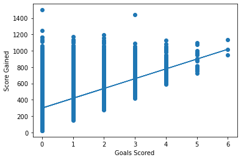

```python
import matplotlib.pyplot as plt
#Making a scatter plot with a line of best fit
plt.scatter(major_table["core_goals"],major_table["core_score"])
m, b = np.polyfit(major_table["core_goals"],major_table["core_score"], 1)
plt.plot(major_table["core_goals"], m*major_table["core_goals"]+b)
plt.xlabel('Goals Scored')
plt.ylabel('Score Gained')
print("slope: " + str(m))
print("intercept: " + str(b))
```

```
slope: 72.30626651825067
intercept: 252.81903195155533
```

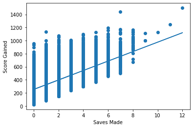

```python
#Making a scatter plot with a line of best fit
plt.scatter(major_table["core_saves"],major_table["core_score"])
m, b = np.polyfit(major_table["core_saves"],major_table["core_score"], 1)
plt.plot(major_table["core_saves"], m*major_table["core_saves"]+b)
plt.xlabel('Saves Made')
plt.ylabel('Score Gained')
print("slope: " + str(m))
print("intercept: " + str(b))
```

#### These results overall make sense. Each goal awards the payer with 100 points, and each save provides 50 points. The slope of these 2 graphs shows that each goal provides 19.935 points extra whereas saves provide 22.286 points extra per save.

#### Boosting is important, in that it keeps your momentum and speed up, so you can move around the field efficently and make plays. Goals and saves directly provide score, but maybe boost can be related with score

```
slope: 0.09693573497714789
intercept: 334.396452051901
```

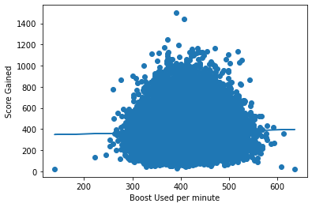

```python
#Making a scatter plot with a line of best fit
plt.scatter(major_table["boost_bpm"],major_table["core_score"])
m, b = np.polyfit(major_table["boost_bpm"],major_table["core_score"], 1)
plt.plot(major_table["boost_bpm"], m*major_table["boost_bpm"]+b)
plt.xlabel('Boost Used per minute')
plt.ylabel('Score Gained')
print("slope: " + str(m))
print("intercept: " + str(b))
#While the slope is positive, there is a low corelation
```

```
slope: 0.541305613720967
intercept: 0.6228461829718419
```

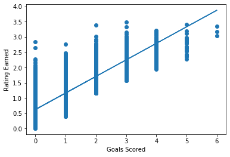

```python
import matplotlib.pyplot as plt
#Making a scatter plot with a line of best fit
plt.scatter(major_table["core_goals"],major_table["advanced_rating"])
m, b = np.polyfit(major_table["core_goals"],major_table["advanced_rating"], 1)
plt.plot(major_table["core_goals"], m*major_table["core_goals"]+b)
plt.xlabel('Goals Scored')
plt.ylabel('Rating Earned')
print("slope: " + str(m))
print("intercept: " + str(b))
```

```
slope: 0.11197635160494013
intercept: 0.7784727106678901
```

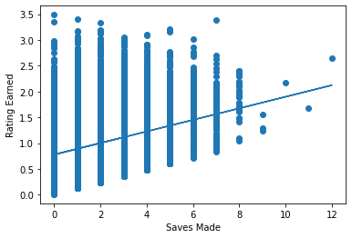

```python
#Making a scatter plot with a line of best fit
plt.scatter(major_table["core_saves"],major_table["advanced_rating"])
m, b = np.polyfit(major_table["core_saves"],major_table["advanced_rating"], 1)
plt.plot(major_table["core_saves"], m*major_table["core_saves"]+b)
plt.xlabel('Saves Made')
plt.ylabel('Rating Earned')
print("slope: " + str(m))
print("intercept: " + str(b))
```

```
slope: 0.0005773634924284364
intercept: 0.7286755617108218
```

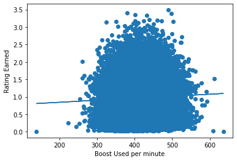

```python
#Making a scatter plot with a line of best fit
plt.scatter(major_table["boost_bpm"],major_table["advanced_rating"])
m, b = np.polyfit(major_table["boost_bpm"],major_table["advanced_rating"], 1)
plt.plot(major_table["boost_bpm"], m*major_table["boost_bpm"]+b)
plt.xlabel('Boost Used per minute')
plt.ylabel('Rating Earned')
print("slope: " + str(m))
print("intercept: " + str(b))
```

# Brief Description of RLCS

#### RLCS has a format of 3 majors and a world Championship. The best teams from 3 majors will be allowed to the world championship. RLCS is a global esport, with regions, North America, Europe, South America, Africa/Middle East, Asia, and Austrialia. It is impossible for people in Europe and Australia to play against each other due to the latency, because the physical distance is so far. A link is provided on why location affects latency. To solve this, RLCS makes it so that for ever major there are 3 regional events. All the teams for each region compete among themselves, the best teams after 3 events will go to the major. Regions such as North America and Europe have more developed teams, and as such have more slots for the major. The major is an in person event, where teams that qualify all meet and play in person. A link is provided on the RLCS format.

#### Latency: https://www.cloudways.com/blog/how-server-location-affects-latency/

#### RLCS Format: https://www.kalb.com/2022/10/07/rocket-league-championship-series-rlcs-2022-23-season-is-here/

# Brief Description of SpaceStation Gaming

#### Something about me personally, is that my favorite team is SpaceStation Gaming. They are among the most popular RLCS teams, due to one of their players, and the vast amount of rocket league creators signed to SpaceStation Gaming. Creators are youtubers, streamers, or anyone that makes rocket league content. SpaceStation Gaming has signed many of these creators, including the second most subscribed rocket league youtuber. On the Pro team for SpaceStation Gaming, there is a player whose name is Arsenal. He is also a youtuber, with 100,000s of subscribers, and has one of the most electric personalities. This combination has gained SpaceStation Gaming the popularity it has today. Unfortunately, recently many of these creators have left to join other organizations. Also a player, retals, who is also a popular player has been kicked from the team.

# Goal

#### In the beginning of RLCS 21-22 season, which this dataframe is based off the roster of SSG(SpaceStation Gaming) was composed of Arsenal, Retals, and Sypical. After SSG barely missed qualifying for the major, Sypical left the team to join Faze. At the time and even now Sypical is considered one of the best players in the world. To replace Sypical, SSG added Daniel, who had just turned old enough to play in RLCS, there is a age minimum of 16. Since joining, Daniel has proven to be one of the best players in the world also. However after 2 majors where SSG made it very far, semi-finals and quarter-finals, then losing before making playoffs, SSG made a change by dropping Retals. Retals played very well, however not worthy of best in the world like Daniel or Sypical. The replacement was LJ for oxygen esports and Retals went to join Optic Gaming. A link is provided for details on past and present of SSG, Faze, Optic, and Oxygen.

#### SSG Team: https://liquipedia.net/rocketleague/Spacestation_Gaming

#### Faze Team: https://liquipedia.net/rocketleague/FaZe_Clan

#### Optic Team: https://liquipedia.net/rocketleague/OpTic_Gaming

#### Oxygen Team: https://liquipedia.net/rocketleague/Oxygen_Esports

#### Note: By going to the team's link you can click on a player or coach's name to get more in depth stats on them personally.

#### SSG has made a plethora of roster changes, dropping one of the best in the world, getting arguably a better player somehow, with players joining and leaving.

#### I want to know if SSG made the right decision:

#### Should SSG have let Sypical leave?

#### Did Sypical make the right decision by leaving to join Faze, instead of staying and playing with Daniel?

#### Should SSG have signed daniel?

#### How similar are Sypical and Daniel in performace?

#### Should SSG have dropped Retals?

#### Was LJ the best choice to replace retals?

#### For the next parts, I first isolate each player's games in their own dataframe. This way I can compare summary statistics and use them to make hypotheses based on them. I also plot out "main" metrics next to each other for each player. This helps visualize players performance based on these metrics for different periods

```python
Arsenal = major_table[major_table.player_tag == "Arsenal"]
Retals = major_table[major_table.player_tag == "retals"]
Sypical = major_table[major_table.player_tag == "Sypical"]
```

#### One thing to consider before going into these graphs is that Sypical left January 11 2022, so the area on the left is when Sypical was still on the team and to the right of the the gap in Dec 2021 to Jan 2021, is when Sypical is no longer with SSG.

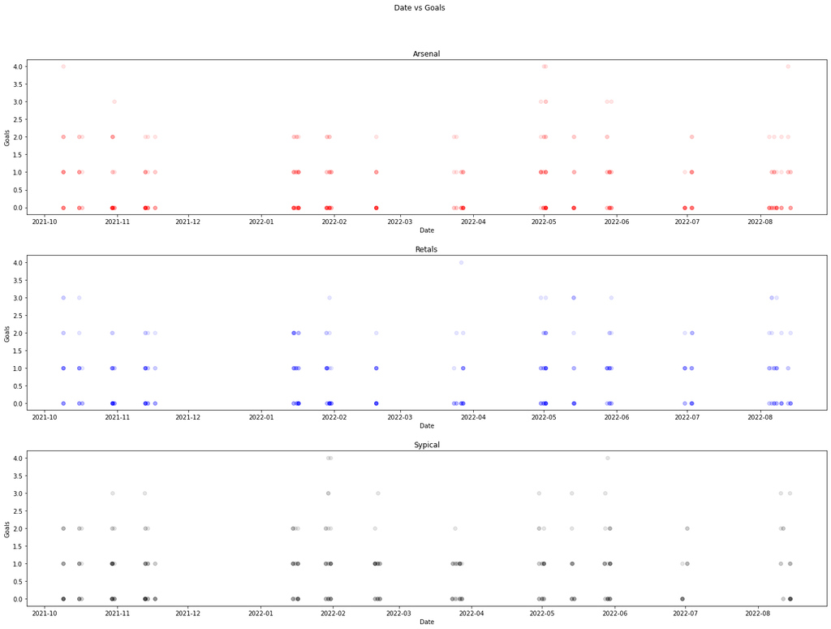

```python
fig, axs = plt.subplots(3,figsize=(20, 15))
fig.suptitle('Date vs Goals')
axs[0].scatter(Arsenal["date"],Arsenal["core_goals"], color = '#FF0000', alpha=0.1)
axs[1].scatter(Retals["date"],Retals["core_goals"], color = '#0000FF', alpha=0.1)
axs[2].scatter(Sypical["date"],Sypical["core_goals"], color = '#000000', alpha=0.1)
fig.tight_layout(pad=5.0)
axs[0].set_title('Arsenal')
axs[1].set_title('Retals')
axs[2].set_title('Sypical')
for ax in axs.flat:
    ax.set(xlabel='Date', ylabel='Goals')
```

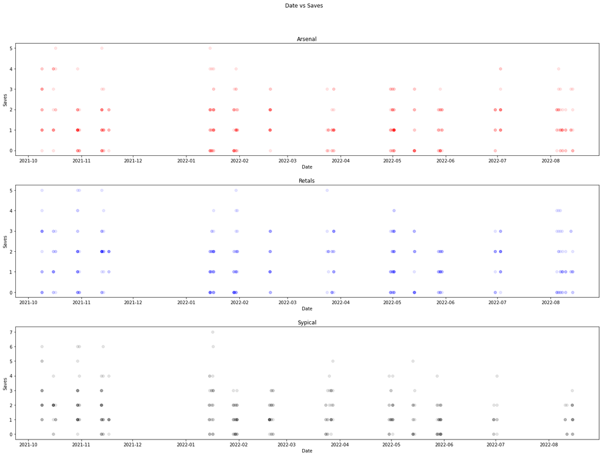

```python
fig, axs = plt.subplots(3,figsize=(20, 15))
fig.suptitle('Date vs Saves')
axs[0].scatter(Arsenal["date"],Arsenal["core_saves"], color = '#FF0000' ,alpha=0.1)
axs[1].scatter(Retals["date"],Retals["core_saves"], color = '#0000FF' ,alpha=0.1)
axs[2].scatter(Sypical["date"],Sypical["core_saves"], color = '#000000' ,alpha=0.1)
fig.tight_layout(pad=5.0)
axs[0].set_title('Arsenal')
axs[1].set_title('Retals')
axs[2].set_title('Sypical')
for ax in axs.flat:
    ax.set(xlabel='Date', ylabel='Saves')
```

#### Something to note is Sypical's role as a player. He is a 3rd man, which means that he is usually the last person in an attack. In an attack a player commits themselves to scoring the ball, if the fail they will need some time to recover and get boost before being able to defend. By being 3rd man, Sypical has to defend by himself and buy time for his teammates to support him.

#### When Sypical was still on the team, his saves were very high, having to get games with 6 games, but usually was around the 2 to 3 range. On the other hand Arsenal are planted around the 1 to 2 range for saves during this period.

#### Since Sypical left, Arsenal and Retals have not seen a significant bump to saves, sill hovering around the 1 to 2 range. However Sypical seems to have his role as 3rd man reduced, based on the downward trend of his frequency of saves.

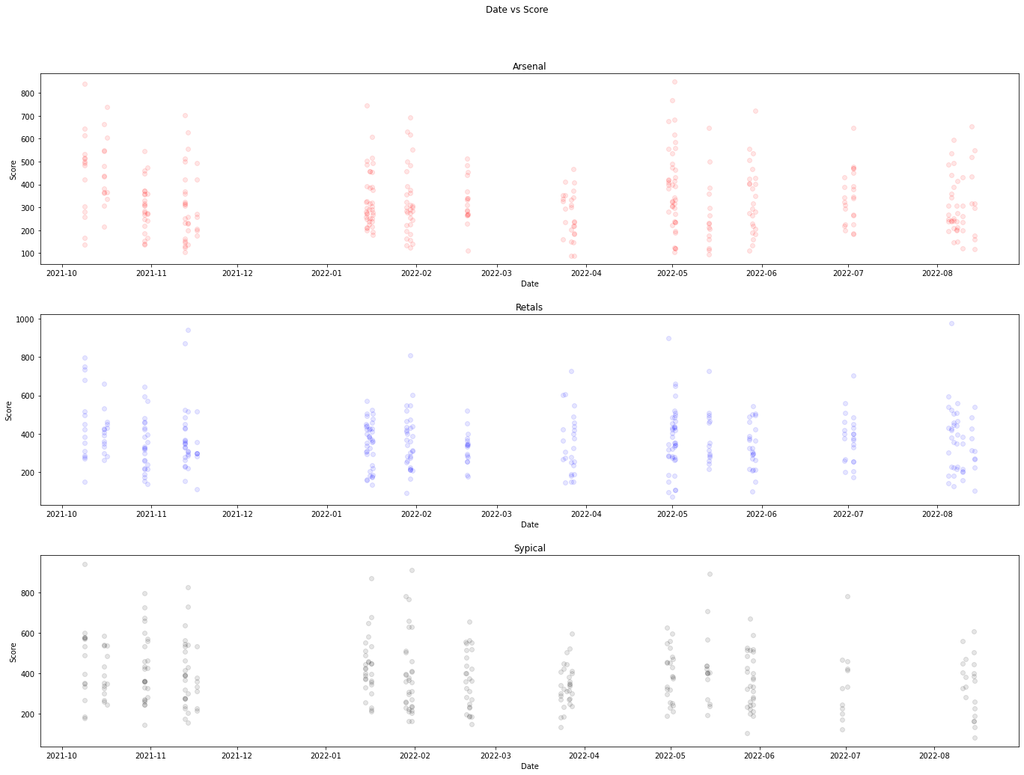

```python
fig, axs = plt.subplots(3,figsize=(20, 15))
fig.suptitle('Date vs Score')
axs[0].scatter(Arsenal["date"],Arsenal["core_score"], color = '#FF0000' ,alpha=0.1)
axs[1].scatter(Retals["date"],Retals["core_score"], color = '#0000FF' ,alpha=0.1)
axs[2].scatter(Sypical["date"],Sypical["core_score"], color = '#000000' ,alpha=0.1)
fig.tight_layout(pad=5.0)
axs[0].set_title('Arsenal')
axs[1].set_title('Retals')
axs[2].set_title('Sypical')
for ax in axs.flat:
    ax.set(xlabel='Date', ylabel='Score')
```

#### Score does not seem to provide any obvious insights and seems to be pretty scattered.

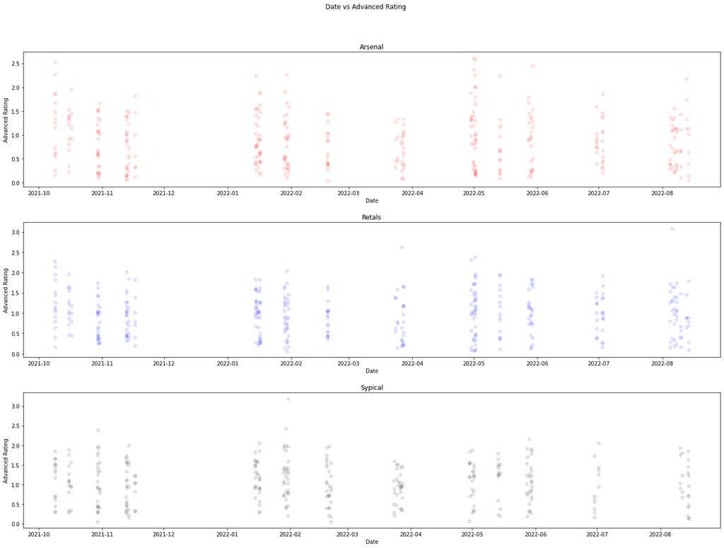

```python
fig, axs = plt.subplots(3,figsize=(20, 15))
fig.suptitle('Date vs Advanced Rating')
axs[0].scatter(Arsenal["date"],Arsenal["advanced_rating"], color = '#FF0000' ,alpha=0.1)
axs[1].scatter(Retals["date"],Retals["advanced_rating"], color = '#0000FF' ,alpha=0.1)
axs[2].scatter(Sypical["date"],Sypical["advanced_rating"], color = '#000000' ,alpha=0.1)
fig.tight_layout(pad=5.0)
axs[0].set_title('Arsenal')
axs[1].set_title('Retals')
axs[2].set_title('Sypical')
for ax in axs.flat:
    ax.set(xlabel='Date', ylabel='Advanced Rating')
```

#### For Sypical, before leaving, much of his score is clustered between 0 and 1, with some between 1 and 2. From the describe above for advanced_rating, we know that the median is around .95, mean around .96, and a 75% of around 1.34. This means his performance was lower than the average player's. However after leaving, there are more clusters in in the 1 to 2 range, which shows he's performing like a world class player again. For Arsenal and Retals, before Sypical left, they had performances in the upper 0 to lower 1 range however after Sypical left they are performing worse, with many clusters in the 0 to 1 area, and only a few close to the 1 mark. Retals does have on average a cluster closer to 1 than Arsenal.

```python
import datetime
#This when Sypical was still with SSG
leave = datetime.datetime(2022, 1, 11)
with pd.option_context('display.max_rows', None, 'display.max_columns', None):  # more options can be specified also
    display(Sypical[Sypical.date < leave].describe())
```

|  | game | core_shots | core_goals | core_saves | core_assists | core_score | core_shooting_percentage | boost_bpm | boost_bcpm | boost_avg_amount | boost_amount_collected | boost_amount_stolen | boost_amount_collected_big | boost_amount_stolen_big | boost_amount_collected_small | boost_amount_stolen_small | boost_count_collected_big | boost_count_stolen_big | boost_count_collected_small | boost_count_stolen_small | boost_amount_overfill | boost_amount_overfill_stolen | boost_amount_used_while_supersonic | boost_time_zero_boost | boost_percent_zero_boost | boost_time_full_boost | boost_percent_full_boost | boost_time_boost_0_25 | boost_time_boost_25_50 | … |
| --- | --- | --- | --- | --- | --- | --- | --- | --- | --- | --- | --- | --- | --- | --- | --- | --- | --- | --- | --- | --- | --- | --- | --- | --- | --- | --- | --- | --- | --- | --- |
| count | 88.000000 | 88.000000 | 88.000000 | 88.000000 | 88.000000 | 88.000000 | 88.000000 | 88.000000 | 88.000000 | 88.000000 | 88.000000 | 88.000000 | 88.000000 | 88.000000 | 88.000000 | 88.000000 | 88.000000 | 88.000000 | 88.000000 | 88.000000 | 88.000000 | 88.000000 | 88.000000 | 88.000000 | 88.000000 | 88.000000 | 88.000000 | 88.000000 | 88.000000 | … |
| mean | 749.204545 | 3.113636 | 0.670455 | 2.022727 | 0.454545 | 414.238636 | 21.558442 | 437.397727 | 439.422021 | 48.042500 | 2656.590909 | 518.193182 | 1866.795455 | 330.920455 | 789.795455 | 187.272727 | 22.659091 | 3.727273 | 68.590909 | 15.806818 | 405.602273 | 40.602273 | 453.965909 | 50.694659 | 14.087426 | 34.981477 | 9.493459 | 130.242386 | 77.644773 | … |
| std | 577.199724 | 1.677654 | 0.798297 | 1.469829 | 0.676521 | 162.961316 | 28.532630 | 35.789788 | 37.908922 | 3.511792 | 701.676459 | 262.983582 | 526.777825 | 208.626941 | 231.646588 | 93.279549 | 6.775355 | 2.327878 | 18.663774 | 6.793942 | 197.823243 | 44.419510 | 157.961762 | 15.990449 | 3.339281 | 15.094626 | 2.535370 | 35.281532 | 23.245802 | … |
| min | 0.000000 | 0.000000 | 0.000000 | 0.000000 | 0.000000 | 144.000000 | 0.000000 | 336.000000 | 354.642640 | 38.230000 | 1653.000000 | 94.000000 | 1137.000000 | 0.000000 | 515.000000 | 48.000000 | 12.000000 | 0.000000 | 45.000000 | 4.000000 | 87.000000 | 0.000000 | 242.000000 | 19.290000 | 5.709973 | 15.530000 | 4.746042 | 84.440000 | 37.150000 | … |
| 25% | 114.750000 | 2.000000 | 0.000000 | 1.000000 | 0.000000 | 281.000000 | 0.000000 | 415.250000 | 410.813145 | 45.897500 | 2271.500000 | 345.750000 | 1543.000000 | 193.750000 | 663.250000 | 130.000000 | 19.000000 | 2.000000 | 58.750000 | 11.000000 | 269.750000 | 3.750000 | 352.250000 | 41.600000 | 12.053839 | 25.707500 | 7.840495 | 109.430000 | 62.855000 | … |
| 50% | 727.500000 | 3.000000 | 0.000000 | 2.000000 | 0.000000 | 382.000000 | 0.000000 | 439.000000 | 441.973725 | 48.285000 | 2506.500000 | 479.500000 | 1796.500000 | 300.000000 | 735.000000 | 177.000000 | 21.500000 | 3.000000 | 64.000000 | 15.000000 | 380.500000 | 33.000000 | 415.500000 | 48.485000 | 13.874497 | 30.825000 | 9.342795 | 120.345000 | 73.010000 | … |
| 75% | 1311.250000 | 4.000000 | 1.000000 | 3.000000 | 1.000000 | 537.250000 | 33.333333 | 463.500000 | 466.388802 | 50.377500 | 2724.250000 | 668.500000 | 2003.500000 | 468.500000 | 856.250000 | 209.250000 | 24.250000 | 5.000000 | 73.000000 | 18.000000 | 507.750000 | 54.750000 | 507.750000 | 57.027500 | 15.758388 | 41.605000 | 10.921522 | 141.655000 | 84.847500 | … |
| max | 1741.000000 | 7.000000 | 3.000000 | 6.000000 | 3.000000 | 940.000000 | 100.000000 | 511.000000 | 520.285030 | 56.520000 | 6395.000000 | 1638.000000 | 4379.000000 | 884.000000 | 2016.000000 | 774.000000 | 54.000000 | 10.000000 | 155.000000 | 53.000000 | 1182.000000 | 212.000000 | 1068.000000 | 130.520000 | 22.680650 | 97.470000 | 14.606411 | 297.930000 | 193.350000 | … |

```python
#This after Sypical left SSG to go to Faze
leave = datetime.datetime(2022, 1, 11)
with pd.option_context('display.max_rows', None, 'display.max_columns', None):  # more options can be specified also
    display(Sypical[Sypical.date > leave].describe())
```

|  | game | core_shots | core_goals | core_saves | core_assists | core_score | core_shooting_percentage | boost_bpm | boost_bcpm | boost_avg_amount | boost_amount_collected | boost_amount_stolen | boost_amount_collected_big | boost_amount_stolen_big | boost_amount_collected_small | boost_amount_stolen_small | boost_count_collected_big | boost_count_stolen_big | boost_count_collected_small | boost_count_stolen_small | boost_amount_overfill | boost_amount_overfill_stolen | boost_amount_used_while_supersonic | boost_time_zero_boost | boost_percent_zero_boost | boost_time_full_boost | boost_percent_full_boost | boost_time_boost_0_25 | boost_time_boost_25_50 | … |
| --- | --- | --- | --- | --- | --- | --- | --- | --- | --- | --- | --- | --- | --- | --- | --- | --- | --- | --- | --- | --- | --- | --- | --- | --- | --- | --- | --- | --- | --- | --- |
| count | 219.000000 | 219.000000 | 219.000000 | 219.000000 | 219.000000 | 219.000000 | 219.000000 | 219.000000 | 219.000000 | 219.000000 | 219.000000 | 219.000000 | 219.000000 | 219.000000 | 219.000000 | 219.000000 | 219.000000 | 219.000000 | 219.000000 | 219.000000 | 219.000000 | 219.000000 | 219.000000 | 219.000000 | 219.000000 | 219.000000 | 219.000000 | 219.000000 | 219.000000 | … |
| mean | 3911.977169 | 2.972603 | 0.780822 | 1.365297 | 0.739726 | 376.799087 | 25.026093 | 440.461187 | 442.999685 | 45.202237 | 2641.452055 | 592.168950 | 1830.694064 | 356.260274 | 810.757991 | 235.908676 | 21.095890 | 4.009132 | 70.159817 | 20.251142 | 280.438356 | 43.913242 | 438.525114 | 57.676393 | 16.166095 | 25.533196 | 7.141322 | 141.326027 | 80.808767 | … |
| std | 1186.471855 | 1.866945 | 0.881719 | 1.235515 | 0.867783 | 151.085387 | 28.763034 | 34.673075 | 38.923001 | 3.739133 | 609.014485 | 251.637379 | 442.307080 | 190.243279 | 222.511026 | 101.734593 | 5.327351 | 2.098472 | 18.711892 | 8.372954 | 131.420118 | 43.141401 | 159.586315 | 15.936766 | 3.372175 | 8.462088 | 1.902488 | 34.580067 | 21.861370 | … |
| min | 2067.000000 | 0.000000 | 0.000000 | 0.000000 | 0.000000 | 80.000000 | 0.000000 | 302.000000 | 302.093800 | 35.390000 | 1652.000000 | 96.000000 | 1017.000000 | 0.000000 | 434.000000 | 61.000000 | 11.000000 | 0.000000 | 42.000000 | 6.000000 | 66.000000 | 0.000000 | 140.000000 | 30.700000 | 9.457441 | 9.920000 | 3.050056 | 83.470000 | 40.230000 | … |
| 25% | 2766.500000 | 2.000000 | 0.000000 | 0.000000 | 0.000000 | 256.000000 | 0.000000 | 417.000000 | 421.631505 | 42.820000 | 2364.000000 | 418.000000 | 1617.000000 | 200.000000 | 699.500000 | 173.000000 | 18.000000 | 3.000000 | 61.000000 | 15.000000 | 185.500000 | 8.000000 | 348.500000 | 47.350000 | 13.850774 | 19.670000 | 5.853225 | 118.950000 | 66.240000 | … |
| 50% | 3852.000000 | 3.000000 | 1.000000 | 1.000000 | 1.000000 | 368.000000 | 20.000000 | 444.000000 | 447.014920 | 45.370000 | 2533.000000 | 567.000000 | 1792.000000 | 334.000000 | 777.000000 | 225.000000 | 21.000000 | 4.000000 | 67.000000 | 20.000000 | 252.000000 | 30.000000 | 422.000000 | 56.440000 | 15.861350 | 23.800000 | 6.870722 | 137.090000 | 79.290000 | … |
| 75% | 5112.500000 | 4.000000 | 1.000000 | 2.000000 | 1.000000 | 456.000000 | 50.000000 | 465.000000 | 467.330110 | 47.675000 | 2772.000000 | 722.000000 | 1978.000000 | 464.000000 | 865.500000 | 277.000000 | 23.000000 | 5.000000 | 74.000000 | 24.000000 | 346.500000 | 67.500000 | 509.000000 | 65.175000 | 18.360965 | 30.140000 | 8.496096 | 153.980000 | 90.690000 | … |
| max | 5828.000000 | 13.000000 | 4.000000 | 7.000000 | 4.000000 | 909.000000 | 133.333333 | 525.000000 | 533.925300 | 55.840000 | 8659.000000 | 2533.000000 | 5749.000000 | 1405.000000 | 2910.000000 | 1128.000000 | 68.000000 | 16.000000 | 248.000000 | 91.000000 | 1094.000000 | 210.000000 | 1970.000000 | 174.100000 | 28.176552 | 78.180000 | 12.816857 | 412.100000 | 244.120000 | … |

#### Sypical's mean goals increased, as did his assists and shooting percentage. However his saves per game decreased, due to a new role. Overall this has lead to around the same advance_rating, as when he left.

```python
leave = datetime.datetime(2022, 1, 11)
with pd.option_context('display.max_rows', None, 'display.max_columns', None):  # more options can be specified also
    display(Arsenal[Arsenal.date < leave].describe())
```

|  | game | core_shots | core_goals | core_saves | core_assists | core_score | core_shooting_percentage | boost_bpm | boost_bcpm | boost_avg_amount | boost_amount_collected | boost_amount_stolen | boost_amount_collected_big | boost_amount_stolen_big | boost_amount_collected_small | boost_amount_stolen_small | boost_count_collected_big | boost_count_stolen_big | boost_count_collected_small | boost_count_stolen_small | boost_amount_overfill | boost_amount_overfill_stolen | boost_amount_used_while_supersonic | boost_time_zero_boost | boost_percent_zero_boost | boost_time_full_boost | boost_percent_full_boost | boost_time_boost_0_25 | boost_time_boost_25_50 | … |
| --- | --- | --- | --- | --- | --- | --- | --- | --- | --- | --- | --- | --- | --- | --- | --- | --- | --- | --- | --- | --- | --- | --- | --- | --- | --- | --- | --- | --- | --- | --- |
| count | 88.000000 | 88.000000 | 88.000000 | 88.000000 | 88.000000 | 88.000000 | 88.000000 | 88.000000 | 88.000000 | 88.000000 | 88.000000 | 88.000000 | 88.000000 | 88.000000 | 88.000000 | 88.000000 | 88.000000 | 88.000000 | 88.000000 | 88.000000 | 88.000000 | 88.000000 | 88.000000 | 88.000000 | 88.000000 | 88.000000 | 88.000000 | 88.000000 | 88.000000 | … |
| mean | 749.204545 | 2.420455 | 0.602273 | 1.522727 | 0.488636 | 353.170455 | 21.601732 | 427.795455 | 443.379267 | 48.845341 | 2688.511364 | 619.602273 | 1880.170455 | 368.295455 | 808.340909 | 251.306818 | 22.795455 | 4.284091 | 69.034091 | 21.090909 | 416.511364 | 63.204545 | 542.431818 | 50.888409 | 13.964630 | 52.427614 | 14.469828 | 136.858977 | 76.710227 | … |
| std | 577.199724 | 1.665896 | 0.864893 | 1.250078 | 0.677967 | 160.517570 | 35.069025 | 37.600183 | 42.786675 | 3.663955 | 717.337654 | 248.871870 | 514.043565 | 204.668342 | 252.240621 | 94.653070 | 6.359280 | 2.353520 | 21.644170 | 7.640841 | 196.419267 | 54.064916 | 217.636721 | 19.625727 | 3.617577 | 16.226785 | 3.320358 | 43.281758 | 24.174055 | … |
| min | 0.000000 | 0.000000 | 0.000000 | 0.000000 | 0.000000 | 104.000000 | 0.000000 | 352.000000 | 351.968050 | 37.700000 | 1851.000000 | 187.000000 | 1207.000000 | 0.000000 | 493.000000 | 83.000000 | 14.000000 | 0.000000 | 46.000000 | 7.000000 | 112.000000 | 0.000000 | 249.000000 | 21.470000 | 6.488365 | 21.740000 | 6.667893 | 69.450000 | 40.330000 | … |
| 25% | 114.750000 | 1.000000 | 0.000000 | 1.000000 | 0.000000 | 231.750000 | 0.000000 | 400.000000 | 409.525247 | 46.445000 | 2320.750000 | 408.750000 | 1600.750000 | 200.000000 | 663.750000 | 189.000000 | 19.000000 | 2.000000 | 57.000000 | 16.000000 | 286.500000 | 18.750000 | 391.000000 | 40.892500 | 11.770753 | 42.560000 | 12.407739 | 109.972500 | 63.510000 | … |
| 50% | 727.500000 | 2.000000 | 0.000000 | 1.000000 | 0.000000 | 320.500000 | 0.000000 | 423.500000 | 443.144220 | 48.895000 | 2494.500000 | 566.000000 | 1772.000000 | 347.500000 | 756.000000 | 230.000000 | 22.000000 | 4.000000 | 64.000000 | 20.000000 | 382.000000 | 55.000000 | 499.500000 | 48.535000 | 13.632576 | 48.220000 | 14.100714 | 128.990000 | 71.710000 | … |
| 75% | 1311.250000 | 4.000000 | 1.000000 | 2.000000 | 1.000000 | 476.500000 | 33.333333 | 452.250000 | 468.520795 | 51.562500 | 2791.000000 | 774.500000 | 1986.000000 | 504.750000 | 867.500000 | 301.750000 | 24.000000 | 6.000000 | 72.500000 | 25.000000 | 504.000000 | 90.000000 | 659.250000 | 57.862500 | 16.608740 | 60.020000 | 16.415199 | 152.192500 | 82.842500 | … |
| max | 1741.000000 | 7.000000 | 4.000000 | 5.000000 | 2.000000 | 838.000000 | 200.000000 | 527.000000 | 570.996700 | 56.440000 | 6448.000000 | 1209.000000 | 4218.000000 | 918.000000 | 2230.000000 | 561.000000 | 50.000000 | 10.000000 | 200.000000 | 50.000000 | 1204.000000 | 280.000000 | 1520.000000 | 164.150000 | 22.500305 | 118.070000 | 24.297445 | 377.290000 | 189.300000 | … |

```python
leave = datetime.datetime(2022, 1, 11)
with pd.option_context('display.max_rows', None, 'display.max_columns', None):  # more options can be specified also
    display(Arsenal[Arsenal.date > leave].describe())
```

|  | game | core_shots | core_goals | core_saves | core_assists | core_score | core_shooting_percentage | boost_bpm | boost_bcpm | boost_avg_amount | boost_amount_collected | boost_amount_stolen | boost_amount_collected_big | boost_amount_stolen_big | boost_amount_collected_small | boost_amount_stolen_small | boost_count_collected_big | boost_count_stolen_big | boost_count_collected_small | boost_count_stolen_small | boost_amount_overfill | boost_amount_overfill_stolen | boost_amount_used_while_supersonic | boost_time_zero_boost | boost_percent_zero_boost | boost_time_full_boost | boost_percent_full_boost | boost_time_boost_0_25 | boost_time_boost_25_50 | … |
| --- | --- | --- | --- | --- | --- | --- | --- | --- | --- | --- | --- | --- | --- | --- | --- | --- | --- | --- | --- | --- | --- | --- | --- | --- | --- | --- | --- | --- | --- | --- |
| count | 261.000000 | 261.000000 | 261.000000 | 261.000000 | 261.000000 | 261.000000 | 261.000000 | 261.000000 | 261.000000 | 261.000000 | 261.000000 | 261.000000 | 261.000000 | 261.000000 | 261.000000 | 261.000000 | 261.000000 | 261.000000 | 261.000000 | 261.000000 | 261.000000 | 261.000000 | 261.000000 | 261.000000 | 261.000000 | 261.000000 | 261.000000 | 261.000000 | 261.000000 | … |
| mean | 4077.620690 | 2.800766 | 0.586207 | 1.275862 | 0.463602 | 327.241379 | 20.252691 | 442.858238 | 457.658823 | 49.377586 | 2703.049808 | 663.750958 | 1941.544061 | 408.777778 | 761.505747 | 254.973180 | 23.383142 | 4.800766 | 66.126437 | 22.011494 | 413.298851 | 73.310345 | 536.862069 | 51.582184 | 14.599327 | 47.974176 | 13.473384 | 131.805364 | 69.914943 | … |
| std | 1251.847314 | 1.607243 | 0.839666 | 1.052722 | 0.681921 | 141.326297 | 31.529529 | 40.776396 | 44.982302 | 4.082632 | 565.896465 | 242.090803 | 443.128696 | 197.990162 | 182.188926 | 88.521245 | 5.662863 | 2.366139 | 15.537402 | 7.175537 | 184.617449 | 62.574505 | 184.013827 | 15.497206 | 3.710347 | 16.444880 | 3.524306 | 31.523720 | 17.360640 | … |
| min | 2071.000000 | 0.000000 | 0.000000 | 0.000000 | 0.000000 | 90.000000 | 0.000000 | 336.000000 | 334.018160 | 37.360000 | 1829.000000 | 108.000000 | 1088.000000 | 0.000000 | 376.000000 | 84.000000 | 13.000000 | 0.000000 | 33.000000 | 7.000000 | 77.000000 | 0.000000 | 158.000000 | 20.580000 | 6.237309 | 21.130000 | 6.310198 | 72.400000 | 36.240000 | … |
| 25% | 2760.000000 | 2.000000 | 0.000000 | 0.000000 | 0.000000 | 227.000000 | 0.000000 | 419.000000 | 426.866150 | 46.660000 | 2355.000000 | 498.000000 | 1637.000000 | 277.000000 | 656.000000 | 191.000000 | 20.000000 | 3.000000 | 57.000000 | 17.000000 | 275.000000 | 26.000000 | 402.000000 | 40.740000 | 11.810337 | 37.010000 | 10.924906 | 110.460000 | 58.920000 | … |
| 50% | 4127.000000 | 3.000000 | 0.000000 | 1.000000 | 0.000000 | 302.000000 | 0.000000 | 441.000000 | 458.852050 | 49.450000 | 2613.000000 | 656.000000 | 1888.000000 | 400.000000 | 733.000000 | 241.000000 | 23.000000 | 5.000000 | 63.000000 | 21.000000 | 385.000000 | 63.000000 | 507.000000 | 49.660000 | 14.727759 | 44.300000 | 13.087928 | 127.920000 | 69.020000 | … |
| 75% | 5485.000000 | 4.000000 | 1.000000 | 2.000000 | 1.000000 | 408.000000 | 33.333333 | 470.000000 | 490.067800 | 52.210000 | 2825.000000 | 826.000000 | 2107.000000 | 545.000000 | 823.000000 | 303.000000 | 26.000000 | 6.000000 | 71.000000 | 25.000000 | 523.000000 | 104.000000 | 623.000000 | 59.170000 | 17.058947 | 54.670000 | 15.389239 | 146.190000 | 78.620000 | … |
| max | 5738.000000 | 8.000000 | 4.000000 | 5.000000 | 3.000000 | 848.000000 | 200.000000 | 554.000000 | 577.154660 | 60.350000 | 5976.000000 | 2007.000000 | 4437.000000 | 1411.000000 | 1564.000000 | 632.000000 | 55.000000 | 19.000000 | 144.000000 | 52.000000 | 1336.000000 | 514.000000 | 1393.000000 | 114.140000 | 26.659273 | 135.170000 | 28.196375 | 275.770000 | 138.080000 | … |

#### The mean and median shots for Arsenal increased, however his mean slightly decreased in goals. This lead to a lower shooting percentage, his saves also decreased. Overall this caused his advanced_rating to fall. Some context is that in 2020, Arsenal was considered one of the top 5 players in the world, seeing his performance get worse and no longer be considered among the top is quite sad for SSG fans.

```python
leave = datetime.datetime(2022, 1, 11)
with pd.option_context('display.max_rows', None, 'display.max_columns', None):  # more options can be specified also
    display(Retals[Retals.date < leave].describe())
```

|  | game | core_shots | core_goals | core_saves | core_assists | core_score | core_shooting_percentage | boost_bpm | boost_bcpm | boost_avg_amount | boost_amount_collected | boost_amount_stolen | boost_amount_collected_big | boost_amount_stolen_big | boost_amount_collected_small | boost_amount_stolen_small | boost_count_collected_big | boost_count_stolen_big | boost_count_collected_small | boost_count_stolen_small | boost_amount_overfill | boost_amount_overfill_stolen | boost_amount_used_while_supersonic | boost_time_zero_boost | boost_percent_zero_boost | boost_time_full_boost | boost_percent_full_boost | boost_time_boost_0_25 | boost_time_boost_25_50 | … |
| --- | --- | --- | --- | --- | --- | --- | --- | --- | --- | --- | --- | --- | --- | --- | --- | --- | --- | --- | --- | --- | --- | --- | --- | --- | --- | --- | --- | --- | --- | --- |
| count | 88.000000 | 88.000000 | 88.000000 | 88.000000 | 88.000000 | 88.000000 | 88.000000 | 88.000000 | 88.000000 | 88.000000 | 88.000000 | 88.000000 | 88.000000 | 88.000000 | 88.000000 | 88.000000 | 88.000000 | 88.000000 | 88.000000 | 88.000000 | 88.000000 | 88.000000 | 88.000000 | 88.000000 | 88.000000 | 88.000000 | 88.000000 | 88.000000 | 88.000000 | … |
| mean | 749.204545 | 2.772727 | 0.659091 | 1.772727 | 0.431818 | 382.886364 | 24.661797 | 409.818182 | 418.468382 | 48.849773 | 2544.943182 | 651.090909 | 1842.340909 | 415.693182 | 702.602273 | 235.397727 | 22.431818 | 4.897727 | 60.113636 | 20.352273 | 401.886364 | 72.011364 | 446.363636 | 45.097727 | 12.441921 | 40.032159 | 11.020605 | 127.827841 | 78.171932 | … |
| std | 577.199724 | 1.811377 | 0.800666 | 1.319415 | 0.583203 | 160.088297 | 31.987669 | 35.779190 | 39.573255 | 3.355285 | 702.427537 | 282.476350 | 508.134223 | 226.936943 | 256.141912 | 94.825859 | 6.365849 | 2.674012 | 20.675062 | 7.775647 | 177.577468 | 59.110357 | 179.270564 | 16.656882 | 3.393837 | 13.972283 | 2.838469 | 36.829706 | 22.085688 | … |
| min | 0.000000 | 0.000000 | 0.000000 | 0.000000 | 0.000000 | 114.000000 | 0.000000 | 324.000000 | 334.941680 | 42.050000 | 1797.000000 | 206.000000 | 914.000000 | 77.000000 | 378.000000 | 49.000000 | 12.000000 | 1.000000 | 32.000000 | 5.000000 | 76.000000 | 0.000000 | 166.000000 | 14.530000 | 4.391055 | 17.890000 | 5.458762 | 73.730000 | 41.330000 | … |
| 25% | 114.750000 | 1.000000 | 0.000000 | 1.000000 | 0.000000 | 282.000000 | 0.000000 | 386.500000 | 392.665855 | 46.290000 | 2128.250000 | 453.500000 | 1515.750000 | 243.000000 | 584.500000 | 175.500000 | 19.000000 | 3.000000 | 49.000000 | 16.000000 | 296.750000 | 24.750000 | 324.500000 | 34.572500 | 10.265752 | 30.795000 | 8.766915 | 107.335000 | 65.475000 | … |
| 50% | 727.500000 | 2.000000 | 0.000000 | 2.000000 | 0.000000 | 352.000000 | 0.000000 | 408.500000 | 416.806000 | 48.740000 | 2370.000000 | 608.000000 | 1759.000000 | 396.500000 | 633.000000 | 214.500000 | 21.000000 | 4.500000 | 56.000000 | 19.000000 | 359.500000 | 64.500000 | 407.000000 | 42.300000 | 12.309293 | 38.680000 | 11.332207 | 123.595000 | 72.200000 | … |
| 75% | 1311.250000 | 4.000000 | 1.000000 | 2.250000 | 1.000000 | 450.500000 | 42.500000 | 439.000000 | 441.425162 | 51.330000 | 2625.250000 | 812.750000 | 1996.000000 | 543.750000 | 740.750000 | 287.250000 | 24.000000 | 6.000000 | 62.000000 | 23.250000 | 470.000000 | 103.000000 | 498.500000 | 50.667500 | 14.884774 | 46.375000 | 12.700481 | 138.395000 | 85.320000 | … |
| max | 1741.000000 | 8.000000 | 3.000000 | 5.000000 | 2.000000 | 942.000000 | 100.000000 | 515.000000 | 546.568540 | 56.690000 | 5986.000000 | 1590.000000 | 4317.000000 | 1182.000000 | 1736.000000 | 525.000000 | 54.000000 | 14.000000 | 148.000000 | 44.000000 | 1109.000000 | 300.000000 | 1186.000000 | 130.090000 | 23.408790 | 99.700000 | 19.636150 | 333.160000 | 156.250000 | … |

```python
leave = datetime.datetime(2022, 1, 11)
with pd.option_context('display.max_rows', None, 'display.max_columns', None):  # more options can be specified also
    display(Retals[Retals.date > leave].describe())
```

|  | game | core_shots | core_goals | core_saves | core_assists | core_score | core_shooting_percentage | boost_bpm | boost_bcpm | boost_avg_amount | boost_amount_collected | boost_amount_stolen | boost_amount_collected_big | boost_amount_stolen_big | boost_amount_collected_small | boost_amount_stolen_small | boost_count_collected_big | boost_count_stolen_big | boost_count_collected_small | boost_count_stolen_small | boost_amount_overfill | boost_amount_overfill_stolen | boost_amount_used_while_supersonic | boost_time_zero_boost | boost_percent_zero_boost | boost_time_full_boost | boost_percent_full_boost | boost_time_boost_0_25 | boost_time_boost_25_50 | … |
| --- | --- | --- | --- | --- | --- | --- | --- | --- | --- | --- | --- | --- | --- | --- | --- | --- | --- | --- | --- | --- | --- | --- | --- | --- | --- | --- | --- | --- | --- | --- |
| count | 261.000000 | 261.000000 | 261.000000 | 261.000000 | 261.000000 | 261.000000 | 261.000000 | 261.000000 | 261.000000 | 261.000000 | 261.000000 | 261.000000 | 261.000000 | 261.000000 | 261.000000 | 261.000000 | 261.000000 | 261.000000 | 261.00000 | 261.000000 | 261.000000 | 261.000000 | 261.000000 | 261.000000 | 261.000000 | 261.000000 | 261.000000 | 261.000000 | 261.000000 | … |
| mean | 4077.620690 | 2.888889 | 0.708812 | 1.375479 | 0.505747 | 357.555556 | 23.279511 | 398.582375 | 411.662241 | 49.152069 | 2431.206897 | 628.180077 | 1731.007663 | 387.180077 | 700.199234 | 241.000000 | 21.716475 | 4.704981 | 60.08046 | 20.490421 | 443.187739 | 79.873563 | 462.842912 | 39.922989 | 11.282149 | 45.908467 | 12.916672 | 114.798352 | 79.869923 | … |
| std | 1251.847314 | 1.592987 | 0.859046 | 1.162231 | 0.677215 | 141.171833 | 29.253204 | 34.690803 | 36.576765 | 4.168922 | 499.859899 | 240.881335 | 405.393987 | 200.464312 | 176.869744 | 86.706091 | 5.134731 | 2.406948 | 14.30913 | 6.915764 | 173.558367 | 63.288619 | 174.040497 | 13.302086 | 3.218333 | 15.734544 | 3.562368 | 29.840925 | 19.630531 | … |
| min | 2071.000000 | 0.000000 | 0.000000 | 0.000000 | 0.000000 | 74.000000 | 0.000000 | 270.000000 | 262.834720 | 35.580000 | 1384.000000 | 154.000000 | 988.000000 | 0.000000 | 390.000000 | 76.000000 | 12.000000 | 0.000000 | 34.00000 | 7.000000 | 110.000000 | 0.000000 | 114.000000 | 10.350000 | 3.309881 | 17.460000 | 5.464275 | 53.370000 | 44.360000 | … |
| 25% | 2760.000000 | 2.000000 | 0.000000 | 0.000000 | 0.000000 | 262.000000 | 0.000000 | 376.000000 | 390.669650 | 46.680000 | 2150.000000 | 448.000000 | 1495.000000 | 233.000000 | 585.000000 | 177.000000 | 19.000000 | 3.000000 | 51.00000 | 16.000000 | 318.000000 | 31.000000 | 352.000000 | 30.110000 | 9.103177 | 34.690000 | 10.278963 | 95.980000 | 66.990000 | … |
| 50% | 4127.000000 | 3.000000 | 0.000000 | 1.000000 | 0.000000 | 352.000000 | 0.000000 | 399.000000 | 409.365400 | 49.110000 | 2307.000000 | 608.000000 | 1669.000000 | 372.000000 | 665.000000 | 229.000000 | 21.000000 | 5.000000 | 57.00000 | 20.000000 | 436.000000 | 72.000000 | 429.000000 | 38.640000 | 11.254129 | 42.930000 | 12.591020 | 110.120000 | 76.700000 | … |
| 75% | 5485.000000 | 4.000000 | 1.000000 | 2.000000 | 1.000000 | 442.000000 | 40.000000 | 420.000000 | 433.783660 | 52.340000 | 2543.000000 | 764.000000 | 1880.000000 | 498.000000 | 783.000000 | 289.000000 | 24.000000 | 6.000000 | 66.00000 | 24.000000 | 550.000000 | 113.000000 | 534.000000 | 47.040000 | 13.390470 | 55.270000 | 15.019436 | 130.160000 | 88.320000 | … |
| max | 5738.000000 | 7.000000 | 4.000000 | 5.000000 | 3.000000 | 977.000000 | 100.000000 | 500.000000 | 533.370800 | 59.690000 | 5025.000000 | 1621.000000 | 3645.000000 | 1172.000000 | 1654.000000 | 515.000000 | 47.000000 | 13.000000 | 140.00000 | 47.000000 | 1035.000000 | 383.000000 | 1297.000000 | 91.950000 | 20.059720 | 109.380000 | 24.394775 | 283.030000 | 157.900000 | … |

#### Retals shots has increased slightly, however his goals did also increase in contrast to Arsenal. While his advanced_rating has fallen, it is only slightly and still higher than Arsenal. Also his advanced_rating is still higher than the mean adavnced_rating, while Arsenal is lower.

#### Overall Sypical made a good decision to leave SSG, he has improved in most metrics, where as the rest of SSG overall for Retals and Arsenal have slightly declined. SSG should have tried to keep Sypical with the team and should have dropped Arsenal.

#### Next we will compare Daniel, who replaced Sypical, and Sypical. Overall Daniel is considered to have a very similar playstyle to Sypical, and is also considered one of the top players in the world.

```python
#All of Daniel's games
Daniel = major_table[major_table.player_tag == "Daniel"]
leave = datetime.datetime(2022, 1, 11)
#All of Sypical's games since he has left SSG
#This ensures timeframe is the same
#This does not ensure that the amount of games are the same, because one player could reach more playoffs/finals than the other
Sypical = Sypical[Sypical.date > leave]
```

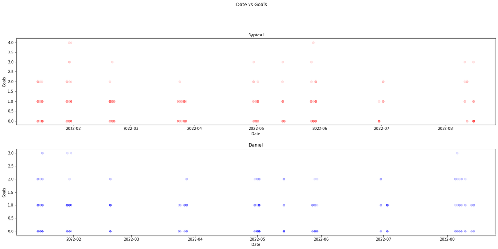

```python
fig, axs = plt.subplots(2,figsize=(20, 10))
fig.suptitle('Date vs Goals')
axs[0].scatter(Sypical["date"],Sypical["core_goals"], color = '#FF0000', alpha=0.1)
axs[1].scatter(Daniel["date"],Daniel["core_goals"], color = '#0000FF', alpha=0.1)
fig.tight_layout(pad=5.0)
axs[0].set_title('Sypical')
axs[1].set_title('Daniel')
for ax in axs.flat:
    ax.set(xlabel='Date', ylabel='Goals')
```

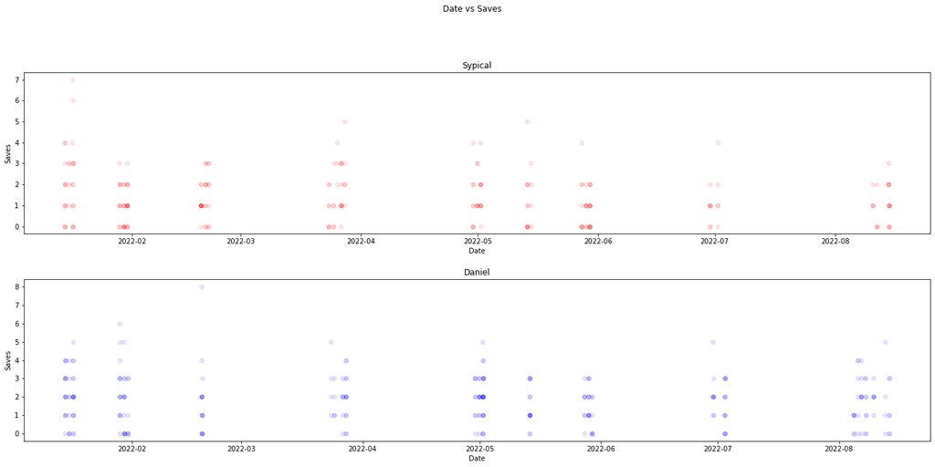

```python
fig, axs = plt.subplots(2,figsize=(20, 10))
fig.suptitle('Date vs Saves')
axs[0].scatter(Sypical["date"],Sypical["core_saves"], color = '#FF0000', alpha=0.1)
axs[1].scatter(Daniel["date"],Daniel["core_saves"], color = '#0000FF', alpha=0.1)
fig.tight_layout(pad=5.0)
axs[0].set_title('Sypical')
axs[1].set_title('Daniel')
for ax in axs.flat:
    ax.set(xlabel='Date', ylabel='Saves')
```

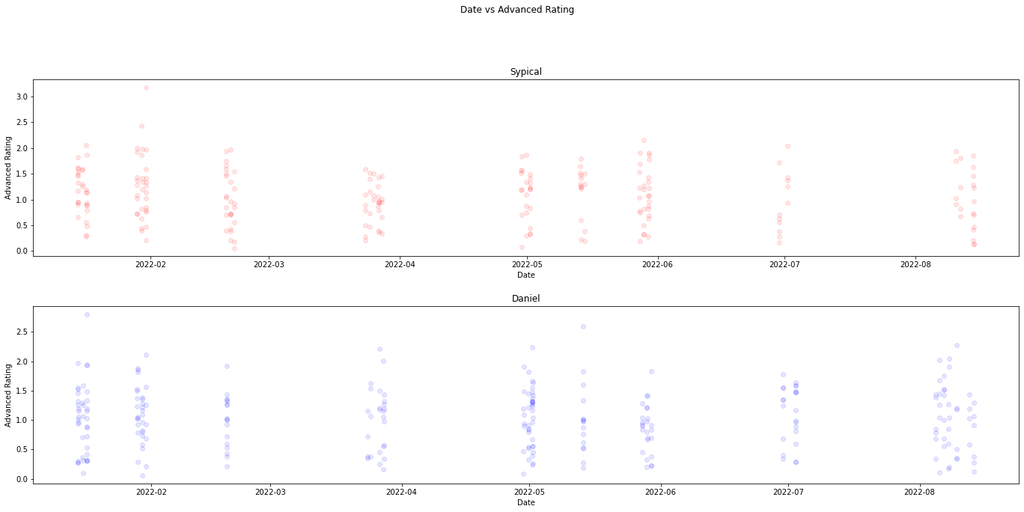

```python
fig, axs = plt.subplots(2,figsize=(20, 10))
fig.suptitle('Date vs Advanced Rating')
axs[0].scatter(Sypical["date"],Sypical["advanced_rating"], color = '#FF0000', alpha=0.1)
axs[1].scatter(Daniel["date"],Daniel["advanced_rating"], color = '#0000FF', alpha=0.1)
fig.tight_layout(pad=5.0)
axs[0].set_title('Sypical')
axs[1].set_title('Daniel')
for ax in axs.flat:
    ax.set(xlabel='Date', ylabel='Advanced Rating')
```

```python
with pd.option_context('display.max_rows', None, 'display.max_columns', None):
    display(Sypical.describe())
```

|  | game | core_shots | core_goals | core_saves | core_assists | core_score | core_shooting_percentage | boost_bpm | boost_bcpm | boost_avg_amount | boost_amount_collected | boost_amount_stolen | boost_amount_collected_big | boost_amount_stolen_big | boost_amount_collected_small | boost_amount_stolen_small | boost_count_collected_big | boost_count_stolen_big | boost_count_collected_small | boost_count_stolen_small | boost_amount_overfill | boost_amount_overfill_stolen | boost_amount_used_while_supersonic | boost_time_zero_boost | boost_percent_zero_boost | boost_time_full_boost | boost_percent_full_boost | boost_time_boost_0_25 | boost_time_boost_25_50 | … |
| --- | --- | --- | --- | --- | --- | --- | --- | --- | --- | --- | --- | --- | --- | --- | --- | --- | --- | --- | --- | --- | --- | --- | --- | --- | --- | --- | --- | --- | --- | --- |
| count | 219.000000 | 219.000000 | 219.000000 | 219.000000 | 219.000000 | 219.000000 | 219.000000 | 219.000000 | 219.000000 | 219.000000 | 219.000000 | 219.000000 | 219.000000 | 219.000000 | 219.000000 | 219.000000 | 219.000000 | 219.000000 | 219.000000 | 219.000000 | 219.000000 | 219.000000 | 219.000000 | 219.000000 | 219.000000 | 219.000000 | 219.000000 | 219.000000 | 219.000000 | … |
| mean | 3911.977169 | 2.972603 | 0.780822 | 1.365297 | 0.739726 | 376.799087 | 25.026093 | 440.461187 | 442.999685 | 45.202237 | 2641.452055 | 592.168950 | 1830.694064 | 356.260274 | 810.757991 | 235.908676 | 21.095890 | 4.009132 | 70.159817 | 20.251142 | 280.438356 | 43.913242 | 438.525114 | 57.676393 | 16.166095 | 25.533196 | 7.141322 | 141.326027 | 80.808767 | … |
| std | 1186.471855 | 1.866945 | 0.881719 | 1.235515 | 0.867783 | 151.085387 | 28.763034 | 34.673075 | 38.923001 | 3.739133 | 609.014485 | 251.637379 | 442.307080 | 190.243279 | 222.511026 | 101.734593 | 5.327351 | 2.098472 | 18.711892 | 8.372954 | 131.420118 | 43.141401 | 159.586315 | 15.936766 | 3.372175 | 8.462088 | 1.902488 | 34.580067 | 21.861370 | … |
| min | 2067.000000 | 0.000000 | 0.000000 | 0.000000 | 0.000000 | 80.000000 | 0.000000 | 302.000000 | 302.093800 | 35.390000 | 1652.000000 | 96.000000 | 1017.000000 | 0.000000 | 434.000000 | 61.000000 | 11.000000 | 0.000000 | 42.000000 | 6.000000 | 66.000000 | 0.000000 | 140.000000 | 30.700000 | 9.457441 | 9.920000 | 3.050056 | 83.470000 | 40.230000 | … |
| 25% | 2766.500000 | 2.000000 | 0.000000 | 0.000000 | 0.000000 | 256.000000 | 0.000000 | 417.000000 | 421.631505 | 42.820000 | 2364.000000 | 418.000000 | 1617.000000 | 200.000000 | 699.500000 | 173.000000 | 18.000000 | 3.000000 | 61.000000 | 15.000000 | 185.500000 | 8.000000 | 348.500000 | 47.350000 | 13.850774 | 19.670000 | 5.853225 | 118.950000 | 66.240000 | … |
| 50% | 3852.000000 | 3.000000 | 1.000000 | 1.000000 | 1.000000 | 368.000000 | 20.000000 | 444.000000 | 447.014920 | 45.370000 | 2533.000000 | 567.000000 | 1792.000000 | 334.000000 | 777.000000 | 225.000000 | 21.000000 | 4.000000 | 67.000000 | 20.000000 | 252.000000 | 30.000000 | 422.000000 | 56.440000 | 15.861350 | 23.800000 | 6.870722 | 137.090000 | 79.290000 | … |
| 75% | 5112.500000 | 4.000000 | 1.000000 | 2.000000 | 1.000000 | 456.000000 | 50.000000 | 465.000000 | 467.330110 | 47.675000 | 2772.000000 | 722.000000 | 1978.000000 | 464.000000 | 865.500000 | 277.000000 | 23.000000 | 5.000000 | 74.000000 | 24.000000 | 346.500000 | 67.500000 | 509.000000 | 65.175000 | 18.360965 | 30.140000 | 8.496096 | 153.980000 | 90.690000 | … |
| max | 5828.000000 | 13.000000 | 4.000000 | 7.000000 | 4.000000 | 909.000000 | 133.333333 | 525.000000 | 533.925300 | 55.840000 | 8659.000000 | 2533.000000 | 5749.000000 | 1405.000000 | 2910.000000 | 1128.000000 | 68.000000 | 16.000000 | 248.000000 | 91.000000 | 1094.000000 | 210.000000 | 1970.000000 | 174.100000 | 28.176552 | 78.180000 | 12.816857 | 412.100000 | 244.120000 | … |

```python
with pd.option_context('display.max_rows', None, 'display.max_columns', None):
    display(Daniel.describe())
```

|  | game | core_shots | core_goals | core_saves | core_assists | core_score | core_shooting_percentage | boost_bpm | boost_bcpm | boost_avg_amount | boost_amount_collected | boost_amount_stolen | boost_amount_collected_big | boost_amount_stolen_big | boost_amount_collected_small | boost_amount_stolen_small | boost_count_collected_big | boost_count_stolen_big | boost_count_collected_small | boost_count_stolen_small | boost_amount_overfill | boost_amount_overfill_stolen | boost_amount_used_while_supersonic | boost_time_zero_boost | boost_percent_zero_boost | boost_time_full_boost | boost_percent_full_boost | boost_time_boost_0_25 | boost_time_boost_25_50 | … |
| --- | --- | --- | --- | --- | --- | --- | --- | --- | --- | --- | --- | --- | --- | --- | --- | --- | --- | --- | --- | --- | --- | --- | --- | --- | --- | --- | --- | --- | --- | --- |
| count | 261.000000 | 261.000000 | 261.000000 | 261.000000 | 261.000000 | 261.000000 | 261.000000 | 261.000000 | 261.000000 | 261.00000 | 261.00000 | 261.000000 | 261.000000 | 261.000000 | 261.000000 | 261.000000 | 261.000000 | 261.000000 | 261.000000 | 261.000000 | 261.000000 | 261.000000 | 261.000000 | 261.000000 | 261.000000 | 261.000000 | 261.000000 | 261.000000 | 261.000000 | … |
| mean | 4077.620690 | 3.095785 | 0.685824 | 1.823755 | 0.498084 | 403.697318 | 21.597792 | 426.348659 | 432.040147 | 50.22092 | 2553.67433 | 565.816092 | 1846.605364 | 374.191571 | 707.068966 | 191.624521 | 22.432950 | 4.252874 | 61.118774 | 16.636015 | 413.969349 | 52.773946 | 450.567050 | 43.696667 | 12.314589 | 43.106743 | 12.206500 | 122.360728 | 74.444100 | … |
| std | 1251.847314 | 1.759158 | 0.760156 | 1.344351 | 0.710496 | 154.727715 | 25.871481 | 45.199527 | 47.802851 | 3.74552 | 564.19170 | 250.603358 | 465.292655 | 210.025717 | 179.192814 | 77.170620 | 5.805858 | 2.382073 | 14.506407 | 6.405053 | 179.161227 | 51.930488 | 182.967211 | 15.385367 | 3.730430 | 13.091081 | 3.182262 | 31.250117 | 19.453307 | … |
| min | 2071.000000 | 0.000000 | 0.000000 | 0.000000 | 0.000000 | 122.000000 | 0.000000 | 266.000000 | 274.403900 | 40.20000 | 1473.00000 | 72.000000 | 785.000000 | 0.000000 | 429.000000 | 54.000000 | 10.000000 | 0.000000 | 38.000000 | 5.000000 | 77.000000 | 0.000000 | 87.000000 | 13.100000 | 3.911265 | 17.130000 | 5.037790 | 49.940000 | 34.560000 | … |
| 25% | 2760.000000 | 2.000000 | 0.000000 | 1.000000 | 0.000000 | 294.000000 | 0.000000 | 399.000000 | 401.468630 | 47.75000 | 2250.00000 | 392.000000 | 1574.000000 | 200.000000 | 589.000000 | 142.000000 | 19.000000 | 2.000000 | 52.000000 | 13.000000 | 287.000000 | 12.000000 | 329.000000 | 32.230000 | 9.423500 | 35.040000 | 10.355331 | 102.320000 | 60.920000 | … |
| 50% | 4127.000000 | 3.000000 | 1.000000 | 2.000000 | 0.000000 | 392.000000 | 16.666667 | 423.000000 | 430.719400 | 50.22000 | 2449.00000 | 532.000000 | 1812.000000 | 367.000000 | 687.000000 | 181.000000 | 22.000000 | 4.000000 | 59.000000 | 16.000000 | 385.000000 | 38.000000 | 418.000000 | 42.420000 | 12.179467 | 41.300000 | 11.933167 | 117.230000 | 71.810000 | … |
| 75% | 5485.000000 | 4.000000 | 1.000000 | 3.000000 | 1.000000 | 498.000000 | 33.333333 | 457.000000 | 469.094200 | 52.88000 | 2705.00000 | 694.000000 | 2043.000000 | 509.000000 | 775.000000 | 236.000000 | 25.000000 | 6.000000 | 66.000000 | 20.000000 | 511.000000 | 78.000000 | 536.000000 | 52.170000 | 14.398290 | 49.830000 | 13.900431 | 133.270000 | 84.010000 | … |
| max | 5738.000000 | 9.000000 | 3.000000 | 8.000000 | 4.000000 | 1017.000000 | 100.000000 | 549.000000 | 578.274660 | 59.17000 | 5707.00000 | 1689.000000 | 4308.000000 | 1303.000000 | 1663.000000 | 498.000000 | 49.000000 | 15.000000 | 143.000000 | 43.000000 | 1209.000000 | 356.000000 | 1368.000000 | 104.050000 | 26.656927 | 110.250000 | 26.214700 | 265.890000 | 167.770000 | … |

#### Daniel overall has less goals than Sypical, however the median is the same. What makes Daniel shine though is that his mean saves is ~.5 higher than Sypical's Sypical's median saves is 1, while Daniel's is 2. However Sypical's shooting percentage is higher than Daniel's. From the chart above, we can see that goals, which equates to shooting percentage has a higher coorelation with advanced rating than saves. This explains why the mean of Daniel's advanced rating is lower than Sypical's.

#### Daniel and Sypical are often compared to each other in playstyle and in role, with both players playing with the same team at different points in time, we can compare their stats to see which one fits in with SSG better.

```python
#Reset Daniel and Sypical's dataframes to full
Daniel = major_table[major_table.player_tag == "Daniel"]
Sypical = major_table[major_table.player_tag == "Sypical"]
leave = datetime.datetime(2022, 1, 11)
#Now cut Sypical's dataframe to when he played with Arsenal and Retals
#This makes it so that both players played with the same players, however Daniel will have longer because he played more games with them this season
Sypical = Sypical[Sypical.date < leave]
```

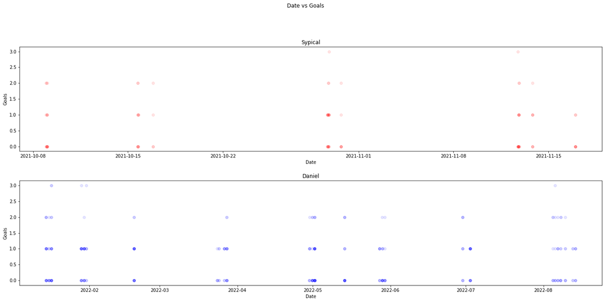

```python
fig, axs = plt.subplots(2,figsize=(20, 10))
fig.suptitle('Date vs Goals')
axs[0].scatter(Sypical["date"],Sypical["core_goals"], color = '#FF0000', alpha=0.1)
axs[1].scatter(Daniel["date"],Daniel["core_goals"], color = '#0000FF', alpha=0.1)
fig.tight_layout(pad=5.0)
axs[0].set_title('Sypical')
axs[1].set_title('Daniel')
for ax in axs.flat:
    ax.set(xlabel='Date', ylabel='Goals')
```

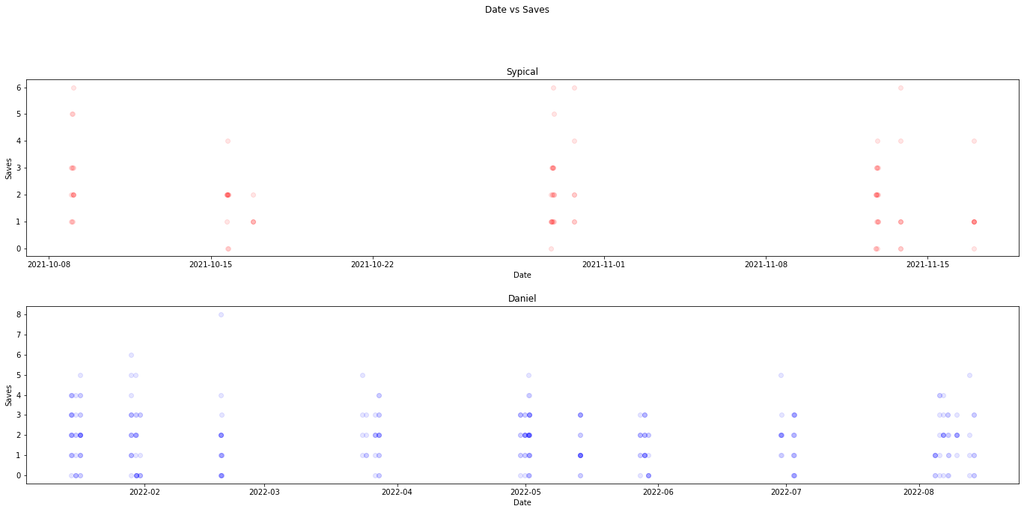

```python
fig, axs = plt.subplots(2,figsize=(20, 10))
fig.suptitle('Date vs Saves')
axs[0].scatter(Sypical["date"],Sypical["core_saves"], color = '#FF0000', alpha=0.1)
axs[1].scatter(Daniel["date"],Daniel["core_saves"], color = '#0000FF', alpha=0.1)
fig.tight_layout(pad=5.0)
axs[0].set_title('Sypical')
axs[1].set_title('Daniel')
for ax in axs.flat:
    ax.set(xlabel='Date', ylabel='Saves')
```

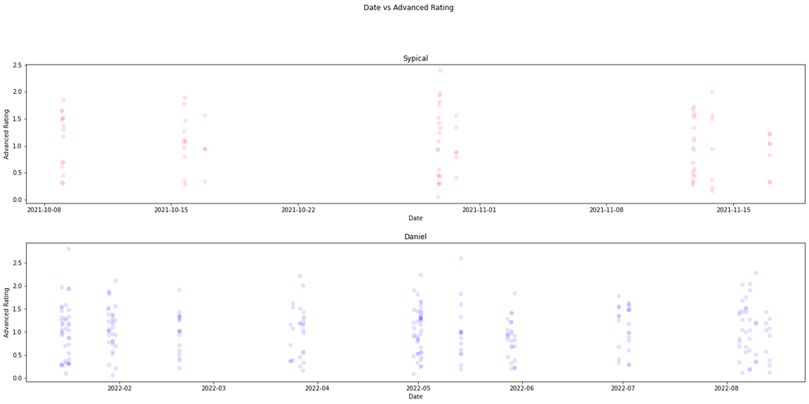

```python
fig, axs = plt.subplots(2,figsize=(20, 10))
fig.suptitle('Date vs Advanced Rating')
axs[0].scatter(Sypical["date"],Sypical["advanced_rating"], color = '#FF0000', alpha=0.1)
axs[1].scatter(Daniel["date"],Daniel["advanced_rating"], color = '#0000FF', alpha=0.1)
fig.tight_layout(pad=5.0)
axs[0].set_title('Sypical')
axs[1].set_title('Daniel')
for ax in axs.flat:
    ax.set(xlabel='Date', ylabel='Advanced Rating')
```

```python
with pd.option_context('display.max_rows', None, 'display.max_columns', None):
    display(Sypical.describe())
```

|  | game | core_shots | core_goals | core_saves | core_assists | core_score | core_shooting_percentage | boost_bpm | boost_bcpm | boost_avg_amount | boost_amount_collected | boost_amount_stolen | boost_amount_collected_big | boost_amount_stolen_big | boost_amount_collected_small | boost_amount_stolen_small | boost_count_collected_big | boost_count_stolen_big | boost_count_collected_small | boost_count_stolen_small | boost_amount_overfill | boost_amount_overfill_stolen | boost_amount_used_while_supersonic | boost_time_zero_boost | boost_percent_zero_boost | boost_time_full_boost | boost_percent_full_boost | boost_time_boost_0_25 | boost_time_boost_25_50 | … |
| --- | --- | --- | --- | --- | --- | --- | --- | --- | --- | --- | --- | --- | --- | --- | --- | --- | --- | --- | --- | --- | --- | --- | --- | --- | --- | --- | --- | --- | --- | --- |
| count | 88.000000 | 88.000000 | 88.000000 | 88.000000 | 88.000000 | 88.000000 | 88.000000 | 88.000000 | 88.000000 | 88.000000 | 88.000000 | 88.000000 | 88.000000 | 88.000000 | 88.000000 | 88.000000 | 88.000000 | 88.000000 | 88.000000 | 88.000000 | 88.000000 | 88.000000 | 88.000000 | 88.000000 | 88.000000 | 88.000000 | 88.000000 | 88.000000 | 88.000000 | … |
| mean | 749.204545 | 3.113636 | 0.670455 | 2.022727 | 0.454545 | 414.238636 | 21.558442 | 437.397727 | 439.422021 | 48.042500 | 2656.590909 | 518.193182 | 1866.795455 | 330.920455 | 789.795455 | 187.272727 | 22.659091 | 3.727273 | 68.590909 | 15.806818 | 405.602273 | 40.602273 | 453.965909 | 50.694659 | 14.087426 | 34.981477 | 9.493459 | 130.242386 | 77.644773 | … |
| std | 577.199724 | 1.677654 | 0.798297 | 1.469829 | 0.676521 | 162.961316 | 28.532630 | 35.789788 | 37.908922 | 3.511792 | 701.676459 | 262.983582 | 526.777825 | 208.626941 | 231.646588 | 93.279549 | 6.775355 | 2.327878 | 18.663774 | 6.793942 | 197.823243 | 44.419510 | 157.961762 | 15.990449 | 3.339281 | 15.094626 | 2.535370 | 35.281532 | 23.245802 | … |
| min | 0.000000 | 0.000000 | 0.000000 | 0.000000 | 0.000000 | 144.000000 | 0.000000 | 336.000000 | 354.642640 | 38.230000 | 1653.000000 | 94.000000 | 1137.000000 | 0.000000 | 515.000000 | 48.000000 | 12.000000 | 0.000000 | 45.000000 | 4.000000 | 87.000000 | 0.000000 | 242.000000 | 19.290000 | 5.709973 | 15.530000 | 4.746042 | 84.440000 | 37.150000 | … |
| 25% | 114.750000 | 2.000000 | 0.000000 | 1.000000 | 0.000000 | 281.000000 | 0.000000 | 415.250000 | 410.813145 | 45.897500 | 2271.500000 | 345.750000 | 1543.000000 | 193.750000 | 663.250000 | 130.000000 | 19.000000 | 2.000000 | 58.750000 | 11.000000 | 269.750000 | 3.750000 | 352.250000 | 41.600000 | 12.053839 | 25.707500 | 7.840495 | 109.430000 | 62.855000 | … |
| 50% | 727.500000 | 3.000000 | 0.000000 | 2.000000 | 0.000000 | 382.000000 | 0.000000 | 439.000000 | 441.973725 | 48.285000 | 2506.500000 | 479.500000 | 1796.500000 | 300.000000 | 735.000000 | 177.000000 | 21.500000 | 3.000000 | 64.000000 | 15.000000 | 380.500000 | 33.000000 | 415.500000 | 48.485000 | 13.874497 | 30.825000 | 9.342795 | 120.345000 | 73.010000 | … |
| 75% | 1311.250000 | 4.000000 | 1.000000 | 3.000000 | 1.000000 | 537.250000 | 33.333333 | 463.500000 | 466.388802 | 50.377500 | 2724.250000 | 668.500000 | 2003.500000 | 468.500000 | 856.250000 | 209.250000 | 24.250000 | 5.000000 | 73.000000 | 18.000000 | 507.750000 | 54.750000 | 507.750000 | 57.027500 | 15.758388 | 41.605000 | 10.921522 | 141.655000 | 84.847500 | … |
| max | 1741.000000 | 7.000000 | 3.000000 | 6.000000 | 3.000000 | 940.000000 | 100.000000 | 511.000000 | 520.285030 | 56.520000 | 6395.000000 | 1638.000000 | 4379.000000 | 884.000000 | 2016.000000 | 774.000000 | 54.000000 | 10.000000 | 155.000000 | 53.000000 | 1182.000000 | 212.000000 | 1068.000000 | 130.520000 | 22.680650 | 97.470000 | 14.606411 | 297.930000 | 193.350000 | … |

```python
with pd.option_context('display.max_rows', None, 'display.max_columns', None):
    display(Daniel.describe())
```

|  | game | core_shots | core_goals | core_saves | core_assists | core_score | core_shooting_percentage | boost_bpm | boost_bcpm | boost_avg_amount | boost_amount_collected | boost_amount_stolen | boost_amount_collected_big | boost_amount_stolen_big | boost_amount_collected_small | boost_amount_stolen_small | boost_count_collected_big | boost_count_stolen_big | boost_count_collected_small | boost_count_stolen_small | boost_amount_overfill | boost_amount_overfill_stolen | boost_amount_used_while_supersonic | boost_time_zero_boost | boost_percent_zero_boost | boost_time_full_boost | boost_percent_full_boost | boost_time_boost_0_25 | boost_time_boost_25_50 | … |
| --- | --- | --- | --- | --- | --- | --- | --- | --- | --- | --- | --- | --- | --- | --- | --- | --- | --- | --- | --- | --- | --- | --- | --- | --- | --- | --- | --- | --- | --- | --- |
| count | 261.000000 | 261.000000 | 261.000000 | 261.000000 | 261.000000 | 261.000000 | 261.000000 | 261.000000 | 261.000000 | 261.00000 | 261.00000 | 261.000000 | 261.000000 | 261.000000 | 261.000000 | 261.000000 | 261.000000 | 261.000000 | 261.000000 | 261.000000 | 261.000000 | 261.000000 | 261.000000 | 261.000000 | 261.000000 | 261.000000 | 261.000000 | 261.000000 | 261.000000 | … |
| mean | 4077.620690 | 3.095785 | 0.685824 | 1.823755 | 0.498084 | 403.697318 | 21.597792 | 426.348659 | 432.040147 | 50.22092 | 2553.67433 | 565.816092 | 1846.605364 | 374.191571 | 707.068966 | 191.624521 | 22.432950 | 4.252874 | 61.118774 | 16.636015 | 413.969349 | 52.773946 | 450.567050 | 43.696667 | 12.314589 | 43.106743 | 12.206500 | 122.360728 | 74.444100 | … |
| std | 1251.847314 | 1.759158 | 0.760156 | 1.344351 | 0.710496 | 154.727715 | 25.871481 | 45.199527 | 47.802851 | 3.74552 | 564.19170 | 250.603358 | 465.292655 | 210.025717 | 179.192814 | 77.170620 | 5.805858 | 2.382073 | 14.506407 | 6.405053 | 179.161227 | 51.930488 | 182.967211 | 15.385367 | 3.730430 | 13.091081 | 3.182262 | 31.250117 | 19.453307 | … |
| min | 2071.000000 | 0.000000 | 0.000000 | 0.000000 | 0.000000 | 122.000000 | 0.000000 | 266.000000 | 274.403900 | 40.20000 | 1473.00000 | 72.000000 | 785.000000 | 0.000000 | 429.000000 | 54.000000 | 10.000000 | 0.000000 | 38.000000 | 5.000000 | 77.000000 | 0.000000 | 87.000000 | 13.100000 | 3.911265 | 17.130000 | 5.037790 | 49.940000 | 34.560000 | … |
| 25% | 2760.000000 | 2.000000 | 0.000000 | 1.000000 | 0.000000 | 294.000000 | 0.000000 | 399.000000 | 401.468630 | 47.75000 | 2250.00000 | 392.000000 | 1574.000000 | 200.000000 | 589.000000 | 142.000000 | 19.000000 | 2.000000 | 52.000000 | 13.000000 | 287.000000 | 12.000000 | 329.000000 | 32.230000 | 9.423500 | 35.040000 | 10.355331 | 102.320000 | 60.920000 | … |
| 50% | 4127.000000 | 3.000000 | 1.000000 | 2.000000 | 0.000000 | 392.000000 | 16.666667 | 423.000000 | 430.719400 | 50.22000 | 2449.00000 | 532.000000 | 1812.000000 | 367.000000 | 687.000000 | 181.000000 | 22.000000 | 4.000000 | 59.000000 | 16.000000 | 385.000000 | 38.000000 | 418.000000 | 42.420000 | 12.179467 | 41.300000 | 11.933167 | 117.230000 | 71.810000 | … |
| 75% | 5485.000000 | 4.000000 | 1.000000 | 3.000000 | 1.000000 | 498.000000 | 33.333333 | 457.000000 | 469.094200 | 52.88000 | 2705.00000 | 694.000000 | 2043.000000 | 509.000000 | 775.000000 | 236.000000 | 25.000000 | 6.000000 | 66.000000 | 20.000000 | 511.000000 | 78.000000 | 536.000000 | 52.170000 | 14.398290 | 49.830000 | 13.900431 | 133.270000 | 84.010000 | … |
| max | 5738.000000 | 9.000000 | 3.000000 | 8.000000 | 4.000000 | 1017.000000 | 100.000000 | 549.000000 | 578.274660 | 59.17000 | 5707.00000 | 1689.000000 | 4308.000000 | 1303.000000 | 1663.000000 | 498.000000 | 49.000000 | 15.000000 | 143.000000 | 43.000000 | 1209.000000 | 356.000000 | 1368.000000 | 104.050000 | 26.656927 | 110.250000 | 26.214700 | 265.890000 | 167.770000 | … |

#### Since leaving SSG, Sypical was considered a top player however he is no longer in that conversation. One reason might be because of his teammate, Firstkiller. While Daniel is in the considered one of the 20 best in the world, FirstKiller is among a very few who can be considered THE best in the world. Maybe Firstkiller's amazing performance makes Sypical's performace overshadowed.

```python
#Reset Sypical and make Firstkiller's dataframe
First = major_table[major_table.player_tag == "Firstkiller"]
Sypical = major_table[major_table.player_tag == "Sypical"]
```

[figure not shown]

```python
fig, axs = plt.subplots(2,figsize=(20, 10))
fig.suptitle('Date vs Goals')
axs[0].scatter(First["date"],First["core_goals"], color = '#FF0000', alpha=0.1)
axs[1].scatter(Daniel["date"],Daniel["core_goals"], color = '#0000FF', alpha=0.1)
fig.tight_layout(pad=5.0)
axs[0].set_title('Sypical')
axs[1].set_title('Daniel')
for ax in axs.flat:
    ax.set(xlabel='Date', ylabel='Goals')
```

[figure not shown]

```python
fig, axs = plt.subplots(2,figsize=(20, 10))
fig.suptitle('Date vs Saves')
axs[0].scatter(First["date"],First["core_saves"], color = '#FF0000', alpha=0.1)
axs[1].scatter(Daniel["date"],Daniel["core_saves"], color = '#0000FF', alpha=0.1)
fig.tight_layout(pad=5.0)
axs[0].set_title('Sypical')
axs[1].set_title('Daniel')
for ax in axs.flat:
    ax.set(xlabel='Date', ylabel='Saves')
```

[figure not shown]

```python
fig, axs = plt.subplots(2,figsize=(20, 10))
fig.suptitle('Date vs Advanced Rating')
axs[0].scatter(First["date"],First["advanced_rating"], color = '#FF0000', alpha=0.1)
axs[1].scatter(Daniel["date"],Daniel["advanced_rating"], color = '#0000FF', alpha=0.1)
fig.tight_layout(pad=5.0)
axs[0].set_title('Sypical')
axs[1].set_title('Daniel')
for ax in axs.flat:
    ax.set(xlabel='Date', ylabel='Advanced Rating')
```

```python
with pd.option_context('display.max_rows', None, 'display.max_columns', None):
    display(Sypical.describe())
```

|  | game | core_shots | core_goals | core_saves | core_assists | core_score | core_shooting_percentage | boost_bpm | boost_bcpm | boost_avg_amount | boost_amount_collected | boost_amount_stolen | boost_amount_collected_big | boost_amount_stolen_big | boost_amount_collected_small | boost_amount_stolen_small | boost_count_collected_big | boost_count_stolen_big | boost_count_collected_small | boost_count_stolen_small | boost_amount_overfill | boost_amount_overfill_stolen | boost_amount_used_while_supersonic | boost_time_zero_boost | boost_percent_zero_boost | boost_time_full_boost | boost_percent_full_boost | boost_time_boost_0_25 | boost_time_boost_25_50 | … |
| --- | --- | --- | --- | --- | --- | --- | --- | --- | --- | --- | --- | --- | --- | --- | --- | --- | --- | --- | --- | --- | --- | --- | --- | --- | --- | --- | --- | --- | --- | --- |
| count | 307.000000 | 307.000000 | 307.000000 | 307.000000 | 307.000000 | 307.000000 | 307.000000 | 307.000000 | 307.000000 | 307.000000 | 307.000000 | 307.000000 | 307.000000 | 307.000000 | 307.000000 | 307.000000 | 307.000000 | 307.000000 | 307.000000 | 307.000000 | 307.000000 | 307.000000 | 307.000000 | 307.000000 | 307.000000 | 307.000000 | 307.000000 | 307.000000 | 307.000000 | … |
| mean | 3005.384365 | 3.013029 | 0.749186 | 1.553746 | 0.657980 | 387.530945 | 24.032108 | 439.583062 | 441.974166 | 46.016384 | 2645.791531 | 570.964169 | 1841.042345 | 348.996743 | 804.749186 | 221.967427 | 21.543974 | 3.928339 | 69.710098 | 18.977199 | 316.315961 | 42.964169 | 442.951140 | 55.675114 | 15.570255 | 28.241498 | 7.815550 | 138.148958 | 79.901824 | … |
| std | 1774.746434 | 1.813122 | 0.858802 | 1.338059 | 0.826616 | 155.242173 | 28.693589 | 34.965559 | 38.607291 | 3.888663 | 635.817442 | 256.704496 | 467.479755 | 195.680203 | 224.986925 | 101.649302 | 5.811347 | 2.166609 | 18.681122 | 8.192704 | 163.231564 | 43.464530 | 159.018253 | 16.236922 | 3.486840 | 11.580496 | 2.353967 | 35.085724 | 22.274787 | … |
| min | 0.000000 | 0.000000 | 0.000000 | 0.000000 | 0.000000 | 80.000000 | 0.000000 | 302.000000 | 302.093800 | 35.390000 | 1652.000000 | 94.000000 | 1017.000000 | 0.000000 | 434.000000 | 48.000000 | 11.000000 | 0.000000 | 42.000000 | 4.000000 | 66.000000 | 0.000000 | 140.000000 | 19.290000 | 5.709973 | 9.920000 | 3.050056 | 83.470000 | 37.150000 | … |
| 25% | 1381.500000 | 2.000000 | 0.000000 | 1.000000 | 0.000000 | 267.500000 | 0.000000 | 417.000000 | 417.010330 | 43.615000 | 2339.000000 | 394.500000 | 1585.000000 | 200.000000 | 688.500000 | 163.000000 | 18.000000 | 2.000000 | 60.000000 | 14.000000 | 200.500000 | 8.000000 | 348.500000 | 45.670000 | 13.139825 | 21.020000 | 6.082824 | 116.165000 | 65.055000 | … |
| 50% | 3263.000000 | 3.000000 | 1.000000 | 1.000000 | 0.000000 | 370.000000 | 16.666667 | 442.000000 | 446.506160 | 46.140000 | 2529.000000 | 549.000000 | 1792.000000 | 330.000000 | 767.000000 | 210.000000 | 21.000000 | 4.000000 | 67.000000 | 18.000000 | 291.000000 | 32.000000 | 416.000000 | 54.560000 | 15.041438 | 26.010000 | 7.454501 | 134.330000 | 76.770000 | … |
| 75% | 4354.000000 | 4.000000 | 1.000000 | 2.000000 | 1.000000 | 479.000000 | 41.428571 | 465.000000 | 467.330110 | 48.700000 | 2759.000000 | 708.500000 | 1996.500000 | 466.500000 | 861.500000 | 263.000000 | 23.000000 | 5.000000 | 73.500000 | 22.000000 | 394.000000 | 64.000000 | 509.000000 | 63.120000 | 17.930310 | 32.445000 | 9.284115 | 150.750000 | 90.300000 | … |
| max | 5828.000000 | 13.000000 | 4.000000 | 7.000000 | 4.000000 | 940.000000 | 133.333333 | 525.000000 | 533.925300 | 56.520000 | 8659.000000 | 2533.000000 | 5749.000000 | 1405.000000 | 2910.000000 | 1128.000000 | 68.000000 | 16.000000 | 248.000000 | 91.000000 | 1182.000000 | 212.000000 | 1970.000000 | 174.100000 | 28.176552 | 97.470000 | 14.606411 | 412.100000 | 244.120000 | … |

```python
with pd.option_context('display.max_rows', None, 'display.max_columns', None):
    display(First.describe())
```

|  | game | core_shots | core_goals | core_saves | core_assists | core_score | core_shooting_percentage | boost_bpm | boost_bcpm | boost_avg_amount | boost_amount_collected | boost_amount_stolen | boost_amount_collected_big | boost_amount_stolen_big | boost_amount_collected_small | boost_amount_stolen_small | boost_count_collected_big | boost_count_stolen_big | boost_count_collected_small | boost_count_stolen_small | boost_amount_overfill | boost_amount_overfill_stolen | boost_amount_used_while_supersonic | boost_time_zero_boost | boost_percent_zero_boost | boost_time_full_boost | boost_percent_full_boost | boost_time_boost_0_25 | boost_time_boost_25_50 | … |
| --- | --- | --- | --- | --- | --- | --- | --- | --- | --- | --- | --- | --- | --- | --- | --- | --- | --- | --- | --- | --- | --- | --- | --- | --- | --- | --- | --- | --- | --- | --- |
| count | 305.000000 | 305.000000 | 305.000000 | 305.00000 | 305.000000 | 305.000000 | 305.000000 | 305.000000 | 305.000000 | 305.000000 | 305.000000 | 305.000000 | 305.000000 | 305.000000 | 305.000000 | 305.000000 | 305.000000 | 305.000000 | 305.000000 | 305.000000 | 305.000000 | 305.000000 | 305.000000 | 305.000000 | 305.000000 | 305.000000 | 305.000000 | 305.000000 | 305.000000 | … |
| mean | 3108.996721 | 3.747541 | 0.947541 | 1.80000 | 0.675410 | 463.409836 | 23.836633 | 456.668852 | 471.005901 | 50.993934 | 2809.940984 | 745.222951 | 1921.708197 | 434.724590 | 888.232787 | 310.498361 | 23.698361 | 5.265574 | 76.960656 | 26.665574 | 466.714754 | 96.301639 | 525.157377 | 43.169344 | 12.060788 | 55.657803 | 15.506324 | 117.916951 | 74.864820 | … |
| std | 1664.240694 | 2.033891 | 1.031033 | 1.48102 | 0.844614 | 189.979845 | 25.105201 | 29.432771 | 36.632491 | 3.497853 | 644.412480 | 279.887988 | 463.972836 | 212.841018 | 242.968433 | 115.295134 | 5.856915 | 2.508858 | 20.213297 | 9.049914 | 174.936231 | 68.953795 | 174.716598 | 14.816872 | 3.201164 | 17.492447 | 3.150520 | 30.720007 | 20.043727 | … |
| min | 74.000000 | 0.000000 | 0.000000 | 0.00000 | 0.000000 | 118.000000 | 0.000000 | 372.000000 | 378.563480 | 41.700000 | 2014.000000 | 96.000000 | 1213.000000 | 0.000000 | 534.000000 | 96.000000 | 14.000000 | 0.000000 | 48.000000 | 8.000000 | 118.000000 | 0.000000 | 263.000000 | 13.720000 | 4.214731 | 25.660000 | 7.821854 | 52.270000 | 37.390000 | … |
| 25% | 1854.000000 | 2.000000 | 0.000000 | 1.00000 | 0.000000 | 338.000000 | 0.000000 | 439.000000 | 447.947000 | 48.400000 | 2496.000000 | 560.000000 | 1653.000000 | 283.000000 | 749.000000 | 229.000000 | 20.000000 | 3.000000 | 66.000000 | 21.000000 | 357.000000 | 43.000000 | 409.000000 | 33.800000 | 9.874604 | 44.920000 | 13.283471 | 100.530000 | 63.000000 | … |
| 50% | 3264.000000 | 4.000000 | 1.000000 | 2.00000 | 0.000000 | 424.000000 | 20.000000 | 457.000000 | 469.520170 | 50.940000 | 2671.000000 | 718.000000 | 1852.000000 | 423.000000 | 849.000000 | 290.000000 | 23.000000 | 5.000000 | 73.000000 | 26.000000 | 443.000000 | 83.000000 | 499.000000 | 40.930000 | 11.855355 | 53.190000 | 15.349391 | 112.230000 | 72.030000 | … |
| 75% | 4570.000000 | 5.000000 | 1.000000 | 3.00000 | 1.000000 | 573.000000 | 40.000000 | 476.000000 | 496.539200 | 53.370000 | 2901.000000 | 911.000000 | 2083.000000 | 557.000000 | 957.000000 | 373.000000 | 26.000000 | 7.000000 | 82.000000 | 31.000000 | 562.000000 | 137.000000 | 605.000000 | 48.320000 | 14.008951 | 60.690000 | 17.493980 | 128.120000 | 82.680000 | … |
| max | 5828.000000 | 11.000000 | 5.000000 | 7.00000 | 4.000000 | 1168.000000 | 100.000000 | 548.000000 | 573.260600 | 61.090000 | 8882.000000 | 2089.000000 | 5820.000000 | 1237.000000 | 3062.000000 | 1014.000000 | 75.000000 | 13.000000 | 270.000000 | 84.000000 | 1830.000000 | 353.000000 | 2089.000000 | 124.930000 | 24.509924 | 196.850000 | 25.977190 | 318.490000 | 234.530000 | … |

#### Overall it seems that Firstkiller is overshadowing Sypical with Firstkiller's outstanding performance. His mean goals is the close to the 75% of all players. His mean saves is lower than the mean saves for all players. Overall with such a dominant amount of goals, his advanced rating is very high. His mean advanced rating is close to the 75% of all players, whereas Sypical's mean advanced rating is close to the mean of all players.

#### From a previous part, where we compared Arsenal, Retals, and Sypical, we found that overall, while both Arsenal and Retals' advanced rating fell, Arsenal's advaned rating fell harder, and his mean advanced rating was lower than Retals'.

#### This leads me to believe that Arsenal should have been dropped instead of Retals.

#### In the next season, RLCS 22-23, Retals will be replaced with LJ from Oxygen Esports. However there were numerous other choices SSG could have made.

#### Some notable free agents were:

#### Mist from Optic gaming

#### ApparentlyJack from Dignitas

#### Noly from Karmine Corp

```python
#Make dataframes for all possible free agents
Lj = major_table[major_table.player_tag == "Lj"]
Mist = major_table[major_table.player_tag == "mist"]
App = major_table[major_table.player_tag == "ApparentlyJack"]
Noly = major_table[major_table.player_tag == "noly"]
```

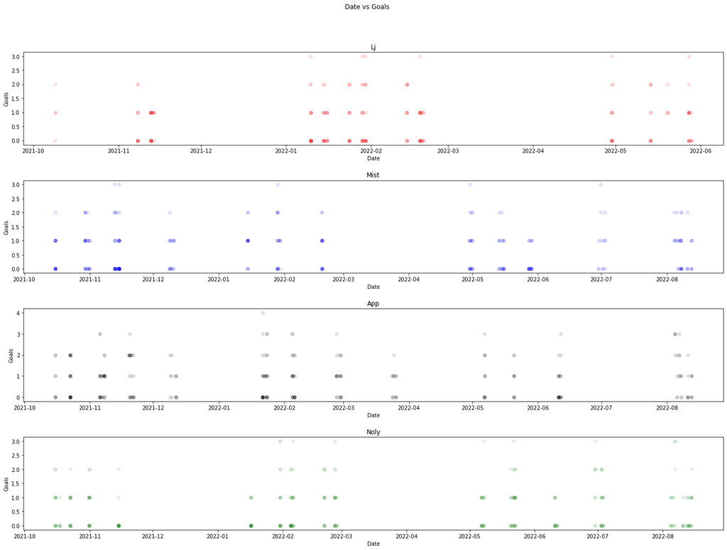

```python
fig, axs = plt.subplots(4,figsize=(20, 15))
fig.suptitle('Date vs Goals')
axs[0].scatter(Lj["date"],Lj["core_goals"], color = '#FF0000', alpha=0.1)
axs[1].scatter(Mist["date"],Mist["core_goals"], color = '#0000FF', alpha=0.1)
axs[2].scatter(App["date"],App["core_goals"], color = '#000000', alpha=0.1)
axs[3].scatter(Noly["date"],Noly["core_goals"], color = '#228B22', alpha=0.1)
fig.tight_layout(pad=5.0)
axs[0].set_title('Lj')
axs[1].set_title('Mist')
axs[2].set_title('App')
axs[3].set_title('Noly')
for ax in axs.flat:
    ax.set(xlabel='Date', ylabel='Goals')
```

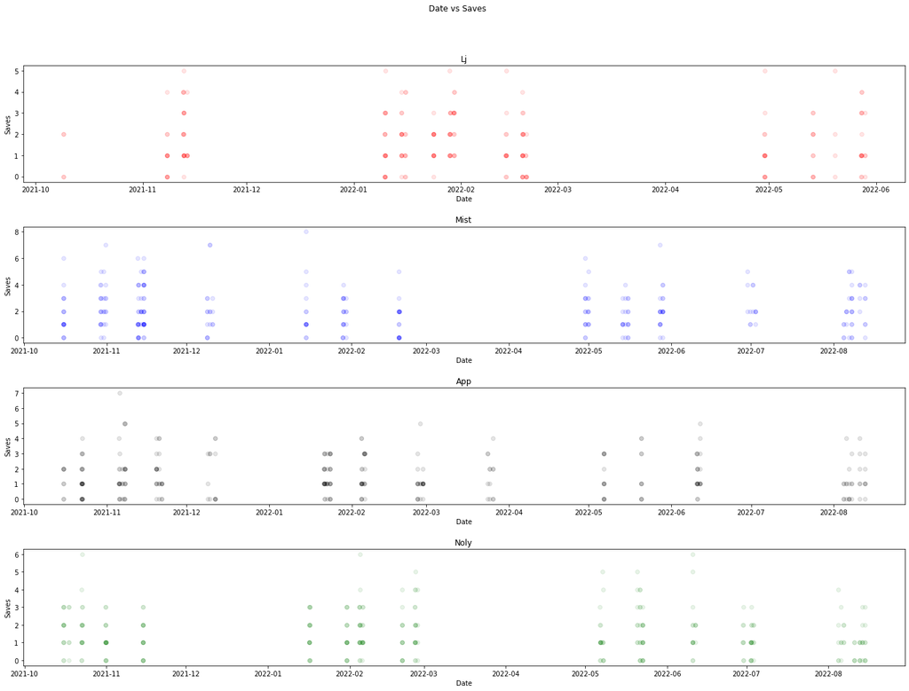

```python
fig, axs = plt.subplots(4,figsize=(20, 15))
fig.suptitle('Date vs Saves')
axs[0].scatter(Lj["date"],Lj["core_saves"], color = '#FF0000', alpha=0.1)
axs[1].scatter(Mist["date"],Mist["core_saves"], color = '#0000FF', alpha=0.1)
axs[2].scatter(App["date"],App["core_saves"], color = '#000000', alpha=0.1)
axs[3].scatter(Noly["date"],Noly["core_saves"], color = '#228B22', alpha=0.1)
fig.tight_layout(pad=5.0)
axs[0].set_title('Lj')
axs[1].set_title('Mist')
axs[2].set_title('App')
axs[3].set_title('Noly')
for ax in axs.flat:
    ax.set(xlabel='Date', ylabel='Saves')
```

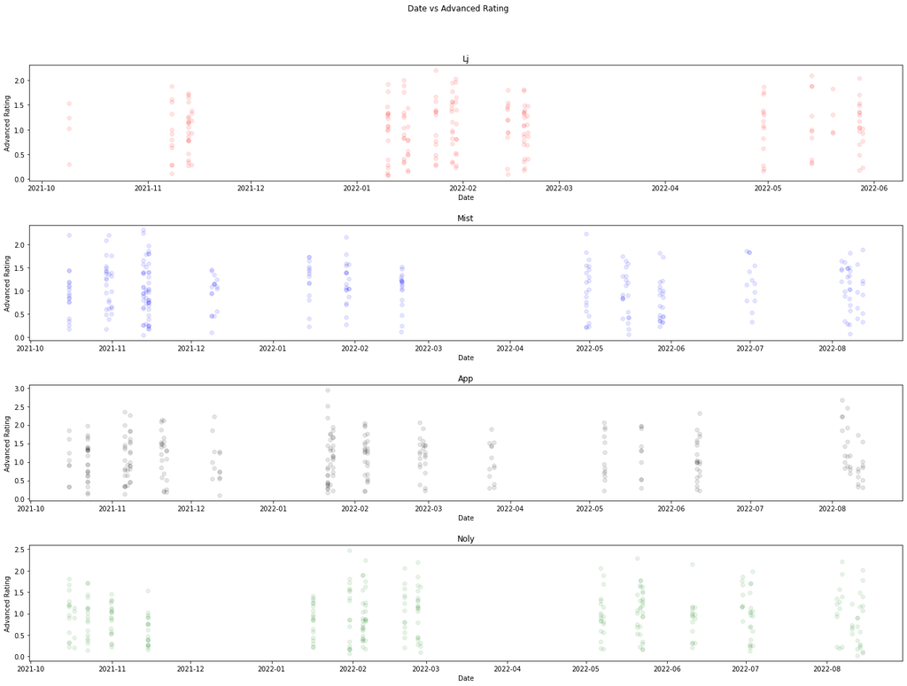

```python
fig, axs = plt.subplots(4,figsize=(20, 15))
fig.suptitle('Date vs Advanced Rating')
axs[0].scatter(Lj["date"],Lj["advanced_rating"], color = '#FF0000', alpha=0.1)
axs[1].scatter(Mist["date"],Mist["advanced_rating"], color = '#0000FF', alpha=0.1)
axs[2].scatter(App["date"],App["advanced_rating"], color = '#000000', alpha=0.1)
axs[3].scatter(Noly["date"],Noly["advanced_rating"], color = '#228B22', alpha=0.1)
fig.tight_layout(pad=5.0)
axs[0].set_title('Lj')
axs[1].set_title('Mist')
axs[2].set_title('App')
axs[3].set_title('Noly')
for ax in axs.flat:
    ax.set(xlabel='Date', ylabel='Advanced Rating')
```

```python
with pd.option_context('display.max_rows', None, 'display.max_columns', None):
    display(Lj.describe())
```

|  | game | core_shots | core_goals | core_saves | core_assists | core_score | core_shooting_percentage | boost_bpm | boost_bcpm | boost_avg_amount | boost_amount_collected | boost_amount_stolen | boost_amount_collected_big | boost_amount_stolen_big | boost_amount_collected_small | boost_amount_stolen_small | boost_count_collected_big | boost_count_stolen_big | boost_count_collected_small | boost_count_stolen_small | boost_amount_overfill | boost_amount_overfill_stolen | boost_amount_used_while_supersonic | boost_time_zero_boost | boost_percent_zero_boost | boost_time_full_boost | boost_percent_full_boost | boost_time_boost_0_25 | boost_time_boost_25_50 | … |
| --- | --- | --- | --- | --- | --- | --- | --- | --- | --- | --- | --- | --- | --- | --- | --- | --- | --- | --- | --- | --- | --- | --- | --- | --- | --- | --- | --- | --- | --- | --- |
| count | 204.000000 | 204.000000 | 204.000000 | 204.000000 | 204.000000 | 204.000000 | 204.000000 | 204.000000 | 204.000000 | 204.000000 | 204.000000 | 204.000000 | 204.000000 | 204.000000 | 204.000000 | 204.000000 | 204.000000 | 204.000000 | 204.000000 | 204.000000 | 204.000000 | 204.000000 | 204.000000 | 204.000000 | 204.000000 | 204.000000 | 204.000000 | 204.000000 | 204.000000 | … |
| mean | 2803.000000 | 2.715686 | 0.696078 | 1.637255 | 0.607843 | 388.490196 | 23.755836 | 403.446078 | 415.321540 | 50.559412 | 2399.127451 | 576.171569 | 1677.215686 | 344.681373 | 721.911765 | 231.490196 | 20.455882 | 4.044118 | 63.122549 | 19.955882 | 378.186275 | 63.004902 | 314.946078 | 37.319314 | 10.750041 | 39.239118 | 11.319625 | 115.840343 | 77.051471 | … |
| std | 1262.780664 | 1.596656 | 0.803799 | 1.273367 | 0.789798 | 145.341808 | 28.384296 | 31.766420 | 36.799134 | 3.890709 | 343.043109 | 206.104629 | 288.831061 | 165.840720 | 136.426931 | 79.180438 | 3.506927 | 1.948352 | 11.311953 | 6.584279 | 130.489962 | 52.595913 | 113.886911 | 12.333500 | 3.273164 | 11.060021 | 2.858279 | 26.321665 | 18.133358 | … |
| min | 14.000000 | 0.000000 | 0.000000 | 0.000000 | 0.000000 | 122.000000 | 0.000000 | 316.000000 | 321.286070 | 39.630000 | 1826.000000 | 54.000000 | 1157.000000 | 0.000000 | 466.000000 | 54.000000 | 13.000000 | 0.000000 | 37.000000 | 5.000000 | 110.000000 | 0.000000 | 69.000000 | 9.250000 | 2.885305 | 14.460000 | 4.574357 | 57.970000 | 30.980000 | … |
| 25% | 1964.750000 | 2.000000 | 0.000000 | 1.000000 | 0.000000 | 277.500000 | 0.000000 | 383.000000 | 389.718215 | 47.920000 | 2151.750000 | 422.750000 | 1468.750000 | 202.250000 | 626.250000 | 172.750000 | 18.000000 | 3.000000 | 55.750000 | 15.000000 | 294.000000 | 25.000000 | 242.000000 | 28.287500 | 8.423493 | 30.740000 | 9.109838 | 94.357500 | 65.145000 | … |
| 50% | 2649.500000 | 2.000000 | 1.000000 | 1.000000 | 0.000000 | 362.000000 | 16.666667 | 401.500000 | 411.608140 | 50.665000 | 2348.500000 | 562.500000 | 1651.500000 | 330.000000 | 691.000000 | 227.000000 | 20.000000 | 4.000000 | 61.000000 | 19.000000 | 365.000000 | 48.000000 | 300.500000 | 36.425000 | 10.646695 | 38.270000 | 10.940873 | 115.775000 | 75.280000 | … |
| 75% | 3366.250000 | 4.000000 | 1.000000 | 2.000000 | 1.000000 | 495.000000 | 42.500000 | 424.250000 | 441.910280 | 53.460000 | 2562.750000 | 701.750000 | 1859.250000 | 447.750000 | 790.250000 | 282.000000 | 23.000000 | 5.000000 | 68.000000 | 24.000000 | 454.000000 | 94.500000 | 365.250000 | 44.710000 | 12.784887 | 46.070000 | 13.201964 | 132.530000 | 88.790000 | … |
| max | 5181.000000 | 7.000000 | 3.000000 | 5.000000 | 4.000000 | 837.000000 | 100.000000 | 488.000000 | 519.050200 | 60.720000 | 4140.000000 | 1194.000000 | 3088.000000 | 833.000000 | 1347.000000 | 507.000000 | 35.000000 | 10.000000 | 108.000000 | 40.000000 | 824.000000 | 245.000000 | 753.000000 | 92.590000 | 21.168272 | 89.890000 | 19.317804 | 219.940000 | 169.400000 | … |

```python
with pd.option_context('display.max_rows', None, 'display.max_columns', None):
    display(Mist.describe())
```

|  | game | core_shots | core_goals | core_saves | core_assists | core_score | core_shooting_percentage | boost_bpm | boost_bcpm | boost_avg_amount | boost_amount_collected | boost_amount_stolen | boost_amount_collected_big | boost_amount_stolen_big | boost_amount_collected_small | boost_amount_stolen_small | boost_count_collected_big | boost_count_stolen_big | boost_count_collected_small | boost_count_stolen_small | boost_amount_overfill | boost_amount_overfill_stolen | boost_amount_used_while_supersonic | boost_time_zero_boost | boost_percent_zero_boost | boost_time_full_boost | boost_percent_full_boost | boost_time_boost_0_25 | boost_time_boost_25_50 | … |
| --- | --- | --- | --- | --- | --- | --- | --- | --- | --- | --- | --- | --- | --- | --- | --- | --- | --- | --- | --- | --- | --- | --- | --- | --- | --- | --- | --- | --- | --- | --- |
| count | 275.000000 | 275.000000 | 275.000000 | 275.000000 | 275.000000 | 275.000000 | 275.000000 | 275.000000 | 275.000000 | 275.000000 | 275.00000 | 275.000000 | 275.000000 | 275.000000 | 275.000000 | 275.000000 | 275.000000 | 275.000000 | 275.000000 | 275.000000 | 275.000000 | 275.000000 | 275.000000 | 275.000000 | 275.000000 | 275.000000 | 275.000000 | 275.000000 | 275.000000 | … |
| mean | 2983.610909 | 3.010909 | 0.643636 | 2.054545 | 0.476364 | 411.970909 | 20.726118 | 419.167273 | 426.133439 | 49.925564 | 2549.72000 | 542.541818 | 1908.294545 | 375.432727 | 641.425455 | 167.109091 | 23.330909 | 4.469091 | 53.061818 | 14.080000 | 421.767273 | 71.352727 | 314.258182 | 47.922327 | 13.351501 | 42.922109 | 11.981151 | 122.805855 | 72.910327 | … |
| std | 1882.380252 | 1.789025 | 0.752311 | 1.598564 | 0.690383 | 158.884866 | 26.941220 | 32.743546 | 37.096375 | 3.892281 | 574.01562 | 228.628362 | 449.047496 | 197.373479 | 200.250165 | 70.655862 | 5.751194 | 2.340135 | 15.209720 | 5.420372 | 174.277833 | 61.370443 | 123.788415 | 16.301395 | 3.617544 | 12.845845 | 2.792581 | 35.524877 | 20.705654 | … |
| min | 79.000000 | 0.000000 | 0.000000 | 0.000000 | 0.000000 | 92.000000 | 0.000000 | 330.000000 | 317.791720 | 37.740000 | 1654.00000 | 72.000000 | 1076.000000 | 0.000000 | 327.000000 | 23.000000 | 12.000000 | 0.000000 | 28.000000 | 2.000000 | 80.000000 | 0.000000 | 91.000000 | 18.360000 | 5.745400 | 15.670000 | 4.996971 | 48.810000 | 28.930000 | … |
| 25% | 1384.500000 | 2.000000 | 0.000000 | 1.000000 | 0.000000 | 300.000000 | 0.000000 | 396.000000 | 399.179835 | 47.075000 | 2234.00000 | 391.500000 | 1636.500000 | 234.500000 | 515.000000 | 117.000000 | 20.000000 | 3.000000 | 44.000000 | 10.000000 | 306.000000 | 25.000000 | 234.000000 | 36.000000 | 10.848198 | 34.120000 | 9.930470 | 101.235000 | 61.810000 | … |
| 50% | 2674.000000 | 3.000000 | 0.000000 | 2.000000 | 0.000000 | 391.000000 | 0.000000 | 422.000000 | 428.410640 | 49.840000 | 2421.00000 | 505.000000 | 1850.000000 | 350.000000 | 607.000000 | 158.000000 | 22.000000 | 4.000000 | 51.000000 | 14.000000 | 404.000000 | 56.000000 | 292.000000 | 45.920000 | 12.814290 | 41.620000 | 11.872656 | 117.490000 | 70.620000 | … |
| 75% | 4668.500000 | 4.000000 | 1.000000 | 3.000000 | 1.000000 | 487.500000 | 33.333333 | 443.500000 | 451.707050 | 52.635000 | 2616.50000 | 659.000000 | 2033.000000 | 484.500000 | 722.000000 | 201.000000 | 25.500000 | 6.000000 | 58.000000 | 17.000000 | 515.500000 | 108.000000 | 379.500000 | 56.605000 | 15.743595 | 49.340000 | 13.935719 | 136.980000 | 80.740000 | … |
| max | 5778.000000 | 9.000000 | 3.000000 | 8.000000 | 3.000000 | 1041.000000 | 150.000000 | 516.000000 | 532.278260 | 61.460000 | 5657.00000 | 1532.000000 | 4345.000000 | 1055.000000 | 1643.000000 | 477.000000 | 54.000000 | 14.000000 | 137.000000 | 42.000000 | 1103.000000 | 348.000000 | 995.000000 | 143.130000 | 24.661900 | 109.000000 | 20.540833 | 335.690000 | 199.590000 | … |

```python
with pd.option_context('display.max_rows', None, 'display.max_columns', None):
    display(App.describe())
```

|  | game | core_shots | core_goals | core_saves | core_assists | core_score | core_shooting_percentage | boost_bpm | boost_bcpm | boost_avg_amount | boost_amount_collected | boost_amount_stolen | boost_amount_collected_big | boost_amount_stolen_big | boost_amount_collected_small | boost_amount_stolen_small | boost_count_collected_big | boost_count_stolen_big | boost_count_collected_small | boost_count_stolen_small | boost_amount_overfill | boost_amount_overfill_stolen | boost_amount_used_while_supersonic | boost_time_zero_boost | boost_percent_zero_boost | boost_time_full_boost | boost_percent_full_boost | boost_time_boost_0_25 | boost_time_boost_25_50 | … |
| --- | --- | --- | --- | --- | --- | --- | --- | --- | --- | --- | --- | --- | --- | --- | --- | --- | --- | --- | --- | --- | --- | --- | --- | --- | --- | --- | --- | --- | --- | --- |
| count | 273.000000 | 273.000000 | 273.000000 | 273.000000 | 273.000000 | 273.000000 | 273.000000 | 273.000000 | 273.000000 | 273.000000 | 273.000000 | 273.000000 | 273.000000 | 273.000000 | 273.000000 | 273.000000 | 273.000000 | 273.000000 | 273.000000 | 273.000000 | 273.000000 | 273.000000 | 273.000000 | 273.000000 | 273.000000 | 273.000000 | 273.000000 | 273.000000 | 273.000000 | … |
| mean | 2913.728938 | 3.380952 | 0.857143 | 1.494505 | 0.659341 | 408.443223 | 24.708704 | 419.758242 | 435.347233 | 50.607033 | 2581.586081 | 701.443223 | 1746.765568 | 417.102564 | 834.820513 | 284.340659 | 21.329670 | 5.025641 | 72.970696 | 24.802198 | 400.109890 | 90.216117 | 388.391941 | 38.027912 | 10.718749 | 40.219560 | 11.333685 | 111.981245 | 82.968938 | … |
| std | 1746.618041 | 1.833492 | 0.922410 | 1.292287 | 0.802841 | 161.546312 | 27.357762 | 32.490046 | 35.269582 | 3.883772 | 486.201492 | 238.716277 | 364.290865 | 193.445112 | 199.192932 | 89.886884 | 4.573071 | 2.296753 | 16.820174 | 7.421481 | 154.598754 | 63.164068 | 138.730445 | 12.001856 | 3.026920 | 11.906241 | 2.882013 | 28.258006 | 20.295973 | … |
| min | 237.000000 | 0.000000 | 0.000000 | 0.000000 | 0.000000 | 92.000000 | 0.000000 | 335.000000 | 331.259430 | 39.030000 | 1757.000000 | 202.000000 | 1001.000000 | 0.000000 | 535.000000 | 60.000000 | 13.000000 | 0.000000 | 48.000000 | 5.000000 | 97.000000 | 0.000000 | 109.000000 | 13.330000 | 3.984933 | 16.170000 | 4.985540 | 50.880000 | 46.200000 | … |
| 25% | 1588.000000 | 2.000000 | 0.000000 | 1.000000 | 0.000000 | 278.000000 | 0.000000 | 395.000000 | 412.112520 | 48.370000 | 2298.000000 | 533.000000 | 1501.000000 | 275.000000 | 715.000000 | 222.000000 | 18.000000 | 3.000000 | 63.000000 | 20.000000 | 296.000000 | 45.000000 | 298.000000 | 30.230000 | 8.606964 | 32.250000 | 9.185371 | 93.120000 | 69.570000 | … |
| 50% | 2475.000000 | 3.000000 | 1.000000 | 1.000000 | 0.000000 | 390.000000 | 20.000000 | 420.000000 | 435.030430 | 50.520000 | 2480.000000 | 675.000000 | 1700.000000 | 400.000000 | 798.000000 | 275.000000 | 21.000000 | 5.000000 | 70.000000 | 24.000000 | 378.000000 | 79.000000 | 373.000000 | 36.240000 | 10.480955 | 38.540000 | 11.135303 | 108.750000 | 80.300000 | … |
| 75% | 4353.000000 | 4.000000 | 1.000000 | 2.000000 | 1.000000 | 498.000000 | 50.000000 | 444.000000 | 460.594600 | 53.010000 | 2693.000000 | 839.000000 | 1917.000000 | 545.000000 | 891.000000 | 326.000000 | 23.000000 | 6.000000 | 78.000000 | 28.000000 | 474.000000 | 129.000000 | 462.000000 | 43.830000 | 12.420439 | 46.010000 | 13.238855 | 126.210000 | 92.030000 | … |
| max | 5784.000000 | 12.000000 | 4.000000 | 7.000000 | 3.000000 | 947.000000 | 100.000000 | 530.000000 | 568.031800 | 60.820000 | 5374.000000 | 1821.000000 | 3236.000000 | 1120.000000 | 2138.000000 | 701.000000 | 39.000000 | 13.000000 | 179.000000 | 62.000000 | 1000.000000 | 376.000000 | 1076.000000 | 82.560000 | 23.798872 | 90.190000 | 19.913973 | 214.940000 | 182.000000 | … |

```python
with pd.option_context('display.max_rows', None, 'display.max_columns', None):
    display(Noly.describe())
```

|  | game | core_shots | core_goals | core_saves | core_assists | core_score | core_shooting_percentage | boost_bpm | boost_bcpm | boost_avg_amount | boost_amount_collected | boost_amount_stolen | boost_amount_collected_big | boost_amount_stolen_big | boost_amount_collected_small | boost_amount_stolen_small | boost_count_collected_big | boost_count_stolen_big | boost_count_collected_small | boost_count_stolen_small | boost_amount_overfill | boost_amount_overfill_stolen | boost_amount_used_while_supersonic | boost_time_zero_boost | boost_percent_zero_boost | boost_time_full_boost | boost_percent_full_boost | boost_time_boost_0_25 | boost_time_boost_25_50 | … |
| --- | --- | --- | --- | --- | --- | --- | --- | --- | --- | --- | --- | --- | --- | --- | --- | --- | --- | --- | --- | --- | --- | --- | --- | --- | --- | --- | --- | --- | --- | --- |
| count | 303.000000 | 303.000000 | 303.000000 | 303.000000 | 303.000000 | 303.000000 | 303.000000 | 303.000000 | 303.000000 | 303.000000 | 303.000000 | 303.000000 | 303.000000 | 303.000000 | 303.000000 | 303.000000 | 303.000000 | 303.000000 | 303.000000 | 303.000000 | 303.000000 | 303.000000 | 303.000000 | 303.000000 | 303.000000 | 303.000000 | 303.000000 | 303.000000 | 303.000000 | … |
| mean | 3449.660066 | 2.693069 | 0.590759 | 1.455446 | 0.564356 | 351.019802 | 20.729347 | 434.221122 | 449.009658 | 51.264620 | 2637.719472 | 513.306931 | 1969.990099 | 330.600660 | 667.729373 | 182.706271 | 23.686469 | 3.957096 | 56.801980 | 15.369637 | 404.792079 | 66.326733 | 389.851485 | 44.988317 | 12.730733 | 53.313498 | 15.080262 | 121.170858 | 67.422178 | … |
| std | 1842.540078 | 1.646243 | 0.778975 | 1.227646 | 0.719858 | 138.560933 | 29.145296 | 32.113117 | 35.546337 | 3.857648 | 478.835422 | 206.303933 | 386.773754 | 177.199187 | 162.249948 | 73.448699 | 4.912214 | 2.095756 | 13.037658 | 5.511758 | 175.507041 | 62.631706 | 143.649527 | 15.199813 | 3.599029 | 17.371474 | 3.886815 | 29.178985 | 17.558085 | … |
| min | 214.000000 | 0.000000 | 0.000000 | 0.000000 | 0.000000 | 64.000000 | 0.000000 | 330.000000 | 306.806180 | 40.670000 | 1598.000000 | 56.000000 | 1001.000000 | 0.000000 | 365.000000 | 35.000000 | 11.000000 | 0.000000 | 35.000000 | 3.000000 | 77.000000 | 0.000000 | 74.000000 | 15.500000 | 4.707526 | 18.980000 | 5.995704 | 57.590000 | 30.000000 | … |
| 25% | 2229.500000 | 2.000000 | 0.000000 | 1.000000 | 0.000000 | 243.500000 | 0.000000 | 412.000000 | 428.506470 | 48.820000 | 2368.500000 | 361.000000 | 1742.500000 | 200.000000 | 561.500000 | 127.000000 | 21.000000 | 3.000000 | 48.000000 | 11.000000 | 287.000000 | 16.000000 | 290.000000 | 34.810000 | 10.095610 | 41.200000 | 12.152168 | 102.970000 | 54.590000 | … |
| 50% | 3580.000000 | 3.000000 | 0.000000 | 1.000000 | 0.000000 | 340.000000 | 0.000000 | 435.000000 | 449.166230 | 51.240000 | 2538.000000 | 510.000000 | 1917.000000 | 319.000000 | 650.000000 | 167.000000 | 23.000000 | 4.000000 | 55.000000 | 14.000000 | 374.000000 | 50.000000 | 369.000000 | 42.870000 | 12.609926 | 50.170000 | 14.795211 | 118.610000 | 65.090000 | … |
| 75% | 5370.000000 | 3.500000 | 1.000000 | 2.000000 | 1.000000 | 436.500000 | 33.333333 | 454.500000 | 474.270475 | 53.475000 | 2767.500000 | 643.000000 | 2120.500000 | 453.500000 | 742.000000 | 227.000000 | 25.500000 | 5.000000 | 62.000000 | 19.000000 | 489.000000 | 93.000000 | 486.500000 | 52.895000 | 14.853951 | 63.385000 | 17.863892 | 133.840000 | 76.375000 | … |
| max | 5804.000000 | 9.000000 | 3.000000 | 6.000000 | 3.000000 | 884.000000 | 150.000000 | 555.000000 | 539.787350 | 61.190000 | 5460.000000 | 1123.000000 | 4033.000000 | 825.000000 | 1572.000000 | 410.000000 | 47.000000 | 11.000000 | 131.000000 | 34.000000 | 1053.000000 | 284.000000 | 942.000000 | 126.970000 | 24.330536 | 142.870000 | 27.149015 | 304.910000 | 165.230000 | … |

#### Overall ApparentlyJack seems to be the best free agent. He has signifcantly more mean goals, and is competitive in most metrics. If saves is super important, then Mist would be the best choice, as he has 2 mean saves, which is significantly higher than all other free agents. Lj is an all around solid player, not being the top of any metric, however he is always number 2 or 3.

# Hypothesis Testing

#### Advanced Rating is an overall rating of a player's performance. It is convienent because it considers all factors and variables to determine the rating. If we can use multiple Spearman's Test to find the strength and direction of a relationship between some chosen variables, and advanced_rating.

#### Then with this information we can find out the variables with the highest strength and direction to advanced_rating and consider those variables as the "most important". With an idea of which variables are more important, we can then use this information to confirm or deny thoughts on the roster moves SSG made. Such as based on Sypical's performance should they have tried to keep him, or which free agent would have been the best pick up, and was Lj among the top of those free agents?

#### We are using Spearman's test because it fits with our data. "Spearman's coefficient is appropriate for both continuous and discrete ordinal variables." https://archive.org/details/jmpforbasicuniva00leha. It also tells us p-value between 2 variables, which is useful to tell us if we can reject the null hypothesis. I am unsure of what to consider our data, continuous or discrete ordinal variables. Something like advanced rating has a scale where the rating can be any number for 0 to infinity. However something like goals is definitely a discrete ordinal variable, since there is an order, but only a certain number of goals. Someone cannot have 2.5 goals, Spearman's test is convinent because it can accommodate both varaible types which is why I chose it.

```python
from scipy import stats

#The Null hypothesis is there is no relation between goals and advanced_rating

stats.spearmanr(major_table["core_goals"],major_table["advanced_rating"])
```

```
SpearmanrResult(correlation=0.796678845428958, pvalue=0.0)
```

#### Since the p value is very low(so low it was rounded to 0), we can reject the Null hypothesis that there is no relation between goals and advanced_rating. We also know there is a .7966 correlation

#### Next is core_saves, the Null hypothesis is there is no relation between saves and advanced_rating.

```python
stats.spearmanr(major_table["core_saves"],major_table["advanced_rating"])
```

```
SpearmanrResult(correlation=0.2677969398220134, pvalue=0.0)
```

#### Since the p value is very low(so low it was rounded to 0), we can reject the Null hypothesis that there is no relation between saves and advanced_ratingWe also know there is a .2677 correlation.

#### Next is core_shots, the Null hypothesis is there is no relation between shots and advanced_rating

```python
stats.spearmanr(major_table["core_shots"],major_table["advanced_rating"])
```

```
SpearmanrResult(correlation=0.4419092933616528, pvalue=0.0)
```

#### Since the p value is very low(so low it was rounded to 0), we can reject the Null hypothesis that there is no relation between shots and advanced_rating. We also know there is a .4419 correlation.

#### Next is core_assists, the Null hypothesis is there is no relation between assists and advanced_rating

```python
stats.spearmanr(major_table["core_assists"],major_table["advanced_rating"])
```

```
SpearmanrResult(correlation=0.45042492329452205, pvalue=0.0)
```

#### Since the p value is very low(so low it was rounded to 0), we can reject the Null hypothesis that there is no relation between assists and advanced_rating. We also know there is a .4504 correlation

#### Next is boost_bpm, the Null hypothesis is there is no relation between boost per min and advanced_rating

```python
stats.spearmanr(major_table["boost_bpm"],major_table["advanced_rating"])
```

```
SpearmanrResult(correlation=0.043459526231860106, pvalue=1.0596487261470507e-15)
```

#### Next is core_shooting_percentage, The Null hypothesis is there is no relation between shooting percentage and advanced_rating

```python
stats.spearmanr(major_table["core_shooting_percentage"],major_table["advanced_rating"])
```

```
SpearmanrResult(correlation=0.7617108515754853, pvalue=0.0)
```

#### Since the p value is very low(so low it was rounded to 0), we can reject the Null hypothesis that there is no relation between shooting percentage and advanced_rating. We also know there is a .7617 correlation.

#### Last is advanced_goal_participation, the Null hypothesis is there is no relation between goal participation and advanced_rating

```python
stats.spearmanr(major_table["advanced_goal_participation"],major_table["advanced_rating"])
```

```
SpearmanrResult(correlation=0.7721212016330106, pvalue=0.0)
```

#### Since the p value is very low(so low it was rounded to 0), we can reject the Null hypothesis that there is no relation between advanced_goal_participation and advanced_rating. We also know there is a .7721 correlation.